# Deep Learning CA2 Part A

## VAE Experiments

**Primary owner:** Mohamad Aniq Bin Mohamad Hisyam  
**Model family:** Variational Autoencoder

This notebook develops, evaluates, and systematically improves the VAE model family for CIFAR-10 image generation.

## 1. Notebook Overview and Scope

### 1.1 Notebook Purpose

This notebook begins with an unconditional VAE baseline, diagnoses its main weaknesses, tests controlled improvements, investigates conditional generation, and selects the strongest VAE candidate for CIFAR-10 image generation.

The selected VAE model will be frozen and exported for the separate shared GAN-versus-VAE comparison workflow.

This notebook does not use the official CIFAR-10 test set for training, tuning, or model selection, and it does not decide the overall GAN-versus-VAE winner.

### 1.2 Relationship to the Shared EDA Work

This notebook begins after the shared CIFAR-10 exploratory data analysis and preprocessing work. It inherits the established dataset understanding, data-handling rules and shared evaluation contract rather than repeating the same analysis.

The concrete inherited decisions are recorded once in Section 1.3. This keeps the present notebook focused on VAE architecture development, controlled experimentation and evaluation.

### 1.3 Inherited Decisions from Notebook 1

This VAE notebook inherits the following shared decisions from the completed CIFAR-10 EDA and preprocessing notebook:

- use the official CIFAR-10 dataset
- train using all 50,000 official training images
- do not train, tune, or select models using the official 10,000-image test set
- preserve RGB images with shape `32 × 32 × 3`
- preserve the fixed CIFAR-10 class order
- use no class weighting, oversampling, or undersampling
- preserve the original images as `uint8` in the range `[0, 255]`
- scale VAE inputs to `float32` in the range `[0, 1]`
- restore VAE outputs to RGB `uint8 [0, 255]` before shared evaluation
- use the full training distribution as the development FID reference
- reserve the official test set for the final frozen GAN-versus-VAE comparison
- use multiple forms of evaluation evidence rather than selecting the VAE from total loss alone
- retain the EDA findings on class difficulty as preliminary hypotheses until they are tested using generated outputs

Only the VAE-specific preprocessing rule, `[0, 1]` scaling, is implemented in this notebook.

### 1.4 Responsibility Boundary

This notebook is responsible for developing and selecting the strongest VAE candidate within the VAE model family.

It covers:

- VAE background and architecture rationale
- unconditional baseline development
- encoder, latent-space, and decoder design
- reconstruction, KL-divergence, and total-loss analysis
- baseline training and diagnosis
- reconstruction-quality and random-generation evaluation
- controlled VAE-specific improvements
- latent-utilisation and posterior-collapse analysis
- post-selection t-SNE visualisation of the frozen final encoder
- conditional VAE investigation
- within-family model comparison and selection
- explicit attribution of controlled changes and their limitations
- final VAE weight saving, reload verification, and export

The separate shared comparison workflow is responsible for:

- final held-out test-reference FID
- fresh GAN-versus-VAE manual scoring
- shared descriptor comparison
- full nearest-neighbour memorisation audit
- final cross-family model selection
- generation and verification of the official 1,000 images

This notebook does not decide the overall GAN-versus-VAE winner and does not access the official test set for development decisions.

### 1.5 Shared Evaluation Contract

Before shared evaluation, VAE-generated images will be converted from the model output range `[0, 1]` to the common evaluation representation:

- shape: `32 × 32 × 3`
- colour: RGB
- dtype: `uint8`
- range: `[0, 255]`

Development evaluation may include:

- fixed-seed image grids
- clear, marginal, and nonsense scoring
- recognisability
- diversity and repetition
- class coverage
- development FID
- retained image descriptors
- training stability
- compute requirements

The VAE will not be selected using total loss alone. Model selection will use multiple forms of evidence.

### 1.6 Notebook Roadmap

This notebook follows the shared GAN-VAE structure while focusing on VAE-specific development and evaluation:

1. explain the VAE framework and justify the architecture
2. load and preprocess CIFAR-10 using the inherited `[0, 1]` scaling rule
3. build an unconditional, no-augmentation baseline
4. diagnose the baseline using reconstruction, KL-divergence, generation, and latent-space evidence
5. run controlled VAE-specific improvement experiments
6. investigate conditional VAE generation
7. compare all VAE candidates using shared and model-specific evidence
8. select the final within-family VAE from the complete evidence and state the limits of causal attribution
9. freeze, save, and reload-verify the selected VAE
10. inspect the frozen final encoder with a post-selection t-SNE diagnostic
11. export the required results and hand the frozen model to Notebook 4

### 1.7 Shared Naming and Class Conventions

To keep the GAN and VAE experiment notebooks consistent:

- GAN experiments use IDs `G00`, `G01`, `G02`, and so on.
- VAE experiments use IDs `V00`, `V01`, `V02`, and so on.
- `V00` refers to the initial unconditional VAE baseline.
- Each later `Vxx` ID represents one formal controlled VAE experiment.
- The final selected VAE experiment ID will only be recorded after the within-family comparison is complete.
- VAE experiment IDs must remain consistent across notebook headings, comparison tables, saved weights, figures, and exported result files.

The fixed CIFAR-10 class order used throughout the project is:

1. Airplane
2. Automobile
3. Bird
4. Cat
5. Deer
6. Dog
7. Frog
8. Horse
9. Ship
10. Truck

This class order must remain unchanged in:

- conditional labels
- generated-image grids
- class-wise evaluation
- manual scoring
- final image folders
- the official 1,000-image output

## 2. Model Background and Architecture

### 2.1 Model Framework

A Variational Autoencoder (VAE) is a generative model that learns a probabilistic latent representation of the training images.

It contains two main components:

- **Encoder:** Compresses an input image into `z_mean` and `z_log_var`, which define an approximate latent distribution.
- **Decoder:** Reconstructs an image from a sampled latent vector.

Unlike a standard autoencoder, the VAE regularises its latent distributions towards a standard normal prior. This supports random generation by allowing new latent vectors to be sampled and passed directly into the decoder.

The model must therefore balance:

1. accurate image reconstruction
2. a structured latent space suitable for random generation

The VAE framework was introduced by Kingma and Welling in *Auto-Encoding Variational Bayes* [1]. The implementation follows the encoder, reparameterisation, decoder and custom-loss workflow taught in the ST1504 Topic 5 and Lab 5 materials [2, 3].

### 2.2 Architecture Rationale

A convolutional VAE is used because CIFAR-10 contains RGB images with important spatial patterns such as object shapes, edges, textures, colours, and backgrounds.

The planned structure is:

```
Input image
→ Convolutional encoder
→ Probabilistic latent space
→ Convolutional decoder
→ Reconstructed image
```

Convolutional layers are more suitable than fully dense layers because they can learn local image features while preserving spatial relationships.

The decoder uses transposed convolutional layers to restore the image dimensions. Its final layer uses a `sigmoid` activation so that the output matches the inherited VAE preprocessing range of `[0, 1]`.

The exact filters, latent dimension, and training settings are defined later for the `V00` baseline.

### 2.3 Latent Sampling and Information Flow

The encoder produces:

- `z_mean`, representing the centre of the latent distribution
- `z_log_var`, representing the logarithm of its variance

A latent vector is sampled using the reparameterisation process:

$$ z = z_{\mathrm{mean}} + \exp\left(\frac{1}{2}z_{\mathrm{log\_var}}\right) \odot \epsilon $$

where:

- $\epsilon$ is random noise sampled from a standard normal distribution
- $\exp\left(\frac{1}{2}z_{\mathrm{log\_var}}\right)$ is the standard deviation
- $\odot$ represents element-wise multiplication

This process allows random sampling while still permitting gradients to pass through the encoder during training.

The decoder supports two separate paths:

```
Input image
→ Encoder
→ Latent vector
→ Decoder
→ Reconstruction
```

```
Random latent vector
→ Decoder
→ Newly generated image
```

Reconstruction quality and random-generation quality must therefore be evaluated separately.

### 2.4 Training Objective

The VAE is trained using reconstruction loss and KL-divergence loss.

#### Reconstruction Loss

Reconstruction loss measures the difference between the original image $x$ and reconstructed image $\hat{x}$:

$$ \mathcal{L}_{\text{reconstruction}} = \text{difference}(x,\hat{x}) $$

For the `V00` baseline, binary cross-entropy is used because both the input images and sigmoid decoder outputs are represented in `[0, 1]`.

#### KL-Divergence Loss

The encoder learns an approximate distribution:

$$ q_{\phi}(z|x) = \mathcal{N} \left( z_{\text{mean}}, \operatorname{diag} \left( \exp(z_{\text{log\_var}}) \right) \right) $$

The KL-divergence loss encourages this distribution to remain close to the standard normal prior:

$$ p(z)=\mathcal{N}(0,I) $$

For a diagonal Gaussian distribution:

$$ \mathcal{L}_{\text{KL}} = -\frac{1}{2} \sum_{j=1}^{d} \left( 1 + z_{\text{log\_var},j} - z_{\text{mean},j}^{2} - \exp(z_{\text{log\_var},j}) \right) $$

#### Total Objective

The total VAE loss is:

$$ \mathcal{L}_{\text{VAE}} = \mathcal{L}_{\text{reconstruction}} + \beta\mathcal{L}_{\text{KL}} $$

The `V00` baseline uses $\beta=1$.

The VAE will not be assessed using total loss alone. Reconstruction quality, random-generation quality, latent utilisation, diversity, class coverage, and development FID will also be considered.

### 2.5 Expected Failure Modes

| Failure Mode | Evidence to Monitor |
| --- | --- |
| Blurry outputs | Weak edges, textures, object boundaries, and class-specific details |
| Weak random generation | Reconstructions are clearer than samples drawn from the prior |
| Posterior collapse | KL loss approaches zero and the decoder produces similar outputs from different latent vectors |
| Inactive latent dimensions | Some dimensions have near-zero KL contribution or very low `z_mean` variance |
| Unbalanced objective | Improved reconstruction occurs together with weaker latent organisation or generation quality |

These failure modes are treated as possible outcomes rather than assumptions. Later improvements will only be introduced when the baseline results provide evidence of a specific weakness.

## 3. Environment, Data, and Reproducibility

This section records the software environment, fixes the random seed, and loads CIFAR-10 using the preprocessing contract established in the shared EDA notebook.

The official 10,000-image test split is copied and protected. It is not used for training, tuning, checkpoint selection, or baseline diagnosis in this notebook. All model-development evidence at this stage comes from the official 50,000-image training split.

```python
# Core imports
import sys
import platform
import random
import json
import time
from pathlib import Path

import numpy as np
import pandas as pd
import matplotlib
import matplotlib.pyplot as plt
import tensorflow as tf
from tensorflow import keras
from tensorflow.keras import layers

# Reproducibility seed
SEED = 42

random.seed(SEED)
np.random.seed(SEED)
tf.random.set_seed(SEED)

# Record the execution environment.
print(
    f"Python Version: "
    f"{sys.version.split()[0]}"
)
print(
    f"Operating System: "
    f"{platform.platform()}"
)
print(
    f"TensorFlow Version: "
    f"{tf.__version__}"
)
print(
    "Keras Version: "
    f"{getattr(keras, '__version__', 'Bundled with TensorFlow')}"
)
print(f"NumPy Version: {np.__version__}")
print(f"Pandas Version: {pd.__version__}")
print(
    f"Matplotlib Version: "
    f"{matplotlib.__version__}"
)
print(f"Random Seed: {SEED}")

# Enable gradual GPU memory allocation when a GPU exists.
gpus = (
    tf.config.experimental
    .list_physical_devices("GPU")
)

if gpus:
    print(
        f"GPU(s) Available: "
        f"{[gpu.name for gpu in gpus]}"
    )

    try:
        for gpu in gpus:
            tf.config.experimental.set_memory_growth(
                gpu,
                True
            )

        print(
            "GPU memory growth enabled "
            "successfully."
        )

    except RuntimeError as error:
        print(
            "GPU memory growth could not be "
            f"enabled: {error}"
        )

else:
    print(
        "No GPU detected. Training will run "
        "on CPU."
    )
```

```
[local path removed]
  warnings.warn(
```

```
Python Version: 3.8.20
Operating System: Windows-10-10.0.26200-SP0
TensorFlow Version: 2.10.0
Keras Version: 2.10.0
NumPy Version: 1.24.4
Pandas Version: 2.0.3
Matplotlib Version: 3.7.5
Random Seed: 42
GPU(s) Available: ['/physical_device:GPU:0']
GPU memory growth enabled successfully.
```

### 3.1 CIFAR-10 Loading and VAE Preprocessing

CIFAR-10 contains 60,000 32×32 RGB images across 10 balanced classes, divided into 50,000 training images and 10,000 test images [4]. The original `uint8` training images are retained for visualisation and later inverse conversion. A separate `float32` copy is scaled from `[0, 255]` to `[0, 1]` for the VAE because the decoder uses a sigmoid output and binary cross-entropy reconstruction loss.

Labels are retained for stratified diagnostics only. The `V00` model is unconditional and does not receive class labels during training.

```python
# Load the official CIFAR-10 dataset.
(x_train_uint8, y_train), (
    x_test_uint8,
    y_test
) = keras.datasets.cifar10.load_data()

# Flatten labels from (n, 1) to (n,).
y_train = y_train.flatten()
y_test = y_test.flatten()

# Fixed CIFAR-10 class order.
class_names = [
    "Airplane",
    "Automobile",
    "Bird",
    "Cat",
    "Deer",
    "Dog",
    "Frog",
    "Horse",
    "Ship",
    "Truck"
]

# Preserve independent copies of the official test set.
# These arrays are not used for model development.
x_test_protected_uint8 = (
    x_test_uint8.copy()
)
y_test_protected = y_test.copy()

# VAE input: uint8 [0, 255] -> float32 [0, 1].
x_train_vae = (
    x_train_uint8.astype("float32")
    / 255.0
)

print(
    "Training images shape:",
    x_train_uint8.shape
)
print(
    "Training labels shape:",
    y_train.shape
)
print(
    "Protected test images shape:",
    x_test_protected_uint8.shape
)
print(
    "Protected test labels shape:",
    y_test_protected.shape
)

print(
    "\nOriginal training dtype:",
    x_train_uint8.dtype
)
print(
    "Original training pixel range:",
    x_train_uint8.min(),
    "to",
    x_train_uint8.max()
)

print(
    "\nVAE training dtype:",
    x_train_vae.dtype
)
print(
    "VAE training pixel range:",
    x_train_vae.min(),
    "to",
    x_train_vae.max()
)

print(
    "\nNumber of classes:",
    len(class_names)
)
print("Class order:", class_names)
print(
    "\nOfficial test set status: "
    "Protected and unused for development."
)

# Lightweight preprocessing validation.
assert x_train_uint8.shape == (
    50000,
    32,
    32,
    3
)
assert y_train.shape == (50000,)
assert x_test_protected_uint8.shape == (
    10000,
    32,
    32,
    3
)
assert y_test_protected.shape == (10000,)

assert x_train_uint8.dtype == np.uint8
assert (
    x_test_protected_uint8.dtype
    == np.uint8
)
assert x_train_vae.dtype == np.float32
assert x_train_vae.min() >= 0.0
assert x_train_vae.max() <= 1.0
assert len(class_names) == 10

# Confirm that inverse conversion is lossless.
x_train_roundtrip_uint8 = np.rint(
    x_train_vae * 255.0
).astype(np.uint8)

roundtrip_valid = np.array_equal(
    x_train_uint8,
    x_train_roundtrip_uint8
)

assert roundtrip_valid, (
    "Round-trip preprocessing validation "
    "failed."
)

print(
    "\nPreprocessing validation passed:"
)
print("- shapes are correct")
print("- data types are correct")
print(
    "- VAE pixel range is within [0, 1]"
)
print(
    "- inverse conversion exactly matches "
    "the original images"
)
```

```
Training images shape: (50000, 32, 32, 3)
Training labels shape: (50000,)
Protected test images shape: (10000, 32, 32, 3)
Protected test labels shape: (10000,)

Original training dtype: uint8
Original training pixel range: 0 to 255

VAE training dtype: float32
VAE training pixel range: 0.0 to 1.0

Number of classes: 10
Class order: ['Airplane', 'Automobile', 'Bird', 'Cat', 'Deer', 'Dog', 'Frog', 'Horse', 'Ship', 'Truck']

Official test set status: Protected and unused for development.

Preprocessing validation passed:
- shapes are correct
- data types are correct
- VAE pixel range is within [0, 1]
- inverse conversion exactly matches the original images
```

## 4. Baseline Model

### 4.1 V00 Experiment Definition

`V00` is an unconditional convolutional VAE trained without data augmentation. It provides the minimum reproducible reference point for later one-change-at-a-time experiments.

The baseline deliberately uses a conventional architecture close to the Topic 5 lecture and Lab 5 VAE workflow [2, 3]: an encoder estimates `z_mean` and `z_log_var`, the reparameterisation process samples `z`, and a decoder reconstructs an RGB image. Starting with this interpretable model makes later changes to latent capacity, KL weighting, architecture, or augmentation attributable to a stated experimental variable.

### 4.2 Baseline Architecture and Rationale

The encoder reduces the spatial resolution from `32×32` to `16×16`, `8×8`, and finally `4×4` using three stride-2 convolutional layers. Filter depth increases from 32 to 128 so that spatial compression is accompanied by greater feature capacity.

A dense layer produces two 64-dimensional vectors:

- `z_mean`, representing the centre of the approximate latent distribution; and
- `z_log_var`, representing its log variance.

The sampling layer applies the reparameterisation process

$$ z = z_{mean} + \exp(0.5z_{log\_var})\epsilon, \qquad \epsilon \sim \mathcal{N}(0, I) $$

so gradients can pass through the stochastic latent bottleneck.

The decoder mirrors the encoder: a dense projection is reshaped to `4×4×128`, then three transposed-convolution blocks restore the image to `32×32`. A three-channel sigmoid output matches the RGB input scaled to `[0, 1]`.

A latent dimension of 64 is large enough to provide an initial capacity for CIFAR-10 while remaining compact enough for later controlled comparison. Batch normalisation, augmentation, and conditional labels are excluded from `V00` so the first result remains a clear baseline.

```python
# V00 baseline architecture settings
EXPERIMENT_ID = "V00"
INPUT_SHAPE = (32, 32, 3)
LATENT_DIM = 64
BETA = 1.0

print(f"Experiment ID: {EXPERIMENT_ID}")
print(f"Input shape: {INPUT_SHAPE}")
print(
    f"Latent dimension: {LATENT_DIM}"
)
print(f"KL weight (beta): {BETA}")


class Sampling(layers.Layer):
    """
    Samples a latent vector using the
    reparameterisation process.
    """

    def call(self, inputs):
        z_mean, z_log_var = inputs

        batch_size = tf.shape(z_mean)[0]
        latent_dimension = tf.shape(
            z_mean
        )[1]

        epsilon = tf.random.normal(
            shape=(
                batch_size,
                latent_dimension
            )
        )

        return (
            z_mean
            + tf.exp(0.5 * z_log_var)
            * epsilon
        )


print(
    "Sampling layer defined successfully."
)
```

```
Experiment ID: V00
Input shape: (32, 32, 3)
Latent dimension: 64
KL weight (beta): 1.0
Sampling layer defined successfully.
```

```python
# Build the V00 convolutional encoder.
encoder_inputs = keras.Input(
    shape=INPUT_SHAPE,
    name="encoder_input"
)

x = layers.Conv2D(
    filters=32,
    kernel_size=3,
    strides=2,
    padding="same",
    activation="relu",
    name="encoder_conv_1"
)(encoder_inputs)

x = layers.Conv2D(
    filters=64,
    kernel_size=3,
    strides=2,
    padding="same",
    activation="relu",
    name="encoder_conv_2"
)(x)

x = layers.Conv2D(
    filters=128,
    kernel_size=3,
    strides=2,
    padding="same",
    activation="relu",
    name="encoder_conv_3"
)(x)

x = layers.Flatten(
    name="encoder_flatten"
)(x)

x = layers.Dense(
    units=256,
    activation="relu",
    name="encoder_dense"
)(x)

z_mean = layers.Dense(
    units=LATENT_DIM,
    name="z_mean"
)(x)

z_log_var = layers.Dense(
    units=LATENT_DIM,
    name="z_log_var"
)(x)

z = Sampling(
    name="z_sampling"
)([z_mean, z_log_var])

encoder = keras.Model(
    inputs=encoder_inputs,
    outputs=[
        z_mean,
        z_log_var,
        z
    ],
    name=f"{EXPERIMENT_ID}_encoder"
)

encoder.summary()
```

```
Model: "V00_encoder"
__________________________________________________________________________________________________
 Layer (type)                   Output Shape         Param #     Connected to
==================================================================================================
 encoder_input (InputLayer)     [(None, 32, 32, 3)]  0           []

 encoder_conv_1 (Conv2D)        (None, 16, 16, 32)   896         ['encoder_input[0][0]']

 encoder_conv_2 (Conv2D)        (None, 8, 8, 64)     18496       ['encoder_conv_1[0][0]']

 encoder_conv_3 (Conv2D)        (None, 4, 4, 128)    73856       ['encoder_conv_2[0][0]']

 encoder_flatten (Flatten)      (None, 2048)         0           ['encoder_conv_3[0][0]']

 encoder_dense (Dense)          (None, 256)          524544      ['encoder_flatten[0][0]']

 z_mean (Dense)                 (None, 64)           16448       ['encoder_dense[0][0]']

 z_log_var (Dense)              (None, 64)           16448       ['encoder_dense[0][0]']

 z_sampling (Sampling)          (None, 64)           0           ['z_mean[0][0]',
                                                                  'z_log_var[0][0]']

==================================================================================================
Total params: 650,688
Trainable params: 650,688
Non-trainable params: 0
__________________________________________________________________________________________________
```

```python
# Build the V00 convolutional decoder.
decoder_inputs = keras.Input(
    shape=(LATENT_DIM,),
    name="decoder_input"
)

x = layers.Dense(
    units=4 * 4 * 128,
    activation="relu",
    name="decoder_dense"
)(decoder_inputs)

x = layers.Reshape(
    target_shape=(4, 4, 128),
    name="decoder_reshape"
)(x)

x = layers.Conv2DTranspose(
    filters=128,
    kernel_size=3,
    strides=2,
    padding="same",
    activation="relu",
    name="decoder_deconv_1"
)(x)

x = layers.Conv2DTranspose(
    filters=64,
    kernel_size=3,
    strides=2,
    padding="same",
    activation="relu",
    name="decoder_deconv_2"
)(x)

x = layers.Conv2DTranspose(
    filters=32,
    kernel_size=3,
    strides=2,
    padding="same",
    activation="relu",
    name="decoder_deconv_3"
)(x)

decoder_outputs = layers.Conv2D(
    filters=3,
    kernel_size=3,
    strides=1,
    padding="same",
    activation="sigmoid",
    name="decoder_output"
)(x)

decoder = keras.Model(
    inputs=decoder_inputs,
    outputs=decoder_outputs,
    name=f"{EXPERIMENT_ID}_decoder"
)

decoder.summary()
```

```
Model: "V00_decoder"
_________________________________________________________________
 Layer (type)                Output Shape              Param #
=================================================================
 decoder_input (InputLayer)  [(None, 64)]              0

 decoder_dense (Dense)       (None, 2048)              133120

 decoder_reshape (Reshape)   (None, 4, 4, 128)         0

 decoder_deconv_1 (Conv2DTra  (None, 8, 8, 128)        147584
 nspose)

 decoder_deconv_2 (Conv2DTra  (None, 16, 16, 64)       73792
 nspose)

 decoder_deconv_3 (Conv2DTra  (None, 32, 32, 32)       18464
 nspose)

 decoder_output (Conv2D)     (None, 32, 32, 3)         867

=================================================================
Total params: 373,827
Trainable params: 373,827
Non-trainable params: 0
_________________________________________________________________
```

### 4.3 Fixed Evaluation Inputs

Reusing the same latent vectors and reconstruction images prevents random sampling from hiding or exaggerating differences between experiments.

This cell creates:

- 100 standard-normal latent vectors using a dedicated random generator; and
- 20 fixed reconstruction indices, containing two training images from each CIFAR-10 class.

These are development inputs only. They do not reveal or consume the protected official test split.

```python
# Create fixed VAE evaluation inputs.
fixed_inputs_dir = (
    Path("artifacts")
    / "vae"
    / "fixed_inputs"
)
fixed_inputs_dir.mkdir(
    parents=True,
    exist_ok=True
)

# A dedicated generator prevents dependence on
# unrelated random operations in the notebook.
evaluation_rng = np.random.default_rng(
    SEED
)

NUM_FIXED_LATENTS = 100

fixed_latent_vectors = (
    evaluation_rng.normal(
        loc=0.0,
        scale=1.0,
        size=(
            NUM_FIXED_LATENTS,
            LATENT_DIM
        )
    ).astype(np.float32)
)

fixed_latent_path = (
    fixed_inputs_dir
    / (
        "fixed_latent_vectors_"
        f"dim{LATENT_DIM}.npy"
    )
)

np.save(
    fixed_latent_path,
    fixed_latent_vectors
)

IMAGES_PER_CLASS = 2
fixed_reconstruction_indices = []

for class_id in range(
    len(class_names)
):
    class_indices = np.where(
        y_train == class_id
    )[0]

    selected_indices = (
        evaluation_rng.choice(
            class_indices,
            size=IMAGES_PER_CLASS,
            replace=False
        )
    )

    fixed_reconstruction_indices.extend(
        selected_indices
    )

fixed_reconstruction_indices = np.array(
    fixed_reconstruction_indices,
    dtype=np.int64
)

fixed_reconstruction_indices_path = (
    fixed_inputs_dir
    / "fixed_reconstruction_indices.npy"
)

np.save(
    fixed_reconstruction_indices_path,
    fixed_reconstruction_indices
)

fixed_reconstruction_labels = y_train[
    fixed_reconstruction_indices
]

assert fixed_latent_vectors.shape == (
    NUM_FIXED_LATENTS,
    LATENT_DIM
)
assert (
    fixed_latent_vectors.dtype
    == np.float32
)
assert np.isfinite(
    fixed_latent_vectors
).all()

assert (
    fixed_reconstruction_indices.shape
    == (
        len(class_names)
        * IMAGES_PER_CLASS,
    )
)
assert len(
    np.unique(
        fixed_reconstruction_indices
    )
) == len(fixed_reconstruction_indices)

for class_id in range(
    len(class_names)
):
    assert np.sum(
        fixed_reconstruction_labels
        == class_id
    ) == IMAGES_PER_CLASS

loaded_fixed_latents = np.load(
    fixed_latent_path
)
loaded_fixed_indices = np.load(
    fixed_reconstruction_indices_path
)

assert np.array_equal(
    fixed_latent_vectors,
    loaded_fixed_latents
)
assert np.array_equal(
    fixed_reconstruction_indices,
    loaded_fixed_indices
)

print(
    "Fixed evaluation inputs created "
    "successfully."
)
print(
    "Fixed latent vectors shape: "
    f"{fixed_latent_vectors.shape}"
)
print(
    "Fixed reconstruction indices shape: "
    f"{fixed_reconstruction_indices.shape}"
)

print(
    "\nReconstruction images selected "
    "per class:"
)

for (
    class_id,
    class_name
) in enumerate(class_names):
    class_count = np.sum(
        fixed_reconstruction_labels
        == class_id
    )
    print(
        f"- {class_name}: {class_count}"
    )

print("\nSaved files:")
print(f"- {fixed_latent_path}")
print(
    f"- "
    f"{fixed_reconstruction_indices_path}"
)
```

```
Fixed evaluation inputs created successfully.
Fixed latent vectors shape: (100, 64)
Fixed reconstruction indices shape: (20,)

Reconstruction images selected per class:
- Airplane: 2
- Automobile: 2
- Bird: 2
- Cat: 2
- Deer: 2
- Dog: 2
- Frog: 2
- Horse: 2
- Ship: 2
- Truck: 2

Saved files:
- artifacts\vae\fixed_inputs\fixed_latent_vectors_dim64.npy
- artifacts\vae\fixed_inputs\fixed_reconstruction_indices.npy
```

### 4.4 Baseline Training Configuration

The baseline uses Adam with a learning rate of `0.001`, a batch size of `128`, and a fixed budget of `50` epochs. No augmentation, validation split, or early stopping is applied.

| Setting | V00 decision |
| --- | --- |
| Optimiser | Adam |
| Learning rate | `0.001` |
| Batch size | `128` |
| Epochs | `50` |
| Reconstruction term | Binary cross-entropy summed across all pixels and colour channels, then averaged across the batch |
| KL weight | `1.0` |
| Training data | All 50,000 official training images |
| Test-set usage | None |
| Shuffle | Yes |
| Seed | `42` |

The VAE objective is

$$ \mathcal{L}_{total} = \mathcal{L}_{reconstruction} + \beta\mathcal{L}_{KL}. $$

Tracking reconstruction and KL loss separately is essential. Total loss alone cannot show whether changes arise from improved reconstruction, altered latent regularisation, or a failure to use the latent space. A fixed training budget supports fairer one-variable comparisons later.

```python
# V00 baseline training settings
LEARNING_RATE = 0.001
BATCH_SIZE = 128
EPOCHS = 50


class VAE(keras.Model):
    """
    Custom VAE that tracks total,
    reconstruction, and KL loss separately.
    """

    def __init__(
        self,
        encoder,
        decoder,
        beta=1.0,
        **kwargs
    ):
        super().__init__(**kwargs)

        self.encoder = encoder
        self.decoder = decoder
        self.beta = beta

        self.total_loss_tracker = (
            keras.metrics.Mean(
                name="total_loss"
            )
        )
        self.reconstruction_loss_tracker = (
            keras.metrics.Mean(
                name=(
                    "reconstruction_loss"
                )
            )
        )
        self.kl_loss_tracker = (
            keras.metrics.Mean(
                name="kl_loss"
            )
        )

    @property
    def metrics(self):
        return [
            self.total_loss_tracker,
            (
                self
                .reconstruction_loss_tracker
            ),
            self.kl_loss_tracker
        ]

    def call(
        self,
        inputs,
        training=False
    ):
        _, _, z = self.encoder(
            inputs,
            training=training
        )
        reconstruction = self.decoder(
            z,
            training=training
        )

        return reconstruction

    def train_step(self, data):
        if isinstance(data, tuple):
            data = data[0]

        with tf.GradientTape() as tape:
            (
                z_mean,
                z_log_var,
                z
            ) = self.encoder(
                data,
                training=True
            )

            reconstruction = self.decoder(
                z,
                training=True
            )

            reconstruction_per_element = (
                keras.backend
                .binary_crossentropy(
                    data,
                    reconstruction
                )
            )

            reconstruction_loss = (
                tf.reduce_mean(
                    tf.reduce_sum(
                        (
                            reconstruction_per_element
                        ),
                        axis=(1, 2, 3)
                    )
                )
            )

            kl_loss = (
                -0.5
                * tf.reduce_mean(
                    tf.reduce_sum(
                        (
                            1
                            + z_log_var
                            - tf.square(
                                z_mean
                            )
                            - tf.exp(
                                z_log_var
                            )
                        ),
                        axis=1
                    )
                )
            )

            total_loss = (
                reconstruction_loss
                + self.beta * kl_loss
            )

        gradients = tape.gradient(
            total_loss,
            self.trainable_weights
        )

        self.optimizer.apply_gradients(
            zip(
                gradients,
                self.trainable_weights
            )
        )

        self.total_loss_tracker.update_state(
            total_loss
        )
        (
            self
            .reconstruction_loss_tracker
            .update_state(
                reconstruction_loss
            )
        )
        self.kl_loss_tracker.update_state(
            kl_loss
        )

        return {
            # TerminateOnNaN monitors the standard loss key.
            "loss": (
                self
                .total_loss_tracker
                .result()
            ),
            "total_loss": (
                self
                .total_loss_tracker
                .result()
            ),
            "reconstruction_loss": (
                self
                .reconstruction_loss_tracker
                .result()
            ),
            "kl_loss": (
                self
                .kl_loss_tracker
                .result()
            )
        }


vae_v00 = VAE(
    encoder=encoder,
    decoder=decoder,
    beta=BETA,
    name=f"{EXPERIMENT_ID}_vae"
)

vae_v00.compile(
    optimizer=keras.optimizers.Adam(
        learning_rate=LEARNING_RATE
    )
)

# Build the subclass once before milestone weight saving.
_ = vae_v00(
    tf.zeros(
        shape=(1,) + INPUT_SHAPE,
        dtype=tf.float32
    ),
    training=False
)

print(
    "V00 VAE created and compiled "
    "successfully."
)
print(
    f"Learning rate: {LEARNING_RATE}"
)
print(f"Batch size: {BATCH_SIZE}")
print(f"Training epochs: {EPOCHS}")
print(f"KL weight (beta): {BETA}")
```

```
V00 VAE created and compiled successfully.
Learning rate: 0.001
Batch size: 128
Training epochs: 50
KL weight (beta): 1.0
```

### 4.5 V00 Baseline Training and Evidence Gate

This section trains the unconditional `V00` VAE using the fixed configuration above. The purpose is to establish a reproducible baseline, not to claim that the first model is already optimal.

The training cell will:

- train on the 50,000 official CIFAR-10 training images only;
- use the same 50-epoch budget planned for later controlled comparisons;
- record total, reconstruction, and KL-divergence loss separately;
- save the complete training history and final model weights; and
- save fixed milestone checkpoints at epochs 1, 10, 25, 40, and 50.

The checkpoints are diagnostic snapshots for later visual comparison. They are **not** labelled as "best" because training loss alone is insufficient evidence of perceptual image quality. No official test image is used here.

```python
# Train V00 and save reproducible training artefacts
v00_artifact_dir = (
    Path("artifacts") / "vae" / EXPERIMENT_ID
)
v00_checkpoint_dir = (
    v00_artifact_dir / "checkpoints"
)
v00_weight_dir = v00_artifact_dir / "weights"

for directory in [
    v00_artifact_dir,
    v00_checkpoint_dir,
    v00_weight_dir
]:
    directory.mkdir(parents=True, exist_ok=True)

# Validate the exact tensor supplied to model.fit().
assert x_train_vae.shape == (50000, 32, 32, 3)
assert x_train_vae.dtype == np.float32
assert np.isfinite(x_train_vae).all()
assert (
    0.0
    <= x_train_vae.min()
    <= x_train_vae.max()
    <= 1.0
)

MILESTONE_EPOCHS = [1, 10, 25, 40, EPOCHS]


class MilestoneWeightsSaver(
    keras.callbacks.Callback
):
    """
    Saves fixed-epoch VAE checkpoints without using
    training loss as a perceptual selection metric.
    """

    def __init__(
        self,
        checkpoint_dir,
        experiment_id,
        milestone_epochs
    ):
        super().__init__()

        self.checkpoint_dir = Path(
            checkpoint_dir
        )
        self.experiment_id = experiment_id
        self.milestone_epochs = set(
            milestone_epochs
        )
        self.saved_paths = []

    def on_epoch_end(
        self,
        epoch,
        logs=None
    ):
        completed_epoch = epoch + 1

        if (
            completed_epoch
            in self.milestone_epochs
        ):
            checkpoint_path = (
                self.checkpoint_dir
                / (
                    f"{self.experiment_id}_epoch_"
                    f"{completed_epoch:03d}"
                    ".weights.h5"
                )
            )

            self.model.save_weights(
                str(checkpoint_path)
            )
            self.saved_paths.append(
                checkpoint_path
            )

            print(
                "\nSaved fixed milestone "
                f"checkpoint: {checkpoint_path}"
            )


milestone_saver = MilestoneWeightsSaver(
    checkpoint_dir=v00_checkpoint_dir,
    experiment_id=EXPERIMENT_ID,
    milestone_epochs=MILESTONE_EPOCHS
)

training_callbacks = [
    keras.callbacks.TerminateOnNaN(),
    milestone_saver
]

print("Starting V00 baseline training.")
print(
    f"Training tensor shape: "
    f"{x_train_vae.shape}"
)
print(f"Epochs: {EPOCHS}")
print(f"Batch size: {BATCH_SIZE}")
print(f"Learning rate: {LEARNING_RATE}")
print(
    f"Milestone epochs: "
    f"{MILESTONE_EPOCHS}"
)
print("Official test-set usage: None")

training_start_time = time.perf_counter()

vae_v00_history = vae_v00.fit(
    x=x_train_vae,
    epochs=EPOCHS,
    batch_size=BATCH_SIZE,
    shuffle=True,
    callbacks=training_callbacks,
    verbose=2
)

training_duration_seconds = (
    time.perf_counter()
    - training_start_time
)

v00_history_df = pd.DataFrame(
    vae_v00_history.history
)
v00_history_df.index = np.arange(
    1,
    len(v00_history_df) + 1
)
v00_history_df.index.name = "epoch"

history_path = (
    v00_artifact_dir
    / f"{EXPERIMENT_ID}_training_history.csv"
)
v00_history_df.to_csv(history_path)

final_vae_weights_path = (
    v00_weight_dir
    / (
        f"{EXPERIMENT_ID}_vae_final"
        ".weights.h5"
    )
)
final_encoder_weights_path = (
    v00_weight_dir
    / (
        f"{EXPERIMENT_ID}_encoder_final"
        ".weights.h5"
    )
)
final_decoder_weights_path = (
    v00_weight_dir
    / (
        f"{EXPERIMENT_ID}_decoder_final"
        ".weights.h5"
    )
)

vae_v00.save_weights(
    str(final_vae_weights_path)
)
encoder.save_weights(
    str(final_encoder_weights_path)
)
decoder.save_weights(
    str(final_decoder_weights_path)
)

training_record = {
    "experiment_id": EXPERIMENT_ID,
    "input_shape": list(INPUT_SHAPE),
    "latent_dimension": LATENT_DIM,
    "beta": BETA,
    "optimizer": "Adam",
    "learning_rate": LEARNING_RATE,
    "batch_size": BATCH_SIZE,
    "epochs_requested": EPOCHS,
    "epochs_completed": len(
        v00_history_df
    ),
    "shuffle": True,
    "data_augmentation": None,
    "validation_split": None,
    "test_set_used": False,
    "seed": SEED,
    "milestone_epochs": (
        MILESTONE_EPOCHS
    ),
    "training_duration_seconds": (
        training_duration_seconds
    )
}

training_record_path = (
    v00_artifact_dir
    / (
        f"{EXPERIMENT_ID}_"
        "training_record.json"
    )
)

with training_record_path.open(
    "w",
    encoding="utf-8"
) as record_file:
    json.dump(
        training_record,
        record_file,
        indent=4
    )

print("\nV00 baseline training completed.")
print(
    "Training duration: "
    f"{training_duration_seconds / 60:.2f} "
    "minutes"
)
print(f"History saved to: {history_path}")
print(
    "Training record saved to: "
    f"{training_record_path}"
)
print(
    "Final VAE weights saved to: "
    f"{final_vae_weights_path}"
)
print(
    "Final encoder weights saved to: "
    f"{final_encoder_weights_path}"
)
print(
    "Final decoder weights saved to: "
    f"{final_decoder_weights_path}"
)
```

```
Starting V00 baseline training.
Training tensor shape: (50000, 32, 32, 3)
Epochs: 50
Batch size: 128
Learning rate: 0.001
Milestone epochs: [1, 10, 25, 40, 50]
Official test-set usage: None

Saved fixed milestone checkpoint: artifacts\vae\V00\checkpoints\V00_epoch_001.weights.h5
391/391 - 16s - loss: 1974.6285 - total_loss: 1974.6285 - reconstruction_loss: 1958.7085 - kl_loss: 15.9191 - 16s/epoch - 40ms/step
391/391 - 12s - loss: 1873.1686 - total_loss: 1873.1686 - reconstruction_loss: 1848.5015 - kl_loss: 24.6652 - 12s/epoch - 30ms/step
391/391 - 11s - loss: 1849.9012 - total_loss: 1849.9012 - reconstruction_loss: 1822.5321 - kl_loss: 27.3694 - 11s/epoch - 29ms/step
391/391 - 22s - loss: 1842.5275 - total_loss: 1842.5275 - reconstruction_loss: 1813.5471 - kl_loss: 28.9812 - 22s/epoch - 57ms/step
391/391 - 36s - loss: 1838.3627 - total_loss: 1838.3627 - reconstruction_loss: 1807.8320 - kl_loss: 30.5314 - 36s/epoch - 91ms/step
391/391 - 35s - loss: 1835.5630 - total_loss: 1835.5630 - reconstruction_loss: 1804.0419 - kl_loss: 31.5207 - 35s/epoch - 91ms/step
391/391 - 33s - loss: 1833.2083 - total_loss: 1833.2083 - reconstruction_loss: 1800.7335 - kl_loss: 32.4756 - 33s/epoch - 84ms/step
391/391 - 38s - loss: 1831.2010 - total_loss: 1831.2010 - reconstruction_loss: 1797.7374 - kl_loss: 33.4635 - 38s/epoch - 98ms/step
391/391 - 46s - loss: 1829.5438 - total_loss: 1829.5438 - reconstruction_loss: 1795.2773 - kl_loss: 34.2672 - 46s/epoch - 117ms/step

Saved fixed milestone checkpoint: artifacts\vae\V00\checkpoints\V00_epoch_010.weights.h5
391/391 - 42s - loss: 1827.9684 - total_loss: 1827.9684 - reconstruction_loss: 1793.2677 - kl_loss: 34.7001 - 42s/epoch - 109ms/step
391/391 - 35s - loss: 1827.0100 - total_loss: 1827.0100 - reconstruction_loss: 1791.9418 - kl_loss: 35.0671 - 35s/epoch - 89ms/step
391/391 - 56s - loss: 1826.0031 - total_loss: 1826.0031 - reconstruction_loss: 1790.6559 - kl_loss: 35.3470 - 56s/epoch - 142ms/step
391/391 - 17s - loss: 1825.1808 - total_loss: 1825.1808 - reconstruction_loss: 1789.4418 - kl_loss: 35.7390 - 17s/epoch - 44ms/step
391/391 - 15s - loss: 1824.3339 - total_loss: 1824.3339 - reconstruction_loss: 1788.2283 - kl_loss: 36.1071 - 15s/epoch - 40ms/step
391/391 - 16s - loss: 1823.6389 - total_loss: 1823.6389 - reconstruction_loss: 1787.1451 - kl_loss: 36.4925 - 16s/epoch - 41ms/step
391/391 - 22s - loss: 1822.9065 - total_loss: 1822.9065 - reconstruction_loss: 1786.1104 - kl_loss: 36.7954 - 22s/epoch - 57ms/step
391/391 - 22s - loss: 1822.3849 - total_loss: 1822.3849 - reconstruction_loss: 1785.3884 - kl_loss: 36.9969 - 22s/epoch - 57ms/step
391/391 - 15s - loss: 1822.2274 - total_loss: 1822.2274 - reconstruction_loss: 1785.0599 - kl_loss: 37.1666 - 15s/epoch - 39ms/step
391/391 - 12s - loss: 1821.7588 - total_loss: 1821.7588 - reconstruction_loss: 1784.3945 - kl_loss: 37.3644 - 12s/epoch - 30ms/step
391/391 - 12s - loss: 1821.3606 - total_loss: 1821.3606 - reconstruction_loss: 1783.7372 - kl_loss: 37.6242 - 12s/epoch - 30ms/step
391/391 - 11s - loss: 1821.0382 - total_loss: 1821.0382 - reconstruction_loss: 1783.2844 - kl_loss: 37.7546 - 11s/epoch - 29ms/step
391/391 - 11s - loss: 1820.6306 - total_loss: 1820.6306 - reconstruction_loss: 1782.7546 - kl_loss: 37.8752 - 11s/epoch - 29ms/step
391/391 - 12s - loss: 1820.6293 - total_loss: 1820.6293 - reconstruction_loss: 1782.6597 - kl_loss: 37.9704 - 12s/epoch - 30ms/step
391/391 - 13s - loss: 1820.2106 - total_loss: 1820.2106 - reconstruction_loss: 1782.0994 - kl_loss: 38.1113 - 13s/epoch - 32ms/step

Saved fixed milestone checkpoint: artifacts\vae\V00\checkpoints\V00_epoch_025.weights.h5
391/391 - 12s - loss: 1820.1168 - total_loss: 1820.1168 - reconstruction_loss: 1781.9415 - kl_loss: 38.1747 - 12s/epoch - 30ms/step
391/391 - 12s - loss: 1819.6400 - total_loss: 1819.6400 - reconstruction_loss: 1781.3800 - kl_loss: 38.2610 - 12s/epoch - 31ms/step
391/391 - 15s - loss: 1819.5533 - total_loss: 1819.5533 - reconstruction_loss: 1781.0902 - kl_loss: 38.4640 - 15s/epoch - 39ms/step
```

[output cut: 20 more lines]

```
391/391 - 14s - loss: 1816.9442 - total_loss: 1816.9442 - reconstruction_loss: 1777.1963 - kl_loss: 39.7479 - 14s/epoch - 36ms/step
391/391 - 12s - loss: 1816.9348 - total_loss: 1816.9348 - reconstruction_loss: 1777.1200 - kl_loss: 39.8142 - 12s/epoch - 32ms/step
391/391 - 13s - loss: 1816.8534 - total_loss: 1816.8534 - reconstruction_loss: 1777.0337 - kl_loss: 39.8190 - 13s/epoch - 32ms/step
391/391 - 12s - loss: 1816.5930 - total_loss: 1816.5930 - reconstruction_loss: 1776.7522 - kl_loss: 39.8414 - 12s/epoch - 30ms/step

Saved fixed milestone checkpoint: artifacts\vae\V00\checkpoints\V00_epoch_050.weights.h5
391/391 - 14s - loss: 1816.6775 - total_loss: 1816.6775 - reconstruction_loss: 1776.8013 - kl_loss: 39.8766 - 14s/epoch - 37ms/step

V00 baseline training completed.
Training duration: 15.15 minutes
History saved to: artifacts\vae\V00\V00_training_history.csv
Training record saved to: artifacts\vae\V00\V00_training_record.json
Final VAE weights saved to: artifacts\vae\V00\weights\V00_vae_final.weights.h5
Final encoder weights saved to: artifacts\vae\V00\weights\V00_encoder_final.weights.h5
Final decoder weights saved to: artifacts\vae\V00\weights\V00_decoder_final.weights.h5
```

### 4.6 Immediate Training Diagnostics

The next cell performs mechanical checks and visualises the three recorded loss terms. It deliberately does not interpret the curves. The evidence-based interpretation will be written only after the executed output has been reviewed.

```
V00 training-history validation passed.
Recorded epochs: 50
All recorded total, reconstruction, and KL losses are finite.

First-epoch losses:
total_loss             1974.6285
reconstruction_loss    1958.7085
kl_loss                  15.9191
Name: 1, dtype: float64

Final-epoch losses:
total_loss             1816.6775
reconstruction_loss    1776.8013
kl_loss                  39.8766
Name: 50, dtype: float64

Last 10 recorded epochs:
```

| epoch | total_loss | reconstruction_loss | kl_loss |
| --- | --- | --- | --- |
| 41 | 1817.5197 | 1778.0763 | 39.4436 |
| 42 | 1817.3715 | 1777.8636 | 39.5059 |
| 43 | 1817.3397 | 1777.7626 | 39.5768 |
| 44 | 1817.1130 | 1777.4614 | 39.6512 |
| 45 | 1816.9363 | 1777.2101 | 39.7258 |
| 46 | 1816.9442 | 1777.1963 | 39.7479 |
| 47 | 1816.9348 | 1777.1200 | 39.8142 |
| 48 | 1816.8534 | 1777.0337 | 39.8190 |
| 49 | 1816.5930 | 1776.7522 | 39.8414 |
| 50 | 1816.6775 | 1776.8013 | 39.8766 |

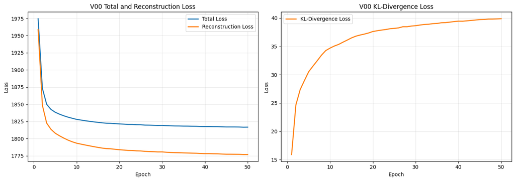

```
Training-loss figure saved to: artifacts\vae\V00\V00_training_loss_curves.png
```

```python
# Validate and display the V00 training history
required_history_columns = [
    "total_loss",
    "reconstruction_loss",
    "kl_loss"
]

missing_history_columns = [
    column
    for column in required_history_columns
    if column not in v00_history_df.columns
]

assert not missing_history_columns, (
    "Missing training-history columns: "
    f"{missing_history_columns}"
)
assert len(v00_history_df) == EPOCHS
assert np.isfinite(
    v00_history_df[
        required_history_columns
    ].to_numpy()
).all()

print(
    "V00 training-history validation passed."
)
print(
    f"Recorded epochs: "
    f"{len(v00_history_df)}"
)
print(
    "All recorded total, reconstruction, "
    "and KL losses are finite."
)

print("\nFirst-epoch losses:")
print(
    v00_history_df.loc[
        1,
        required_history_columns
    ].round(4)
)

print("\nFinal-epoch losses:")
print(
    v00_history_df.loc[
        EPOCHS,
        required_history_columns
    ].round(4)
)

print("\nLast 10 recorded epochs:")
display(
    v00_history_df[
        required_history_columns
    ].tail(10).round(4)
)

# Separate axes preserve visibility when loss
# terms have substantially different scales.
fig, axes = plt.subplots(
    nrows=1,
    ncols=2,
    figsize=(14, 5)
)

axes[0].plot(
    v00_history_df.index,
    v00_history_df["total_loss"],
    label="Total Loss",
    linewidth=2
)
axes[0].plot(
    v00_history_df.index,
    v00_history_df[
        "reconstruction_loss"
    ],
    label="Reconstruction Loss",
    linewidth=2
)
axes[0].set_title(
    "V00 Total and Reconstruction Loss"
)
axes[0].set_xlabel("Epoch")
axes[0].set_ylabel("Loss")
axes[0].grid(alpha=0.3)
axes[0].legend()

axes[1].plot(
    v00_history_df.index,
    v00_history_df["kl_loss"],
    color="tab:orange",
    label="KL-Divergence Loss",
    linewidth=2
)
axes[1].set_title(
    "V00 KL-Divergence Loss"
)
axes[1].set_xlabel("Epoch")
axes[1].set_ylabel("Loss")
axes[1].grid(alpha=0.3)
axes[1].legend()

plt.tight_layout()

training_curve_path = (
    v00_artifact_dir
    / (
        f"{EXPERIMENT_ID}_"
        "training_loss_curves.png"
    )
)

plt.savefig(
    training_curve_path,
    dpi=150,
    bbox_inches="tight"
)
plt.show()

print(
    "Training-loss figure saved to: "
    f"{training_curve_path}"
)
```

### 4.7 V00 Training Interpretation

The `V00` baseline completed all 50 epochs successfully using TensorFlow 2.10.0 and the available GPU. Training took 15.15 minutes, all recorded losses remained finite, and the five planned milestone checkpoints were saved.

| Loss term | Epoch 1 | Epoch 50 | Absolute change | Percentage change |
| --- | --- | --- | --- | --- |
| Total loss | 1974.6285 | 1816.6775 | −157.9510 | −8.00% |
| Reconstruction loss | 1958.7085 | 1776.8013 | −181.9072 | −9.29% |
| KL-divergence loss | 15.9191 | 39.8766 | +23.9575 | +150.50% |

The total and reconstruction losses decreased sharply during the early epochs and then improved more gradually. By epoch 10, the total loss had already fallen to 1827.9684, accounting for 92.85% of the complete epoch-1-to-50 reduction. The additional total-loss reductions were only 7.8516 from epochs 10 to 25, 2.6195 from epochs 25 to 40, and 0.8198 from epochs 40 to 50. This shows diminishing optimisation gains rather than instability.

The KL-divergence term increased from 15.9191 to 39.8766 instead of collapsing towards zero. This is evidence against complete posterior collapse because the encoder continued to pay a non-zero cost for deviating from the standard-normal prior. However, KL loss alone cannot prove that every latent dimension is useful or that generated images are perceptually convincing.

These curves support three limited conclusions:

1. the optimisation process was numerically stable;
2. most loss improvement occurred early, followed by a plateau; and
3. training beyond epoch 40 produced only a very small objective improvement.

A “best checkpoint” is not selected from training loss alone. There is no validation split in `V00`, and lower reconstruction loss does not automatically mean clearer or more diverse generated images. The fixed checkpoint images, reconstructions, and generations below are therefore required before deciding what to improve.

## 5. V00 Baseline Evaluation

### 5.1 Evaluation Protocol

The baseline is evaluated using three complementary views:

- **checkpoint progression:** identical reconstruction images and latent vectors are reused at epochs 1, 10, 25, 40, and 50;
- **class-balanced reconstruction:** two fixed training images per CIFAR-10 class are reconstructed using `z_mean` for deterministic comparison; and
- **unconditional generation:** the same 100 standard-normal latent vectors are decoded and compared with a stratified training reference using the shared image descriptors.

Reconstruction MSE, MAE, and PSNR measure pixel similarity. Descriptor differences measure broad colour, contrast, saturation, and edge characteristics. Neither set of numbers measures semantic recognisability, so every table is interpreted together with its image grid.

This remains a **development evaluation**. The 20 reconstruction images and stratified descriptor reference come from the official training split. The protected official test split remains unused.

### 5.2 Fixed-Input Checkpoint Progression

Each saved checkpoint is loaded into the same `V00` architecture. Reconstruction metrics are calculated on the same 20 images, while the first 10 fixed latent vectors are decoded for a direct visual progression.

For reconstruction, the decoder receives `z_mean` rather than a random latent sample. This removes sampling noise so changes across checkpoints reflect the learned weights. Lower MSE and MAE and higher PSNR indicate closer pixel reconstruction, but visual clarity remains necessary for interpretation.

```
V00 fixed-input checkpoint metrics:
```

| epoch | training_total_loss | reconstruction_mse | reconstruction_mae | reconstruction_psnr_db |
| --- | --- | --- | --- | --- |
| 1 | 1974.62854 | 0.02286 | 0.11866 | 16.709610 |
| 10 | 1827.96838 | 0.01178 | 0.08047 | 19.868601 |
| 25 | 1820.11682 | 0.01020 | 0.07416 | 20.516809 |
| 40 | 1817.49731 | 0.00963 | 0.07166 | 20.759420 |
| 50 | 1816.67749 | 0.00958 | 0.07171 | 20.768259 |

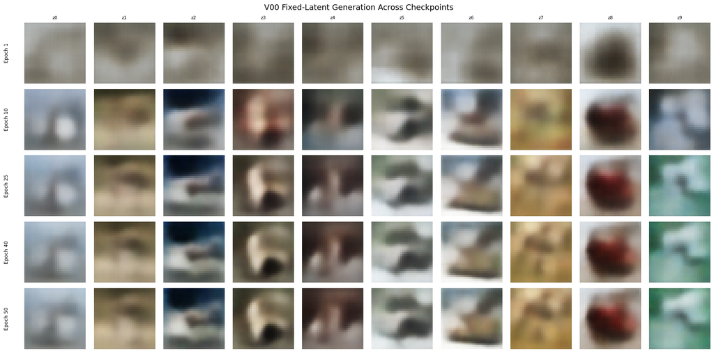

```
Checkpoint metrics saved to: artifacts\vae\V00\evaluation\V00_checkpoint_metrics.csv
Checkpoint generation grid saved to: artifacts\vae\V00\evaluation\V00_checkpoint_generation_grid.png
Official test-set usage in this evaluation: None
```

```python
# Evaluate V00 milestone checkpoints using identical inputs.
v00_artifact_dir = (
    Path("artifacts") / "vae" / "V00"
)
v00_evaluation_dir = (
    v00_artifact_dir / "evaluation"
)
v00_evaluation_dir.mkdir(
    parents=True,
    exist_ok=True
)

fixed_inputs_dir = (
    Path("artifacts")
    / "vae"
    / "fixed_inputs"
)
fixed_latent_path = (
    fixed_inputs_dir
    / f"fixed_latent_vectors_dim{LATENT_DIM}.npy"
)
fixed_indices_path = (
    fixed_inputs_dir
    / "fixed_reconstruction_indices.npy"
)
history_path = (
    v00_artifact_dir
    / "V00_training_history.csv"
)
final_vae_weights_path = (
    v00_artifact_dir
    / "weights"
    / "V00_vae_final.weights.h5"
)

required_evaluation_paths = [
    fixed_latent_path,
    fixed_indices_path,
    history_path,
    final_vae_weights_path
]

for required_path in required_evaluation_paths:
    assert required_path.exists(), (
        f"Required V00 artefact not found: "
        f"{required_path}"
    )

fixed_latent_vectors = np.load(
    fixed_latent_path
)
fixed_reconstruction_indices = np.load(
    fixed_indices_path
)

fixed_reconstruction_images = x_train_vae[
    fixed_reconstruction_indices
]
fixed_reconstruction_labels = y_train[
    fixed_reconstruction_indices
]

assert fixed_latent_vectors.shape == (
    100,
    LATENT_DIM
)
assert fixed_reconstruction_images.shape == (
    20,
    32,
    32,
    3
)
checkpoint_epochs = [1, 10, 25, 40, 50]
history_for_evaluation = pd.read_csv(
    history_path,
    index_col="epoch"
)

checkpoint_records = []
checkpoint_generated_samples = {}

for checkpoint_epoch in checkpoint_epochs:
    checkpoint_path = (
        v00_artifact_dir
        / "checkpoints"
        / (
            "V00_epoch_"
            f"{checkpoint_epoch:03d}"
            ".weights.h5"
        )
    )

    assert checkpoint_path.exists(), (
        f"Checkpoint not found: "
        f"{checkpoint_path}"
    )

    vae_v00.load_weights(
        str(checkpoint_path)
    )

    (
        checkpoint_z_mean,
        _,
        _
    ) = encoder.predict(
        fixed_reconstruction_images,
        verbose=0
    )

    checkpoint_reconstructions = (
        decoder.predict(
            checkpoint_z_mean,
            verbose=0
        )
    )
    checkpoint_reconstructions = np.clip(
        checkpoint_reconstructions,
        0.0,
        1.0
    )

    mse_per_image = np.mean(
        np.square(
            fixed_reconstruction_images
            - checkpoint_reconstructions
        ),
        axis=(1, 2, 3)
    )
    mae_per_image = np.mean(
        np.abs(
            fixed_reconstruction_images
            - checkpoint_reconstructions
        ),
        axis=(1, 2, 3)
    )
    psnr_per_image = tf.image.psnr(
        fixed_reconstruction_images,
        checkpoint_reconstructions,
        max_val=1.0
    ).numpy()

    checkpoint_generated = decoder.predict(
        fixed_latent_vectors[:10],
        verbose=0
    )
    checkpoint_generated = np.clip(
        checkpoint_generated,
        0.0,
        1.0
    )

    checkpoint_generated_samples[
        checkpoint_epoch
    ] = checkpoint_generated

    checkpoint_records.append({
        "epoch": checkpoint_epoch,
        "training_total_loss": (
            history_for_evaluation.loc[
                checkpoint_epoch,
                "total_loss"
            ]
        ),
        "reconstruction_mse": (
            mse_per_image.mean()
        ),
        "reconstruction_mae": (
            mae_per_image.mean()
        ),
        "reconstruction_psnr_db": (
            psnr_per_image.mean()
        )
    })

# Restore the final exported weights after the loop.
vae_v00.load_weights(
    str(final_vae_weights_path)
)

checkpoint_metrics_df = pd.DataFrame(
    checkpoint_records
).set_index("epoch")

checkpoint_metrics_path = (
    v00_evaluation_dir
    / "V00_checkpoint_metrics.csv"
)
checkpoint_metrics_df.to_csv(
    checkpoint_metrics_path
)

print(
    "V00 fixed-input checkpoint metrics:"
)
display(
    checkpoint_metrics_df.round(5)
)

fig, axes = plt.subplots(
    nrows=len(checkpoint_epochs),
    ncols=10,
    figsize=(18, 9)
)

for row_index, checkpoint_epoch in enumerate(
    checkpoint_epochs
):
    checkpoint_images = (
        checkpoint_generated_samples[
            checkpoint_epoch
        ]
    )

    for column_index in range(10):
        axes[
            row_index,
            column_index
        ].imshow(
            checkpoint_images[column_index]
        )
        axes[
            row_index,
            column_index
        ].axis("off")

        if row_index == 0:
            axes[
                row_index,
                column_index
            ].set_title(
                f"z{column_index}",
                fontsize=8
            )

    axes[row_index, 0].text(
        -0.25,
        0.5,
        f"Epoch {checkpoint_epoch}",
        transform=axes[
            row_index,
            0
        ].transAxes,
        rotation=90,
        va="center",
        ha="right",
        fontsize=9
    )

fig.suptitle(
    "V00 Fixed-Latent Generation Across Checkpoints",
    fontsize=14
)
plt.tight_layout()

checkpoint_grid_path = (
    v00_evaluation_dir
    / "V00_checkpoint_generation_grid.png"
)
plt.savefig(
    checkpoint_grid_path,
    dpi=150,
    bbox_inches="tight"
)
plt.show()

print(
    "Checkpoint metrics saved to: "
    f"{checkpoint_metrics_path}"
)
print(
    "Checkpoint generation grid saved to: "
    f"{checkpoint_grid_path}"
)
print(
    "Official test-set usage in this evaluation: "
    "None"
)
```

### 5.3 Class-Balanced Reconstruction Diagnostics

The final V00 weights are now evaluated on the 20 fixed reconstruction images. The four-row grid places each original image immediately above its deterministic reconstruction.

The class table contains only two images per class. It is useful for identifying possible failure patterns, but it is too small to establish a final easier-versus-harder class ranking. Any class conclusion must therefore be phrased as a fixed-sample observation and checked against the images.

```
Overall fixed-sample reconstruction metrics:
MSE: 0.00958
MAE: 0.07171
PSNR: 20.768 dB

Mean reconstruction metrics by class (two fixed images per class):
```

| class_name | mse | mae | psnr_db |
| --- | --- | --- | --- |
| Airplane | 0.01183 | 0.07276 | 21.893160 |
| Automobile | 0.00947 | 0.06936 | 20.605980 |
| Bird | 0.00791 | 0.06362 | 21.168400 |
| Cat | 0.01039 | 0.07810 | 19.862690 |
| Deer | 0.01249 | 0.08329 | 19.452120 |
| Dog | 0.00950 | 0.07512 | 20.251551 |
| Frog | 0.01038 | 0.08041 | 19.903780 |
| Horse | 0.01101 | 0.08007 | 19.698420 |
| Ship | 0.00493 | 0.04847 | 23.697710 |
| Truck | 0.00793 | 0.06586 | 21.148790 |

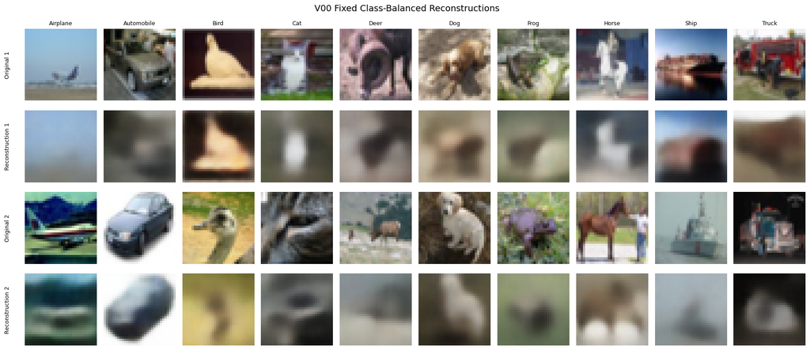

```
Reconstruction metrics saved to: artifacts\vae\V00\evaluation\V00_reconstruction_metrics.csv
Reconstruction grid saved to: artifacts\vae\V00\evaluation\V00_reconstruction_grid.png
```

```python
# Evaluate final V00 deterministic reconstructions.
vae_v00.load_weights(
    str(final_vae_weights_path)
)

(
    final_z_mean,
    final_z_log_var,
    _
) = encoder.predict(
    fixed_reconstruction_images,
    verbose=0
)

final_reconstructions = decoder.predict(
    final_z_mean,
    verbose=0
)
final_reconstructions = np.clip(
    final_reconstructions,
    0.0,
    1.0
)

final_mse_per_image = np.mean(
    np.square(
        fixed_reconstruction_images
        - final_reconstructions
    ),
    axis=(1, 2, 3)
)
final_mae_per_image = np.mean(
    np.abs(
        fixed_reconstruction_images
        - final_reconstructions
    ),
    axis=(1, 2, 3)
)
final_psnr_per_image = tf.image.psnr(
    fixed_reconstruction_images,
    final_reconstructions,
    max_val=1.0
).numpy()

reconstruction_records = []

for position in range(
    len(fixed_reconstruction_indices)
):
    class_id = int(
        fixed_reconstruction_labels[position]
    )

    reconstruction_records.append({
        "dataset_index": int(
            fixed_reconstruction_indices[
                position
            ]
        ),
        "class_id": class_id,
        "class_name": (
            class_names[class_id]
        ),
        "sample_within_class": (
            position % IMAGES_PER_CLASS
        ) + 1,
        "mse": (
            final_mse_per_image[position]
        ),
        "mae": (
            final_mae_per_image[position]
        ),
        "psnr_db": (
            final_psnr_per_image[position]
        )
    })

reconstruction_metrics_df = pd.DataFrame(
    reconstruction_records
)
reconstruction_metrics_df[
    "class_name"
] = pd.Categorical(
    reconstruction_metrics_df[
        "class_name"
    ],
    categories=class_names,
    ordered=True
)

class_reconstruction_summary = (
    reconstruction_metrics_df
    .groupby(
        "class_name",
        observed=False
    )[["mse", "mae", "psnr_db"]]
    .mean()
)

reconstruction_metrics_path = (
    v00_evaluation_dir
    / "V00_reconstruction_metrics.csv"
)
reconstruction_metrics_df.to_csv(
    reconstruction_metrics_path,
    index=False
)

print(
    "Overall fixed-sample reconstruction "
    "metrics:"
)
print(
    "MSE: "
    f"{final_mse_per_image.mean():.5f}"
)
print(
    "MAE: "
    f"{final_mae_per_image.mean():.5f}"
)
print(
    "PSNR: "
    f"{final_psnr_per_image.mean():.3f} dB"
)

print(
    "\nMean reconstruction metrics by class "
    "(two fixed images per class):"
)
display(
    class_reconstruction_summary.round(5)
)

fig, axes = plt.subplots(
    nrows=4,
    ncols=len(class_names),
    figsize=(18, 8)
)

row_labels = [
    "Original 1",
    "Reconstruction 1",
    "Original 2",
    "Reconstruction 2"
]

for class_id, class_name in enumerate(
    class_names
):
    first_position = (
        class_id * IMAGES_PER_CLASS
    )
    second_position = (
        first_position + 1
    )

    image_sequence = [
        fixed_reconstruction_images[
            first_position
        ],
        final_reconstructions[
            first_position
        ],
        fixed_reconstruction_images[
            second_position
        ],
        final_reconstructions[
            second_position
        ]
    ]

    for row_index, image_value in enumerate(
        image_sequence
    ):
        axes[
            row_index,
            class_id
        ].imshow(image_value)
        axes[
            row_index,
            class_id
        ].axis("off")

        if class_id == 0:
            axes[
                row_index,
                class_id
            ].text(
                -0.2,
                0.5,
                row_labels[row_index],
                transform=axes[
                    row_index,
                    class_id
                ].transAxes,
                rotation=90,
                va="center",
                ha="right",
                fontsize=9
            )

    axes[0, class_id].set_title(
        class_name,
        fontsize=9
    )

fig.suptitle(
    "V00 Fixed Class-Balanced Reconstructions",
    fontsize=14
)
plt.tight_layout()

reconstruction_grid_path = (
    v00_evaluation_dir
    / "V00_reconstruction_grid.png"
)
plt.savefig(
    reconstruction_grid_path,
    dpi=150,
    bbox_inches="tight"
)
plt.show()

print(
    "Reconstruction metrics saved to: "
    f"{reconstruction_metrics_path}"
)
print(
    "Reconstruction grid saved to: "
    f"{reconstruction_grid_path}"
)
```

### 5.4 Unconditional Generation Diagnostics

The final decoder generates 100 images from the fixed latent vectors. The numbered 10×10 grid is the primary evidence for clarity, recognisability, variety, colour, and repeated failure patterns.

Because `V00` is unconditional, a latent vector cannot request a named class. Class controllability will require a later conditional VAE design rather than being claimed from this grid.

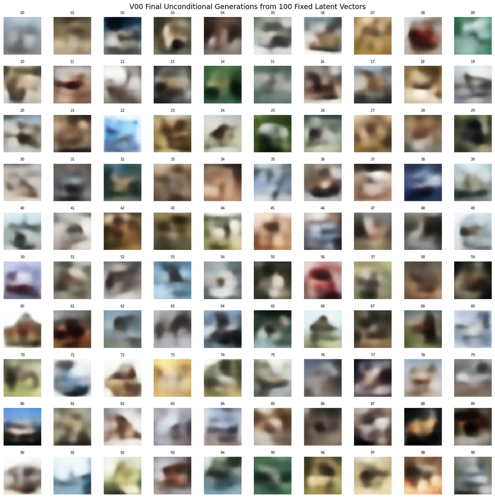

```
V00 generated image validation passed.
Generated tensor shape: (100, 32, 32, 3)
Generated float range: 0.0133 to 0.9998
Unique uint8 images: 100 / 100
Mean per-pixel standard deviation across generated images: 0.21217
Mean per-pixel standard deviation across the training reference: 0.24984

Descriptor comparison (training reference versus V00):
```

| descriptor | training_mean | generated_mean | absolute_difference | relative_difference_percent | training_std | generated_std |
| --- | --- | --- | --- | --- | --- | --- |
| brightness | 0.47306 | 0.48968 | 0.01663 | 3.51539 | 0.12557 | 0.12656 |
| contrast | 0.21314 | 0.17314 | 0.04000 | 18.76902 | 0.05623 | 0.03964 |
| red_mean | 0.48984 | 0.51383 | 0.02398 | 4.89580 | 0.12799 | 0.13001 |
| green_mean | 0.48294 | 0.49827 | 0.01534 | 3.17589 | 0.12709 | 0.12690 |
| blue_mean | 0.44639 | 0.45696 | 0.01057 | 2.36783 | 0.15029 | 0.14557 |
| saturation | 0.12971 | 0.10944 | 0.02028 | 15.63146 | 0.07695 | 0.06218 |
| edge_strength | 0.05800 | 0.02476 | 0.03324 | 57.30472 | 0.01747 | 0.00547 |

```
Generated samples saved to: artifacts\vae\V00\evaluation\V00_fixed_generated_samples.npy
Generation grid saved to: artifacts\vae\V00\evaluation\V00_final_generation_grid.png
Descriptor comparison saved to: artifacts\vae\V00\evaluation\V00_descriptor_comparison.csv
Official test-set usage in this evaluation: None
```

```python
# Generate the final fixed-latent V00 sample set.
vae_v00.load_weights(
    str(final_vae_weights_path)
)

v00_generated_float = decoder.predict(
    fixed_latent_vectors,
    verbose=0
)
v00_generated_float = np.clip(
    v00_generated_float,
    0.0,
    1.0
)

assert v00_generated_float.shape == (
    100,
    32,
    32,
    3
)
assert np.isfinite(
    v00_generated_float
).all()
assert v00_generated_float.min() >= 0.0
assert v00_generated_float.max() <= 1.0

v00_generated_uint8 = np.rint(
    v00_generated_float * 255.0
).astype(np.uint8)

generated_samples_path = (
    v00_evaluation_dir
    / "V00_fixed_generated_samples.npy"
)
np.save(
    generated_samples_path,
    v00_generated_uint8
)

fig, axes = plt.subplots(
    nrows=10,
    ncols=10,
    figsize=(14, 14)
)

for sample_index, axis in enumerate(
    axes.flat
):
    axis.imshow(
        v00_generated_float[
            sample_index
        ]
    )
    axis.set_title(
        f"{sample_index:02d}",
        fontsize=7
    )
    axis.axis("off")

fig.suptitle(
    "V00 Final Unconditional Generations "
    "from 100 Fixed Latent Vectors",
    fontsize=14
)
plt.tight_layout()

generation_grid_path = (
    v00_evaluation_dir
    / "V00_final_generation_grid.png"
)
plt.savefig(
    generation_grid_path,
    dpi=150,
    bbox_inches="tight"
)
plt.show()

# Use a deterministic, class-balanced training
# reference for the shared image descriptors.
descriptor_rng = np.random.default_rng(
    SEED + 100
)
descriptor_reference_indices = []

for class_id in range(
    len(class_names)
):
    class_indices = np.where(
        y_train == class_id
    )[0]

    selected_indices = (
        descriptor_rng.choice(
            class_indices,
            size=100,
            replace=False
        )
    )
    descriptor_reference_indices.extend(
        selected_indices
    )

descriptor_reference_indices = np.array(
    descriptor_reference_indices,
    dtype=np.int64
)
descriptor_reference_images = x_train_vae[
    descriptor_reference_indices
]


def calculate_image_descriptors(
    image_batch
):
    """Calculates the shared EDA image descriptors."""

    image_batch = image_batch.astype(
        np.float32
    )

    brightness = image_batch.mean(
        axis=(1, 2, 3)
    )
    contrast = image_batch.std(
        axis=(1, 2, 3)
    )
    red_mean = image_batch[
        :, :, :, 0
    ].mean(axis=(1, 2))
    green_mean = image_batch[
        :, :, :, 1
    ].mean(axis=(1, 2))
    blue_mean = image_batch[
        :, :, :, 2
    ].mean(axis=(1, 2))
    saturation = (
        image_batch.max(axis=3)
        - image_batch.min(axis=3)
    ).mean(axis=(1, 2))

    horizontal_difference = np.abs(
        np.diff(
            image_batch,
            axis=2
        )
    ).mean(axis=(1, 2, 3))
    vertical_difference = np.abs(
        np.diff(
            image_batch,
            axis=1
        )
    ).mean(axis=(1, 2, 3))
    edge_strength = (
        horizontal_difference
        + vertical_difference
    ) / 2.0

    return pd.DataFrame({
        "brightness": brightness,
        "contrast": contrast,
        "red_mean": red_mean,
        "green_mean": green_mean,
        "blue_mean": blue_mean,
        "saturation": saturation,
        "edge_strength": edge_strength
    })


reference_descriptors = (
    calculate_image_descriptors(
        descriptor_reference_images
    )
)
generated_descriptors = (
    calculate_image_descriptors(
        v00_generated_float
    )
)

descriptor_records = []

for descriptor_name in (
    reference_descriptors.columns
):
    reference_mean = (
        reference_descriptors[
            descriptor_name
        ].mean()
    )
    generated_mean = (
        generated_descriptors[
            descriptor_name
        ].mean()
    )

    descriptor_records.append({
        "descriptor": descriptor_name,
        "training_mean": reference_mean,
        "generated_mean": generated_mean,
        "absolute_difference": abs(
            generated_mean
            - reference_mean
        ),
        "relative_difference_percent": (
            abs(
                generated_mean
                - reference_mean
            )
            / abs(reference_mean)
            * 100.0
        ),
        "training_std": (
            reference_descriptors[
                descriptor_name
            ].std()
        ),
        "generated_std": (
            generated_descriptors[
                descriptor_name
            ].std()
        )
    })

descriptor_comparison_df = pd.DataFrame(
    descriptor_records
).set_index("descriptor")

descriptor_comparison_path = (
    v00_evaluation_dir
    / "V00_descriptor_comparison.csv"
)
descriptor_comparison_df.to_csv(
    descriptor_comparison_path
)

generated_unique_count = len(
    np.unique(
        v00_generated_uint8.reshape(
            len(v00_generated_uint8),
            -1
        ),
        axis=0
    )
)
generated_pixel_diversity = np.mean(
    np.std(
        v00_generated_float,
        axis=0
    )
)
reference_pixel_diversity = np.mean(
    np.std(
        descriptor_reference_images,
        axis=0
    )
)

print(
    "V00 generated image validation passed."
)
print(
    "Generated tensor shape: "
    f"{v00_generated_float.shape}"
)
print(
    "Generated float range: "
    f"{v00_generated_float.min():.4f} "
    f"to {v00_generated_float.max():.4f}"
)
print(
    "Unique uint8 images: "
    f"{generated_unique_count} / "
    f"{len(v00_generated_uint8)}"
)
print(
    "Mean per-pixel standard deviation "
    "across generated images: "
    f"{generated_pixel_diversity:.5f}"
)
print(
    "Mean per-pixel standard deviation "
    "across the training reference: "
    f"{reference_pixel_diversity:.5f}"
)

print(
    "\nDescriptor comparison "
    "(training reference versus V00):"
)
display(
    descriptor_comparison_df.round(5)
)

print(
    "Generated samples saved to: "
    f"{generated_samples_path}"
)
print(
    "Generation grid saved to: "
    f"{generation_grid_path}"
)
print(
    "Descriptor comparison saved to: "
    f"{descriptor_comparison_path}"
)
print(
    "Official test-set usage in this evaluation: "
    "None"
)
```

### 5.5 Evidence-Based V00 Evaluation

#### Checkpoint Progression

V00 changed most visibly between epochs 1 and 10. Epoch 1 produced mainly average-colour blobs, whereas epoch 10 established coarse foreground-background layouts and recognisable colour regions. Later checkpoints refined those layouts but did not remove the characteristic blur.

The fixed reconstruction metrics show the same diminishing return:

| Epoch | MSE ↓ | MAE ↓ | PSNR ↑ |
| --- | --- | --- | --- |
| 1 | 0.02286 | 0.11866 | 16.710 dB |
| 10 | 0.01178 | 0.08047 | 19.869 dB |
| 25 | 0.01020 | 0.07416 | 20.517 dB |
| 40 | 0.00963 | 0.07166 | 20.759 dB |
| 50 | 0.00958 | 0.07171 | 20.768 dB |

From epoch 40 to 50, MSE improved by only 0.00005 and PSNR by 0.009 dB, while MAE became marginally higher. The epoch-40 and epoch-50 fixed-latent rows are also visually almost identical. Therefore, V00 converged to a stable but over-smoothed solution; simply extending the same training is unlikely to solve the main quality problem.

#### Reconstruction Quality and Class Observations

The final fixed-sample reconstruction result was MSE 0.00958, MAE 0.07171, and PSNR 20.768 dB. Reconstructions generally preserved dominant colour, approximate object position, and broad background layout. Fine boundaries, textures, limbs, and small foreground details were lost.

The ship samples achieved the best class-average metrics (MSE 0.00493 and PSNR 23.698 dB), while deer had the largest class-average MSE (0.01249) and lowest PSNR (19.452 dB). Cat, frog, and horse also had comparatively low PSNR values between 19.698 and 19.903 dB. This fixed sample suggests that smooth scenes and large high-contrast layouts are easier to reconstruct than texture-rich animals and cluttered backgrounds.

The grid also exposes why pixel metrics cannot be treated as semantic scores. Airplane sample 1 obtained the lowest individual MSE, 0.00192, even though the small aeroplane almost disappeared and the decoder mainly reproduced the large blue-grey background. Conversely, a visually important small-object error can contribute little to an image-wide average. Easier-versus-harder class claims are therefore provisional because only two fixed images represent each class.

#### Unconditional Generation Quality

All 100 generated arrays were unique, and the grid contains varied colours, backgrounds, and coarse silhouettes. This argues against exact duplication or complete mode collapse. However, uniqueness does not equal semantic diversity: many outputs are ambiguous blends rather than reliably identifiable CIFAR-10 objects.

Compared with the 1,000-image stratified training reference, V00 generations had:

- 18.77% lower contrast;
- 15.63% lower saturation;
- 57.30% lower edge strength; and
- lower mean pixel diversity, 0.21217 versus 0.24984.

Brightness and RGB channel means differed by only 2.37% to 4.90%, showing that V00 learned the broad colour distribution more successfully than local structure. The severe edge-strength gap matches the visibly soft boundaries and missing texture.

V00 does generate in colour, so the model has learned more than a grayscale intensity distribution. A grayscale task would probably be easier because it removes channel-to-channel colour variation, but that remains a reasoned hypothesis rather than an experiment in this notebook.

#### Requested-Class Limitation

V00 is unconditional. A standard-normal latent vector can produce an image, but it cannot request “frog”, “truck”, or another named class. The 100-image grid cannot demonstrate requested-class generation because labels never enter the encoder or decoder. A later conditional VAE branch must explicitly incorporate class information.

#### Baseline Limitations

This development evaluation uses only 20 fixed reconstructions and 100 fixed generations. The descriptor table measures low-level image statistics, not recognisability. Blind manual scoring, broader class-coverage evidence, development FID, nearest-neighbour memorisation checks, and the protected test evaluation remain outside this checkpoint.

### 5.6 Three-Architecture Baseline Screen

The completed `V00` model is the **ConvTranspose VAE baseline candidate**. Its architecture, training run, saved outputs, and evaluation remain unchanged.

Two additional unconditional candidates are now added so that architecture selection occurs before the controlled improvement sequence:

| Screen ID | Architecture | Main architectural question |
| --- | --- | --- |
| `B01_DENSE` | Dense VAE | Can fully connected layers model CIFAR-10 without an explicit spatial inductive bias? |
| `B02_CONVTRANSPOSE` | Existing `V00` | Does the current convolutional encoder and learned transposed-convolution decoder provide the strongest foundation? |
| `B03_UPSAMPLING` | Upsampling VAE | Does deterministic upsampling followed by ordinary convolution improve the decoder foundation? |

`B02_CONVTRANSPOSE` maps directly to the already completed `V00` run. It is **not retrained**. The new code trains only `B01_DENSE` and `B03_UPSAMPLING`.

This screen follows the same principle used in the GAN notebook: compare credible architecture foundations under aligned conditions, select one foundation using multiple forms of evidence, and only then interpret later experiments as improvements to the selected baseline.

#### 5.6.1 Locked Conditions and Fairness Controls

The three candidates share the conditions that affect the VAE objective and training budget:

| Setting | Locked value |
| --- | --- |
| Training data | All 50,000 official CIFAR-10 training images |
| Test data | Protected and unused |
| Image representation | RGB `float32 [0,1]` |
| Latent dimension | 64 |
| Reconstruction term | Binary cross-entropy summed across pixels and channels |
| KL weight | `1.0` |
| Optimiser | Adam |
| Learning rate | `0.001` |
| Batch size | 128 |
| Epoch budget | 50 |
| Seed | 42 |
| Augmentation | None |
| Conditioning | None |
| Milestone epochs | 1, 10, 25, 40 and 50 |

Exact parameter matching is not required because the purpose is to compare credible architecture types. Parameter counts and training time are retained as efficiency evidence.

The code below defines a screen-specific sampling layer and training class using the **same reconstruction and KL calculations as V00**. Separate class names prevent the new candidates from altering any existing V00 object or result.

```python
# Shared settings for the two new architecture candidates.
BASELINE_SCREEN_INPUT_SHAPE = (32, 32, 3)
BASELINE_SCREEN_LATENT_DIM = 64
BASELINE_SCREEN_BETA = 1.0
BASELINE_SCREEN_LEARNING_RATE = 0.001
BASELINE_SCREEN_BATCH_SIZE = 128
BASELINE_SCREEN_EPOCHS = 50
BASELINE_SCREEN_MILESTONES = [
    1,
    10,
    25,
    40,
    50
]


class ArchitectureScreenSampling(
    layers.Layer
):
    """VAE reparameterisation used by both new baselines."""

    def call(self, inputs):
        z_mean, z_log_var = inputs

        batch_size = tf.shape(z_mean)[0]
        latent_dimension = tf.shape(
            z_mean
        )[1]

        epsilon = tf.random.normal(
            shape=(
                batch_size,
                latent_dimension
            )
        )

        return (
            z_mean
            + tf.exp(0.5 * z_log_var)
            * epsilon
        )


class ArchitectureScreenVAE(
    keras.Model
):
    """
    VAE training class matched to V00.

    Total, reconstruction and KL losses are
    retained separately for fair comparison.
    """

    def __init__(
        self,
        encoder,
        decoder,
        beta=1.0,
        **kwargs
    ):
        super().__init__(**kwargs)

        self.encoder = encoder
        self.decoder = decoder
        self.beta = beta

        self.total_loss_tracker = (
            keras.metrics.Mean(
                name="total_loss"
            )
        )
        self.reconstruction_loss_tracker = (
            keras.metrics.Mean(
                name="reconstruction_loss"
            )
        )
        self.kl_loss_tracker = (
            keras.metrics.Mean(
                name="kl_loss"
            )
        )

    @property
    def metrics(self):
        return [
            self.total_loss_tracker,
            self.reconstruction_loss_tracker,
            self.kl_loss_tracker
        ]

    def call(
        self,
        inputs,
        training=False
    ):
        _, _, z = self.encoder(
            inputs,
            training=training
        )
        return self.decoder(
            z,
            training=training
        )

    def train_step(self, data):
        if isinstance(data, tuple):
            data = data[0]

        with tf.GradientTape() as tape:
            (
                z_mean,
                z_log_var,
                z
            ) = self.encoder(
                data,
                training=True
            )

            reconstruction = self.decoder(
                z,
                training=True
            )

            reconstruction_per_element = (
                keras.backend
                .binary_crossentropy(
                    data,
                    reconstruction
                )
            )

            reconstruction_loss = (
                tf.reduce_mean(
                    tf.reduce_sum(
                        reconstruction_per_element,
                        axis=(1, 2, 3)
                    )
                )
            )

            kl_loss = (
                -0.5
                * tf.reduce_mean(
                    tf.reduce_sum(
                        (
                            1
                            + z_log_var
                            - tf.square(
                                z_mean
                            )
                            - tf.exp(
                                z_log_var
                            )
                        ),
                        axis=1
                    )
                )
            )

            total_loss = (
                reconstruction_loss
                + self.beta * kl_loss
            )

        gradients = tape.gradient(
            total_loss,
            self.trainable_weights
        )

        self.optimizer.apply_gradients(
            zip(
                gradients,
                self.trainable_weights
            )
        )

        self.total_loss_tracker.update_state(
            total_loss
        )
        (
            self
            .reconstruction_loss_tracker
            .update_state(
                reconstruction_loss
            )
        )
        self.kl_loss_tracker.update_state(
            kl_loss
        )

        return {
            "loss": (
                self
                .total_loss_tracker
                .result()
            ),
            "total_loss": (
                self
                .total_loss_tracker
                .result()
            ),
            "reconstruction_loss": (
                self
                .reconstruction_loss_tracker
                .result()
            ),
            "kl_loss": (
                self
                .kl_loss_tracker
                .result()
            )
        }


assert x_train_vae.shape == (
    50000,
    32,
    32,
    3
)
assert x_train_vae.dtype == np.float32
assert np.isfinite(x_train_vae).all()
assert (
    0.0
    <= x_train_vae.min()
    <= x_train_vae.max()
    <= 1.0
)

print("Architecture-screen implementation prepared.")
print(
    "The objective matches V00: "
    "BCE reconstruction + beta-weighted KL."
)
print("Official test-set usage: None")
```

```
Architecture-screen implementation prepared.
The objective matches V00: BCE reconstruction + beta-weighted KL.
Official test-set usage: None
```

#### 5.6.2 B01 Dense VAE

##### Question

Can a fully connected VAE learn useful CIFAR-10 reconstruction and generation without convolutional spatial modelling?

##### Rationale

The Dense VAE flattens every `32 × 32 × 3` image into 3,072 values. Its encoder and decoder can learn global pixel relationships, but they do not explicitly preserve local neighbourhoods or reuse spatial filters across image locations.

This is a serious baseline rather than an intentionally broken model. Two hidden layers are used on each side of the latent bottleneck, while the probabilistic latent representation, loss function and training conditions remain aligned with V00.

##### Hypothesis

The model may reproduce broad colour and intensity patterns, but it is expected to struggle with local object geometry and spatially coherent generation. This remains a hypothesis until the model is trained and evaluated.

```python
# Build B01: Dense VAE.
DENSE_BASELINE_ID = "B01_DENSE"

tf.keras.utils.set_random_seed(SEED)

dense_encoder_inputs = keras.Input(
    shape=BASELINE_SCREEN_INPUT_SHAPE,
    name="B01_dense_encoder_input"
)

dense_x = layers.Flatten(
    name="B01_dense_flatten"
)(dense_encoder_inputs)

dense_x = layers.Dense(
    256,
    activation="relu",
    name="B01_dense_encoder_hidden_1"
)(dense_x)

dense_x = layers.Dense(
    128,
    activation="relu",
    name="B01_dense_encoder_hidden_2"
)(dense_x)

dense_z_mean = layers.Dense(
    BASELINE_SCREEN_LATENT_DIM,
    name="B01_dense_z_mean"
)(dense_x)

dense_z_log_var = layers.Dense(
    BASELINE_SCREEN_LATENT_DIM,
    name="B01_dense_z_log_var"
)(dense_x)

dense_z = ArchitectureScreenSampling(
    name="B01_dense_sampling"
)([
    dense_z_mean,
    dense_z_log_var
])

dense_baseline_encoder = keras.Model(
    dense_encoder_inputs,
    [
        dense_z_mean,
        dense_z_log_var,
        dense_z
    ],
    name="B01_dense_encoder"
)

dense_decoder_inputs = keras.Input(
    shape=(BASELINE_SCREEN_LATENT_DIM,),
    name="B01_dense_decoder_input"
)

dense_y = layers.Dense(
    128,
    activation="relu",
    name="B01_dense_decoder_hidden_1"
)(dense_decoder_inputs)

dense_y = layers.Dense(
    256,
    activation="relu",
    name="B01_dense_decoder_hidden_2"
)(dense_y)

dense_y = layers.Dense(
    int(np.prod(
        BASELINE_SCREEN_INPUT_SHAPE
    )),
    activation="sigmoid",
    name="B01_dense_decoder_pixels"
)(dense_y)

dense_decoder_outputs = layers.Reshape(
    BASELINE_SCREEN_INPUT_SHAPE,
    name="B01_dense_decoder_output"
)(dense_y)

dense_baseline_decoder = keras.Model(
    dense_decoder_inputs,
    dense_decoder_outputs,
    name="B01_dense_decoder"
)

dense_baseline_vae = ArchitectureScreenVAE(
    encoder=dense_baseline_encoder,
    decoder=dense_baseline_decoder,
    beta=BASELINE_SCREEN_BETA,
    name="B01_dense_vae"
)

dense_baseline_vae.compile(
    optimizer=keras.optimizers.Adam(
        learning_rate=(
            BASELINE_SCREEN_LEARNING_RATE
        )
    )
)

dense_test_output = dense_baseline_vae(
    tf.zeros(
        shape=(
            2,
        ) + BASELINE_SCREEN_INPUT_SHAPE,
        dtype=tf.float32
    ),
    training=False
)

assert dense_test_output.shape == (
    2,
    32,
    32,
    3
)
assert np.isfinite(
    dense_test_output.numpy()
).all()
assert (
    tf.reduce_min(
        dense_test_output
    ).numpy()
    >= 0.0
)
assert (
    tf.reduce_max(
        dense_test_output
    ).numpy()
    <= 1.0
)

dense_encoder_parameters = (
    dense_baseline_encoder.count_params()
)
dense_decoder_parameters = (
    dense_baseline_decoder.count_params()
)
dense_total_parameters = (
    dense_encoder_parameters
    + dense_decoder_parameters
)

print(f"Experiment ID: {DENSE_BASELINE_ID}")
print(
    "Dense encoder parameters: "
    f"{dense_encoder_parameters:,}"
)
print(
    "Dense decoder parameters: "
    f"{dense_decoder_parameters:,}"
)
print(
    "Dense total parameters: "
    f"{dense_total_parameters:,}"
)
print(
    "Dense output validation passed: "
    f"{dense_test_output.shape}"
)
print("Official test-set usage: None")

dense_baseline_encoder.summary()
dense_baseline_decoder.summary()
```

```
Experiment ID: B01_DENSE
Dense encoder parameters: 836,096
Dense decoder parameters: 830,848
Dense total parameters: 1,666,944
Dense output validation passed: (2, 32, 32, 3)
Official test-set usage: None
Model: "B01_dense_encoder"
__________________________________________________________________________________________________
 Layer (type)                   Output Shape         Param #     Connected to
==================================================================================================
 B01_dense_encoder_input (Input  [(None, 32, 32, 3)]  0          []
 Layer)

 B01_dense_flatten (Flatten)    (None, 3072)         0           ['B01_dense_encoder_input[0][0]']

 B01_dense_encoder_hidden_1 (De  (None, 256)         786688      ['B01_dense_flatten[0][0]']
 nse)

 B01_dense_encoder_hidden_2 (De  (None, 128)         32896       ['B01_dense_encoder_hidden_1[0][0
 nse)                                                            ]']

 B01_dense_z_mean (Dense)       (None, 64)           8256        ['B01_dense_encoder_hidden_2[0][0
                                                                 ]']

 B01_dense_z_log_var (Dense)    (None, 64)           8256        ['B01_dense_encoder_hidden_2[0][0
                                                                 ]']

 B01_dense_sampling (Architectu  (None, 64)          0           ['B01_dense_z_mean[0][0]',
 reScreenSampling)                                                'B01_dense_z_log_var[0][0]']

==================================================================================================
Total params: 836,096
Trainable params: 836,096
Non-trainable params: 0
__________________________________________________________________________________________________
Model: "B01_dense_decoder"
_________________________________________________________________
 Layer (type)                Output Shape              Param #
=================================================================
 B01_dense_decoder_input (In  [(None, 64)]             0
 putLayer)

 B01_dense_decoder_hidden_1   (None, 128)              8320
 (Dense)

 B01_dense_decoder_hidden_2   (None, 256)              33024
 (Dense)

 B01_dense_decoder_pixels (D  (None, 3072)             789504
 ense)

 B01_dense_decoder_output (R  (None, 32, 32, 3)        0
 eshape)

=================================================================
Total params: 830,848
Trainable params: 830,848
Non-trainable params: 0
_________________________________________________________________
```

#### 5.6.3 B03 Upsampling VAE

##### Question

Does replacing learned transposed-convolution upscaling with `UpSampling2D + Conv2D` provide a stronger VAE decoder foundation?

##### Rationale

Lab 5 explicitly suggests trying `UpSampling2D` as an alternative to `Conv2DTranspose` [3]. The encoder is therefore matched to V00, while the decoder changes only its spatial expansion method:

```
4 × 4 feature map
→ nearest-neighbour upsampling
→ ordinary convolution
→ repeat until 32 × 32
```

`UpSampling2D` performs deterministic resizing and has no trainable weights. The following convolution learns how to refine the enlarged feature map. This separation may reduce transposed-convolution artifacts, although it may also produce smoother outputs or require different capacity.

##### Hypothesis

The Upsampling VAE may produce more spatially even reconstructions and generations than V00, but it may lose some learned upscaling flexibility. The result must be determined from matched training and evaluation evidence.

```python
# Build B03: Upsampling VAE.
UPSAMPLING_BASELINE_ID = "B03_UPSAMPLING"

tf.keras.utils.set_random_seed(SEED)

upsampling_encoder_inputs = keras.Input(
    shape=BASELINE_SCREEN_INPUT_SHAPE,
    name="B03_upsampling_encoder_input"
)

upsampling_x = layers.Conv2D(
    32,
    kernel_size=3,
    strides=2,
    padding="same",
    activation="relu",
    name="B03_upsampling_encoder_conv_1"
)(upsampling_encoder_inputs)

upsampling_x = layers.Conv2D(
    64,
    kernel_size=3,
    strides=2,
    padding="same",
    activation="relu",
    name="B03_upsampling_encoder_conv_2"
)(upsampling_x)

upsampling_x = layers.Conv2D(
    128,
    kernel_size=3,
    strides=2,
    padding="same",
    activation="relu",
    name="B03_upsampling_encoder_conv_3"
)(upsampling_x)

upsampling_x = layers.Flatten(
    name="B03_upsampling_encoder_flatten"
)(upsampling_x)

upsampling_x = layers.Dense(
    256,
    activation="relu",
    name="B03_upsampling_encoder_dense"
)(upsampling_x)

upsampling_z_mean = layers.Dense(
    BASELINE_SCREEN_LATENT_DIM,
    name="B03_upsampling_z_mean"
)(upsampling_x)

upsampling_z_log_var = layers.Dense(
    BASELINE_SCREEN_LATENT_DIM,
    name="B03_upsampling_z_log_var"
)(upsampling_x)

upsampling_z = ArchitectureScreenSampling(
    name="B03_upsampling_sampling"
)([
    upsampling_z_mean,
    upsampling_z_log_var
])

upsampling_baseline_encoder = keras.Model(
    upsampling_encoder_inputs,
    [
        upsampling_z_mean,
        upsampling_z_log_var,
        upsampling_z
    ],
    name="B03_upsampling_encoder"
)

upsampling_decoder_inputs = keras.Input(
    shape=(BASELINE_SCREEN_LATENT_DIM,),
    name="B03_upsampling_decoder_input"
)

upsampling_y = layers.Dense(
    4 * 4 * 128,
    activation="relu",
    name="B03_upsampling_decoder_dense"
)(upsampling_decoder_inputs)

upsampling_y = layers.Reshape(
    (4, 4, 128),
    name="B03_upsampling_decoder_reshape"
)(upsampling_y)

upsampling_y = layers.UpSampling2D(
    size=(2, 2),
    interpolation="nearest",
    name="B03_upsampling_block_1_resize"
)(upsampling_y)

upsampling_y = layers.Conv2D(
    128,
    kernel_size=3,
    padding="same",
    activation="relu",
    name="B03_upsampling_block_1_conv"
)(upsampling_y)

upsampling_y = layers.UpSampling2D(
    size=(2, 2),
    interpolation="nearest",
    name="B03_upsampling_block_2_resize"
)(upsampling_y)

upsampling_y = layers.Conv2D(
    64,
    kernel_size=3,
    padding="same",
    activation="relu",
    name="B03_upsampling_block_2_conv"
)(upsampling_y)

upsampling_y = layers.UpSampling2D(
    size=(2, 2),
    interpolation="nearest",
    name="B03_upsampling_block_3_resize"
)(upsampling_y)

upsampling_y = layers.Conv2D(
    32,
    kernel_size=3,
    padding="same",
    activation="relu",
    name="B03_upsampling_block_3_conv"
)(upsampling_y)

upsampling_decoder_outputs = layers.Conv2D(
    3,
    kernel_size=3,
    padding="same",
    activation="sigmoid",
    name="B03_upsampling_decoder_output"
)(upsampling_y)

upsampling_baseline_decoder = keras.Model(
    upsampling_decoder_inputs,
    upsampling_decoder_outputs,
    name="B03_upsampling_decoder"
)

upsampling_baseline_vae = (
    ArchitectureScreenVAE(
        encoder=upsampling_baseline_encoder,
        decoder=upsampling_baseline_decoder,
        beta=BASELINE_SCREEN_BETA,
        name="B03_upsampling_vae"
    )
)

upsampling_baseline_vae.compile(
    optimizer=keras.optimizers.Adam(
        learning_rate=(
            BASELINE_SCREEN_LEARNING_RATE
        )
    )
)

upsampling_test_output = (
    upsampling_baseline_vae(
        tf.zeros(
            shape=(
                2,
            ) + BASELINE_SCREEN_INPUT_SHAPE,
            dtype=tf.float32
        ),
        training=False
    )
)

assert upsampling_test_output.shape == (
    2,
    32,
    32,
    3
)
assert np.isfinite(
    upsampling_test_output.numpy()
).all()
assert (
    tf.reduce_min(
        upsampling_test_output
    ).numpy()
    >= 0.0
)
assert (
    tf.reduce_max(
        upsampling_test_output
    ).numpy()
    <= 1.0
)

upsampling_encoder_parameters = (
    upsampling_baseline_encoder.count_params()
)
upsampling_decoder_parameters = (
    upsampling_baseline_decoder.count_params()
)
upsampling_total_parameters = (
    upsampling_encoder_parameters
    + upsampling_decoder_parameters
)

print(
    f"Experiment ID: "
    f"{UPSAMPLING_BASELINE_ID}"
)
print(
    "Upsampling encoder parameters: "
    f"{upsampling_encoder_parameters:,}"
)
print(
    "Upsampling decoder parameters: "
    f"{upsampling_decoder_parameters:,}"
)
print(
    "Upsampling total parameters: "
    f"{upsampling_total_parameters:,}"
)
print(
    "Upsampling output validation passed: "
    f"{upsampling_test_output.shape}"
)
print("Official test-set usage: None")

upsampling_baseline_encoder.summary()
upsampling_baseline_decoder.summary()
```

```
Experiment ID: B03_UPSAMPLING
Upsampling encoder parameters: 650,688
Upsampling decoder parameters: 373,827
Upsampling total parameters: 1,024,515
Upsampling output validation passed: (2, 32, 32, 3)
Official test-set usage: None
Model: "B03_upsampling_encoder"
__________________________________________________________________________________________________
 Layer (type)                   Output Shape         Param #     Connected to
==================================================================================================
 B03_upsampling_encoder_input (  [(None, 32, 32, 3)]  0          []
 InputLayer)

 B03_upsampling_encoder_conv_1   (None, 16, 16, 32)  896         ['B03_upsampling_encoder_input[0]
 (Conv2D)                                                        [0]']

 B03_upsampling_encoder_conv_2   (None, 8, 8, 64)    18496       ['B03_upsampling_encoder_conv_1[0
 (Conv2D)                                                        ][0]']

 B03_upsampling_encoder_conv_3   (None, 4, 4, 128)   73856       ['B03_upsampling_encoder_conv_2[0
 (Conv2D)                                                        ][0]']

 B03_upsampling_encoder_flatten  (None, 2048)        0           ['B03_upsampling_encoder_conv_3[0
  (Flatten)                                                      ][0]']

 B03_upsampling_encoder_dense (  (None, 256)         524544      ['B03_upsampling_encoder_flatten[
 Dense)                                                          0][0]']

 B03_upsampling_z_mean (Dense)  (None, 64)           16448       ['B03_upsampling_encoder_dense[0]
                                                                 [0]']

 B03_upsampling_z_log_var (Dens  (None, 64)          16448       ['B03_upsampling_encoder_dense[0]
 e)                                                              [0]']

 B03_upsampling_sampling (Archi  (None, 64)          0           ['B03_upsampling_z_mean[0][0]',
 tectureScreenSampling)                                           'B03_upsampling_z_log_var[0][0]'
                                                                 ]

==================================================================================================
Total params: 650,688
```

[output cut: 27 more lines]

```

 B03_upsampling_block_3_resi  (None, 32, 32, 64)       0
 ze (UpSampling2D)

 B03_upsampling_block_3_conv  (None, 32, 32, 32)       18464
  (Conv2D)

 B03_upsampling_decoder_outp  (None, 32, 32, 3)        867
 ut (Conv2D)

=================================================================
Total params: 373,827
Trainable params: 373,827
Non-trainable params: 0
_________________________________________________________________
```

#### 5.6.4 Training the Two New Candidates

Only the Dense and Upsampling candidates are trained below. The existing V00 ConvTranspose result is reused exactly as saved.

Each new run:

- starts from freshly initialised weights using seed 42;
- trains for the same 50-epoch budget as V00;
- saves history after training;
- saves milestone VAE weights at epochs 1, 10, 25, 40 and 50;
- saves final VAE, encoder and decoder weights;
- records architecture, parameter count, runtime and test-set status; and
- uses no validation or test image for selection.

The helper is deliberately limited to training persistence. Reconstruction, generation, latent and manual evaluation will be added only after these training outputs have been reviewed.

```python
class ArchitectureScreenMilestoneSaver(
    keras.callbacks.Callback
):
    """Save fixed-epoch weights for a baseline candidate."""

    def __init__(
        self,
        checkpoint_dir,
        experiment_id,
        milestone_epochs
    ):
        super().__init__()

        self.checkpoint_dir = Path(
            checkpoint_dir
        )
        self.experiment_id = experiment_id
        self.milestone_epochs = set(
            milestone_epochs
        )
        self.saved_paths = []

    def on_epoch_end(
        self,
        epoch,
        logs=None
    ):
        completed_epoch = epoch + 1

        if (
            completed_epoch
            in self.milestone_epochs
        ):
            checkpoint_path = (
                self.checkpoint_dir
                / (
                    f"{self.experiment_id}_epoch_"
                    f"{completed_epoch:03d}"
                    ".weights.h5"
                )
            )

            self.model.save_weights(
                str(checkpoint_path)
            )
            self.saved_paths.append(
                checkpoint_path
            )

            print(
                "\nSaved architecture-screen "
                f"checkpoint: {checkpoint_path}"
            )


def train_architecture_screen_candidate(
    experiment_id,
    architecture_name,
    vae_model,
    encoder_model,
    decoder_model
):
    """
    Train one new baseline under the locked screen
    conditions and save auditable artefacts.
    """

    artifact_dir = (
        Path("artifacts")
        / "vae"
        / "architecture_screen"
        / experiment_id
    )
    checkpoint_dir = (
        artifact_dir / "checkpoints"
    )
    weight_dir = (
        artifact_dir / "weights"
    )

    for directory in [
        artifact_dir,
        checkpoint_dir,
        weight_dir
    ]:
        directory.mkdir(
            parents=True,
            exist_ok=True
        )

    final_vae_path = (
        weight_dir
        / (
            f"{experiment_id}_vae_final"
            ".weights.h5"
        )
    )

    if final_vae_path.exists():
        raise FileExistsError(
            "Final baseline weights already exist. "
            "Do not retrain or overwrite a completed "
            f"run: {final_vae_path}"
        )

    milestone_saver = (
        ArchitectureScreenMilestoneSaver(
            checkpoint_dir=checkpoint_dir,
            experiment_id=experiment_id,
            milestone_epochs=(
                BASELINE_SCREEN_MILESTONES
            )
        )
    )

    callbacks = [
        keras.callbacks.TerminateOnNaN(),
        milestone_saver
    ]

    tf.keras.utils.set_random_seed(SEED)

    print(
        f"Starting {experiment_id}: "
        f"{architecture_name}"
    )
    print(
        "Training tensor shape: "
        f"{x_train_vae.shape}"
    )
    print(
        f"Epochs: "
        f"{BASELINE_SCREEN_EPOCHS}"
    )
    print(
        f"Batch size: "
        f"{BASELINE_SCREEN_BATCH_SIZE}"
    )
    print(
        "Learning rate: "
        f"{BASELINE_SCREEN_LEARNING_RATE}"
    )
    print(
        "Milestone epochs: "
        f"{BASELINE_SCREEN_MILESTONES}"
    )
    print("Official test-set usage: None")

    start_time = time.perf_counter()

    history = vae_model.fit(
        x=x_train_vae,
        epochs=BASELINE_SCREEN_EPOCHS,
        batch_size=(
            BASELINE_SCREEN_BATCH_SIZE
        ),
        shuffle=True,
        callbacks=callbacks,
        verbose=2
    )

    duration_seconds = (
        time.perf_counter()
        - start_time
    )

    history_df = pd.DataFrame(
        history.history
    )
    history_df.index = np.arange(
        1,
        len(history_df) + 1
    )
    history_df.index.name = "epoch"

    required_columns = [
        "total_loss",
        "reconstruction_loss",
        "kl_loss"
    ]

    assert len(history_df) == (
        BASELINE_SCREEN_EPOCHS
    )
    assert set(required_columns).issubset(
        history_df.columns
    )
    assert np.isfinite(
        history_df[
            required_columns
        ].to_numpy()
    ).all()

    history_path = (
        artifact_dir
        / f"{experiment_id}_training_history.csv"
    )
    history_df.to_csv(history_path)

    final_encoder_path = (
        weight_dir
        / (
            f"{experiment_id}_encoder_final"
            ".weights.h5"
        )
    )
    final_decoder_path = (
        weight_dir
        / (
            f"{experiment_id}_decoder_final"
            ".weights.h5"
        )
    )

    vae_model.save_weights(
        str(final_vae_path)
    )
    encoder_model.save_weights(
        str(final_encoder_path)
    )
    decoder_model.save_weights(
        str(final_decoder_path)
    )

    training_record = {
        "experiment_id": experiment_id,
        "architecture": architecture_name,
        "input_shape": list(
            BASELINE_SCREEN_INPUT_SHAPE
        ),
        "latent_dimension": (
            BASELINE_SCREEN_LATENT_DIM
        ),
        "beta": BASELINE_SCREEN_BETA,
        "reconstruction_term": (
            "summed_binary_crossentropy"
        ),
        "optimizer": "Adam",
        "learning_rate": (
            BASELINE_SCREEN_LEARNING_RATE
        ),
        "batch_size": (
            BASELINE_SCREEN_BATCH_SIZE
        ),
        "epochs_requested": (
            BASELINE_SCREEN_EPOCHS
        ),
        "epochs_completed": len(
            history_df
        ),
        "seed": SEED,
        "shuffle": True,
        "data_augmentation": None,
        "conditioning": None,
        "validation_split": None,
        "test_set_used": False,
        "milestone_epochs": (
            BASELINE_SCREEN_MILESTONES
        ),
        "encoder_parameters": int(
            encoder_model.count_params()
        ),
        "decoder_parameters": int(
            decoder_model.count_params()
        ),
        "total_parameters": int(
            encoder_model.count_params()
            + decoder_model.count_params()
        ),
        "training_duration_seconds": float(
            duration_seconds
        )
    }

    record_path = (
        artifact_dir
        / (
            f"{experiment_id}_"
            "training_record.json"
        )
    )

    with record_path.open(
        "w",
        encoding="utf-8"
    ) as record_file:
        json.dump(
            training_record,
            record_file,
            indent=4
        )

    print(
        f"\n{experiment_id} training completed."
    )
    print(
        "Training duration: "
        f"{duration_seconds / 60:.2f} minutes"
    )
    print(f"History saved to: {history_path}")
    print(
        "Training record saved to: "
        f"{record_path}"
    )
    print(
        "Final VAE weights saved to: "
        f"{final_vae_path}"
    )

    return {
        "history": history_df,
        "training_record": training_record,
        "artifact_dir": artifact_dir,
        "history_path": history_path,
        "record_path": record_path,
        "final_vae_path": final_vae_path,
        "final_encoder_path": (
            final_encoder_path
        ),
        "final_decoder_path": (
            final_decoder_path
        )
    }


print(
    "Architecture-screen training helper "
    "defined successfully."
)
```

```
Architecture-screen training helper defined successfully.
```

```python
# Train only the new B01 Dense VAE.
dense_baseline_run = (
    train_architecture_screen_candidate(
        experiment_id=DENSE_BASELINE_ID,
        architecture_name="Dense VAE",
        vae_model=dense_baseline_vae,
        encoder_model=(
            dense_baseline_encoder
        ),
        decoder_model=(
            dense_baseline_decoder
        )
    )
)

dense_baseline_history_df = (
    dense_baseline_run["history"]
)
```

```
Starting B01_DENSE: Dense VAE
Training tensor shape: (50000, 32, 32, 3)
Epochs: 50
Batch size: 128
Learning rate: 0.001
Milestone epochs: [1, 10, 25, 40, 50]
Official test-set usage: None

Saved architecture-screen checkpoint: artifacts\vae\architecture_screen\B01_DENSE\checkpoints\B01_DENSE_epoch_001.weights.h5
391/391 - 3s - loss: 1984.9122 - total_loss: 1984.9122 - reconstruction_loss: 1965.3202 - kl_loss: 19.5902 - 3s/epoch - 8ms/step
391/391 - 2s - loss: 1914.0331 - total_loss: 1914.0331 - reconstruction_loss: 1888.7039 - kl_loss: 25.3290 - 2s/epoch - 6ms/step
391/391 - 2s - loss: 1889.9066 - total_loss: 1889.9066 - reconstruction_loss: 1865.2219 - kl_loss: 24.6847 - 2s/epoch - 6ms/step
391/391 - 2s - loss: 1876.2294 - total_loss: 1876.2294 - reconstruction_loss: 1852.8662 - kl_loss: 23.3636 - 2s/epoch - 6ms/step
391/391 - 2s - loss: 1869.5222 - total_loss: 1869.5222 - reconstruction_loss: 1847.3104 - kl_loss: 22.2111 - 2s/epoch - 6ms/step
391/391 - 2s - loss: 1864.0598 - total_loss: 1864.0598 - reconstruction_loss: 1842.0146 - kl_loss: 22.0465 - 2s/epoch - 6ms/step
391/391 - 3s - loss: 1859.9410 - total_loss: 1859.9410 - reconstruction_loss: 1837.3611 - kl_loss: 22.5802 - 3s/epoch - 7ms/step
391/391 - 3s - loss: 1856.4846 - total_loss: 1856.4846 - reconstruction_loss: 1833.5015 - kl_loss: 22.9822 - 3s/epoch - 7ms/step
391/391 - 3s - loss: 1853.7233 - total_loss: 1853.7233 - reconstruction_loss: 1830.2233 - kl_loss: 23.5010 - 3s/epoch - 6ms/step

Saved architecture-screen checkpoint: artifacts\vae\architecture_screen\B01_DENSE\checkpoints\B01_DENSE_epoch_010.weights.h5
391/391 - 2s - loss: 1851.2827 - total_loss: 1851.2827 - reconstruction_loss: 1827.1844 - kl_loss: 24.0977 - 2s/epoch - 6ms/step
391/391 - 3s - loss: 1849.5913 - total_loss: 1849.5913 - reconstruction_loss: 1825.3478 - kl_loss: 24.2431 - 3s/epoch - 7ms/step
391/391 - 2s - loss: 1848.4191 - total_loss: 1848.4191 - reconstruction_loss: 1824.0077 - kl_loss: 24.4117 - 2s/epoch - 6ms/step
391/391 - 2s - loss: 1847.2975 - total_loss: 1847.2975 - reconstruction_loss: 1822.6162 - kl_loss: 24.6820 - 2s/epoch - 6ms/step
391/391 - 2s - loss: 1846.3909 - total_loss: 1846.3909 - reconstruction_loss: 1821.5309 - kl_loss: 24.8606 - 2s/epoch - 6ms/step
391/391 - 2s - loss: 1845.5680 - total_loss: 1845.5680 - reconstruction_loss: 1820.5945 - kl_loss: 24.9736 - 2s/epoch - 6ms/step
391/391 - 2s - loss: 1845.0272 - total_loss: 1845.0272 - reconstruction_loss: 1819.8036 - kl_loss: 25.2239 - 2s/epoch - 6ms/step
391/391 - 2s - loss: 1843.6267 - total_loss: 1843.6267 - reconstruction_loss: 1817.9509 - kl_loss: 25.6756 - 2s/epoch - 6ms/step
391/391 - 2s - loss: 1843.2140 - total_loss: 1843.2140 - reconstruction_loss: 1817.4478 - kl_loss: 25.7673 - 2s/epoch - 6ms/step
391/391 - 2s - loss: 1842.8684 - total_loss: 1842.8684 - reconstruction_loss: 1817.0760 - kl_loss: 25.7925 - 2s/epoch - 6ms/step
391/391 - 2s - loss: 1842.3204 - total_loss: 1842.3204 - reconstruction_loss: 1816.4351 - kl_loss: 25.8839 - 2s/epoch - 6ms/step
391/391 - 2s - loss: 1842.0859 - total_loss: 1842.0859 - reconstruction_loss: 1815.8868 - kl_loss: 26.2000 - 2s/epoch - 6ms/step
391/391 - 2s - loss: 1841.5348 - total_loss: 1841.5348 - reconstruction_loss: 1815.1571 - kl_loss: 26.3785 - 2s/epoch - 6ms/step
391/391 - 2s - loss: 1841.1842 - total_loss: 1841.1842 - reconstruction_loss: 1814.7128 - kl_loss: 26.4707 - 2s/epoch - 6ms/step
391/391 - 2s - loss: 1841.0323 - total_loss: 1841.0323 - reconstruction_loss: 1814.4351 - kl_loss: 26.5971 - 2s/epoch - 6ms/step

Saved architecture-screen checkpoint: artifacts\vae\architecture_screen\B01_DENSE\checkpoints\B01_DENSE_epoch_025.weights.h5
391/391 - 2s - loss: 1840.3934 - total_loss: 1840.3934 - reconstruction_loss: 1813.7578 - kl_loss: 26.6342 - 2s/epoch - 6ms/step
391/391 - 2s - loss: 1840.1379 - total_loss: 1840.1379 - reconstruction_loss: 1813.3972 - kl_loss: 26.7400 - 2s/epoch - 6ms/step
391/391 - 2s - loss: 1839.8511 - total_loss: 1839.8511 - reconstruction_loss: 1813.0537 - kl_loss: 26.7979 - 2s/epoch - 6ms/step
```

[output cut: 18 more lines]

```
391/391 - 2s - loss: 1836.6404 - total_loss: 1836.6404 - reconstruction_loss: 1808.2863 - kl_loss: 28.3538 - 2s/epoch - 6ms/step
391/391 - 2s - loss: 1836.4402 - total_loss: 1836.4402 - reconstruction_loss: 1807.9500 - kl_loss: 28.4910 - 2s/epoch - 6ms/step
391/391 - 2s - loss: 1835.9761 - total_loss: 1835.9761 - reconstruction_loss: 1807.4025 - kl_loss: 28.5732 - 2s/epoch - 6ms/step
391/391 - 2s - loss: 1835.8977 - total_loss: 1835.8977 - reconstruction_loss: 1807.2871 - kl_loss: 28.6101 - 2s/epoch - 6ms/step
391/391 - 2s - loss: 1835.6271 - total_loss: 1835.6271 - reconstruction_loss: 1807.0159 - kl_loss: 28.6123 - 2s/epoch - 6ms/step
391/391 - 2s - loss: 1835.5033 - total_loss: 1835.5033 - reconstruction_loss: 1806.8749 - kl_loss: 28.6307 - 2s/epoch - 6ms/step

Saved architecture-screen checkpoint: artifacts\vae\architecture_screen\B01_DENSE\checkpoints\B01_DENSE_epoch_050.weights.h5
391/391 - 2s - loss: 1835.4427 - total_loss: 1835.4427 - reconstruction_loss: 1806.7628 - kl_loss: 28.6793 - 2s/epoch - 6ms/step

B01_DENSE training completed.
Training duration: 2.04 minutes
History saved to: artifacts\vae\architecture_screen\B01_DENSE\B01_DENSE_training_history.csv
Training record saved to: artifacts\vae\architecture_screen\B01_DENSE\B01_DENSE_training_record.json
Final VAE weights saved to: artifacts\vae\architecture_screen\B01_DENSE\weights\B01_DENSE_vae_final.weights.h5
```

```python
# Train only the new B03 Upsampling VAE.
upsampling_baseline_run = (
    train_architecture_screen_candidate(
        experiment_id=(
            UPSAMPLING_BASELINE_ID
        ),
        architecture_name=(
            "Upsampling VAE"
        ),
        vae_model=(
            upsampling_baseline_vae
        ),
        encoder_model=(
            upsampling_baseline_encoder
        ),
        decoder_model=(
            upsampling_baseline_decoder
        )
    )
)

upsampling_baseline_history_df = (
    upsampling_baseline_run["history"]
)
```

```
Starting B03_UPSAMPLING: Upsampling VAE
Training tensor shape: (50000, 32, 32, 3)
Epochs: 50
Batch size: 128
Learning rate: 0.001
Milestone epochs: [1, 10, 25, 40, 50]
Official test-set usage: None

Saved architecture-screen checkpoint: artifacts\vae\architecture_screen\B03_UPSAMPLING\checkpoints\B03_UPSAMPLING_epoch_001.weights.h5
391/391 - 11s - loss: 1932.3560 - total_loss: 1932.3560 - reconstruction_loss: 1911.6357 - kl_loss: 20.7201 - 11s/epoch - 29ms/step
391/391 - 8s - loss: 1857.7302 - total_loss: 1857.7302 - reconstruction_loss: 1830.3358 - kl_loss: 27.3941 - 8s/epoch - 21ms/step
391/391 - 8s - loss: 1844.1426 - total_loss: 1844.1426 - reconstruction_loss: 1814.8013 - kl_loss: 29.3408 - 8s/epoch - 21ms/step
391/391 - 8s - loss: 1838.5656 - total_loss: 1838.5656 - reconstruction_loss: 1807.6750 - kl_loss: 30.8905 - 8s/epoch - 21ms/step
391/391 - 8s - loss: 1834.6951 - total_loss: 1834.6951 - reconstruction_loss: 1802.1104 - kl_loss: 32.5851 - 8s/epoch - 21ms/step
391/391 - 8s - loss: 1831.7057 - total_loss: 1831.7057 - reconstruction_loss: 1798.0094 - kl_loss: 33.6954 - 8s/epoch - 21ms/step
391/391 - 8s - loss: 1829.6100 - total_loss: 1829.6100 - reconstruction_loss: 1795.0663 - kl_loss: 34.5426 - 8s/epoch - 22ms/step
391/391 - 8s - loss: 1828.1049 - total_loss: 1828.1049 - reconstruction_loss: 1793.1576 - kl_loss: 34.9483 - 8s/epoch - 21ms/step
391/391 - 8s - loss: 1827.0786 - total_loss: 1827.0786 - reconstruction_loss: 1791.8229 - kl_loss: 35.2547 - 8s/epoch - 22ms/step

Saved architecture-screen checkpoint: artifacts\vae\architecture_screen\B03_UPSAMPLING\checkpoints\B03_UPSAMPLING_epoch_010.weights.h5
391/391 - 8s - loss: 1826.0126 - total_loss: 1826.0126 - reconstruction_loss: 1790.4922 - kl_loss: 35.5213 - 8s/epoch - 22ms/step
391/391 - 8s - loss: 1825.1586 - total_loss: 1825.1586 - reconstruction_loss: 1789.1912 - kl_loss: 35.9668 - 8s/epoch - 22ms/step
391/391 - 8s - loss: 1824.2994 - total_loss: 1824.2994 - reconstruction_loss: 1787.9108 - kl_loss: 36.3884 - 8s/epoch - 22ms/step
391/391 - 8s - loss: 1823.8196 - total_loss: 1823.8196 - reconstruction_loss: 1787.1760 - kl_loss: 36.6427 - 8s/epoch - 21ms/step
391/391 - 8s - loss: 1823.0167 - total_loss: 1823.0167 - reconstruction_loss: 1786.1627 - kl_loss: 36.8545 - 8s/epoch - 22ms/step
391/391 - 8s - loss: 1822.9226 - total_loss: 1822.9226 - reconstruction_loss: 1785.7911 - kl_loss: 37.1321 - 8s/epoch - 22ms/step
391/391 - 8s - loss: 1822.2369 - total_loss: 1822.2369 - reconstruction_loss: 1784.8467 - kl_loss: 37.3912 - 8s/epoch - 22ms/step
391/391 - 8s - loss: 1821.7938 - total_loss: 1821.7938 - reconstruction_loss: 1784.1388 - kl_loss: 37.6554 - 8s/epoch - 22ms/step
391/391 - 8s - loss: 1821.5448 - total_loss: 1821.5448 - reconstruction_loss: 1783.6404 - kl_loss: 37.9053 - 8s/epoch - 22ms/step
391/391 - 8s - loss: 1821.1012 - total_loss: 1821.1012 - reconstruction_loss: 1783.0507 - kl_loss: 38.0500 - 8s/epoch - 22ms/step
391/391 - 9s - loss: 1820.8394 - total_loss: 1820.8394 - reconstruction_loss: 1782.6049 - kl_loss: 38.2342 - 9s/epoch - 22ms/step
391/391 - 9s - loss: 1820.5771 - total_loss: 1820.5771 - reconstruction_loss: 1782.2207 - kl_loss: 38.3569 - 9s/epoch - 22ms/step
391/391 - 9s - loss: 1820.2531 - total_loss: 1820.2531 - reconstruction_loss: 1781.7690 - kl_loss: 38.4835 - 9s/epoch - 23ms/step
391/391 - 9s - loss: 1819.9943 - total_loss: 1819.9943 - reconstruction_loss: 1781.4143 - kl_loss: 38.5810 - 9s/epoch - 23ms/step
391/391 - 9s - loss: 1819.8258 - total_loss: 1819.8258 - reconstruction_loss: 1781.1642 - kl_loss: 38.6609 - 9s/epoch - 23ms/step

Saved architecture-screen checkpoint: artifacts\vae\architecture_screen\B03_UPSAMPLING\checkpoints\B03_UPSAMPLING_epoch_025.weights.h5
391/391 - 9s - loss: 1819.9283 - total_loss: 1819.9283 - reconstruction_loss: 1781.1791 - kl_loss: 38.7497 - 9s/epoch - 23ms/step
391/391 - 9s - loss: 1819.2371 - total_loss: 1819.2371 - reconstruction_loss: 1780.4199 - kl_loss: 38.8166 - 9s/epoch - 23ms/step
391/391 - 9s - loss: 1819.4957 - total_loss: 1819.4957 - reconstruction_loss: 1780.5702 - kl_loss: 38.9258 - 9s/epoch - 22ms/step
```

[output cut: 18 more lines]

```
391/391 - 8s - loss: 1816.8488 - total_loss: 1816.8488 - reconstruction_loss: 1776.7915 - kl_loss: 40.0565 - 8s/epoch - 22ms/step
391/391 - 8s - loss: 1816.8475 - total_loss: 1816.8475 - reconstruction_loss: 1776.6594 - kl_loss: 40.1882 - 8s/epoch - 22ms/step
391/391 - 8s - loss: 1816.8005 - total_loss: 1816.8005 - reconstruction_loss: 1776.5897 - kl_loss: 40.2105 - 8s/epoch - 22ms/step
391/391 - 8s - loss: 1816.7538 - total_loss: 1816.7538 - reconstruction_loss: 1776.4766 - kl_loss: 40.2768 - 8s/epoch - 21ms/step
391/391 - 8s - loss: 1816.6105 - total_loss: 1816.6105 - reconstruction_loss: 1776.3240 - kl_loss: 40.2859 - 8s/epoch - 22ms/step
391/391 - 9s - loss: 1816.4381 - total_loss: 1816.4381 - reconstruction_loss: 1776.1011 - kl_loss: 40.3368 - 9s/epoch - 22ms/step

Saved architecture-screen checkpoint: artifacts\vae\architecture_screen\B03_UPSAMPLING\checkpoints\B03_UPSAMPLING_epoch_050.weights.h5
391/391 - 9s - loss: 1816.3960 - total_loss: 1816.3960 - reconstruction_loss: 1775.9994 - kl_loss: 40.3952 - 9s/epoch - 22ms/step

B03_UPSAMPLING training completed.
Training duration: 7.21 minutes
History saved to: artifacts\vae\architecture_screen\B03_UPSAMPLING\B03_UPSAMPLING_training_history.csv
Training record saved to: artifacts\vae\architecture_screen\B03_UPSAMPLING\B03_UPSAMPLING_training_record.json
Final VAE weights saved to: artifacts\vae\architecture_screen\B03_UPSAMPLING\weights\B03_UPSAMPLING_vae_final.weights.h5
```

#### 5.6.5 Mechanical Training Validation

The next cell performs only mechanical validation and aligned visualisation:

- verifies 50 finite epochs for each new candidate;
- reloads the already saved V00 history without retraining V00;
- displays first- and final-epoch losses;
- compares total, reconstruction and KL-loss trajectories; and
- saves the three-model training-curve figure.

Losses are diagnostics, not the baseline-selection result. Architecture selection will require reconstruction, random-generation, latent, diversity, manual and efficiency evidence after these outputs have been reviewed.

```
Three-baseline training-history validation passed.
```

| candidate | epoch_1_total_loss | epoch_50_total_loss | epoch_50_reconstruction_loss | epoch_50_kl_loss |
| --- | --- | --- | --- | --- |
| B01 Dense | 1984.9122 | 1835.4427 | 1806.7628 | 28.6793 |
| B02 V00 ConvTranspose | 1974.6285 | 1816.6775 | 1776.8013 | 39.8766 |
| B03 Upsampling | 1932.3560 | 1816.3960 | 1775.9994 | 40.3952 |

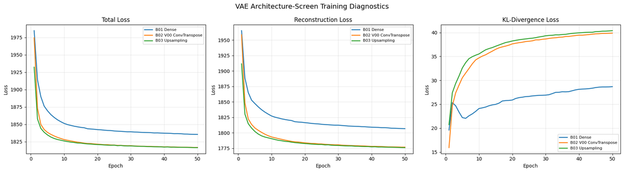

```
Training summary saved to: artifacts\vae\architecture_screen\baseline_training_summary.csv
Training figure saved to: artifacts\vae\architecture_screen\baseline_training_loss_comparison.png
Official test-set usage: None
```

```python
# Validate new histories and compare them with saved V00.
v00_saved_history_path = (
    Path("artifacts")
    / "vae"
    / "V00"
    / "V00_training_history.csv"
)
assert v00_saved_history_path.exists(), (
    "The completed V00 history was not found. "
    "V00 must be reused, not retrained."
)

v00_screen_history_df = pd.read_csv(
    v00_saved_history_path,
    index_col="epoch"
)

baseline_screen_histories = {
    "B01 Dense": dense_baseline_history_df,
    "B02 V00 ConvTranspose": (
        v00_screen_history_df
    ),
    "B03 Upsampling": (
        upsampling_baseline_history_df
    )
}

required_loss_columns = [
    "total_loss",
    "reconstruction_loss",
    "kl_loss"
]

training_summary_rows = []

for (
    candidate_name,
    candidate_history
) in baseline_screen_histories.items():
    assert len(candidate_history) == 50
    assert set(
        required_loss_columns
    ).issubset(
        candidate_history.columns
    )
    assert np.isfinite(
        candidate_history[
            required_loss_columns
        ].to_numpy()
    ).all()

    training_summary_rows.append({
        "candidate": candidate_name,
        "epoch_1_total_loss": (
            candidate_history.loc[
                1,
                "total_loss"
            ]
        ),
        "epoch_50_total_loss": (
            candidate_history.loc[
                50,
                "total_loss"
            ]
        ),
        "epoch_50_reconstruction_loss": (
            candidate_history.loc[
                50,
                "reconstruction_loss"
            ]
        ),
        "epoch_50_kl_loss": (
            candidate_history.loc[
                50,
                "kl_loss"
            ]
        )
    })

baseline_training_summary_df = (
    pd.DataFrame(
        training_summary_rows
    ).set_index("candidate")
)

print(
    "Three-baseline training-history "
    "validation passed."
)
display(
    baseline_training_summary_df.round(4)
)

fig, axes = plt.subplots(
    1,
    3,
    figsize=(18, 5)
)

loss_plot_settings = [
    (
        "total_loss",
        "Total Loss"
    ),
    (
        "reconstruction_loss",
        "Reconstruction Loss"
    ),
    (
        "kl_loss",
        "KL-Divergence Loss"
    )
]

for axis, (
    loss_column,
    loss_title
) in zip(
    axes,
    loss_plot_settings
):
    for (
        candidate_name,
        candidate_history
    ) in baseline_screen_histories.items():
        axis.plot(
            candidate_history.index,
            candidate_history[
                loss_column
            ],
            label=candidate_name,
            linewidth=1.8
        )

    axis.set_title(loss_title)
    axis.set_xlabel("Epoch")
    axis.set_ylabel("Loss")
    axis.grid(alpha=0.3)
    axis.legend(fontsize=8)

plt.suptitle(
    "VAE Architecture-Screen Training Diagnostics",
    fontsize=14
)
plt.tight_layout()

baseline_screen_root = (
    Path("artifacts")
    / "vae"
    / "architecture_screen"
)
baseline_screen_root.mkdir(
    parents=True,
    exist_ok=True
)

training_figure_path = (
    baseline_screen_root
    / "baseline_training_loss_comparison.png"
)
plt.savefig(
    training_figure_path,
    dpi=150,
    bbox_inches="tight"
)
plt.show()

training_summary_path = (
    baseline_screen_root
    / "baseline_training_summary.csv"
)
baseline_training_summary_df.to_csv(
    training_summary_path
)

print(
    "Training summary saved to: "
    f"{training_summary_path}"
)
print(
    "Training figure saved to: "
    f"{training_figure_path}"
)
print("Official test-set usage: None")
```

#### 5.6.6 Development Fréchet Inception Distance (FID)

The three architecture candidates require a common quantitative image-distribution measure. **FID**, introduced by Heusel et al. [5], compares the mean and covariance of InceptionV3 features from real and generated images. A lower value means that the generated feature distribution is closer to the real training-image feature distribution.

This implementation deliberately matches the team's GAN development-FID protocol:

- real reference: all 50,000 official CIFAR-10 training images
- generated images: 5,000 per evaluation
- repeated generation seeds using the same saved decoder weights: 1001, 1002 and 1003
- feature extractor: ImageNet-pretrained InceptionV3 with global average pooling
- input preparation: RGB `uint8` images resized from 32 × 32 to 299 × 299 with bilinear interpolation, followed by InceptionV3 preprocessing
- numerical calculation: float64 feature statistics and the standard Fréchet-distance equation
- protected test set: not used

Only the final epoch-50 decoder of each baseline is evaluated here. This gives all three architectures the same fixed training budget and leaves the completed V00 experiment unchanged. V00 is **not retrained**: an identical decoder is rebuilt and its existing saved final weights are loaded.

FID is used as one item of evidence rather than an automatic winner-selection rule. InceptionV3 was trained on ImageNet and CIFAR-10 images must be enlarged substantially, so the score should be interpreted together with fixed-seed grids, uncurated samples, training stability, diversity/repetition checks and the blind manual score.

```python
# Development-FID imports and locked protocol.
import gc

from scipy.linalg import sqrtm
from tensorflow.keras.applications import InceptionV3
from tensorflow.keras.applications.inception_v3 import preprocess_input
from tqdm.auto import tqdm


BASELINE_FID_SAMPLE_COUNT = 5_000
BASELINE_FID_IMAGE_SIZE = (299, 299)
BASELINE_FID_FEATURE_DIM = 2_048
BASELINE_FID_BATCH_SIZE = 64
BASELINE_FID_GENERATION_BATCH_SIZE = 256

BASELINE_FID_SEEDS = (
    1001,
    1002,
    1003
)

BASELINE_FID_CHECKPOINT_EPOCH = 50
BASELINE_FID_REAL_REFERENCE_COUNT = 50_000

baseline_fid_artifact_dir = (
    Path("artifacts")
    / "vae"
    / "architecture_screen"
    / "fid"
)
baseline_fid_artifact_dir.mkdir(
    parents=True,
    exist_ok=True
)

baseline_fid_results_path = (
    baseline_fid_artifact_dir
    / "baseline_repeated_fid_results.csv"
)
baseline_fid_summary_path = (
    baseline_fid_artifact_dir
    / "baseline_fid_summary.csv"
)

assert x_train_uint8.shape == (
    BASELINE_FID_REAL_REFERENCE_COUNT,
    32,
    32,
    3
)
assert x_train_uint8.dtype == np.uint8
assert BASELINE_FID_CHECKPOINT_EPOCH == (
    BASELINE_SCREEN_EPOCHS
)

print(
    "Generated images per FID run: "
    f"{BASELINE_FID_SAMPLE_COUNT:,}"
)
print(
    "Repeated FID seeds: "
    f"{BASELINE_FID_SEEDS}"
)
print(
    "Real training-reference images: "
    f"{BASELINE_FID_REAL_REFERENCE_COUNT:,}"
)
print(
    "Compared checkpoint: epoch "
    f"{BASELINE_FID_CHECKPOINT_EPOCH}"
)
print("Official test-set usage: None")
```

```
Generated images per FID run: 5,000
Repeated FID seeds: (1001, 1002, 1003)
Real training-reference images: 50,000
Compared checkpoint: epoch 50
Official test-set usage: None
```

```python
# Create reproducible standard-normal VAE latent vectors.
def make_vae_fid_latents(
    sample_count,
    latent_dim,
    seed
):
    return tf.random.stateless_normal(
        shape=(
            sample_count,
            latent_dim
        ),
        seed=[seed, 0],
        dtype=tf.float32
    )


# Generate reproducible RGB uint8 images from a
# sigmoid-output VAE decoder.
def generate_vae_images_uint8(
    decoder_model,
    sample_count,
    latent_dim,
    seed,
    batch_size=256
):
    latent_vectors = make_vae_fid_latents(
        sample_count=sample_count,
        latent_dim=latent_dim,
        seed=seed
    )

    generated_batches = []

    for start in range(
        0,
        sample_count,
        batch_size
    ):
        latent_batch = latent_vectors[
            start:start + batch_size
        ]

        image_batch = decoder_model(
            latent_batch,
            training=False
        )

        image_batch = tf.clip_by_value(
            image_batch * 255.0,
            0.0,
            255.0
        )

        image_batch = tf.cast(
            tf.round(image_batch),
            tf.uint8
        )

        generated_batches.append(
            image_batch.numpy()
        )

    generated_images = np.concatenate(
        generated_batches,
        axis=0
    )

    assert generated_images.shape == (
        sample_count,
        32,
        32,
        3
    )
    assert generated_images.dtype == np.uint8

    return generated_images


# Extract 2,048-dimensional InceptionV3 features.
def extract_vae_inception_features(
    images_uint8,
    feature_extractor,
    batch_size=64
):
    images_uint8 = np.asarray(
        images_uint8
    )

    if images_uint8.dtype != np.uint8:
        raise TypeError(
            "Images must use uint8 [0, 255]."
        )

    if images_uint8.shape[1:] != (
        32,
        32,
        3
    ):
        raise ValueError(
            "Images must have shape "
            "(n, 32, 32, 3)."
        )

    feature_count = len(
        images_uint8
    )

    features = np.empty(
        (
            feature_count,
            BASELINE_FID_FEATURE_DIM
        ),
        dtype=np.float32
    )

    for start in tqdm(
        range(
            0,
            feature_count,
            batch_size
        ),
        desc="Extracting Inception features"
    ):
        end = min(
            start + batch_size,
            feature_count
        )

        image_batch = tf.convert_to_tensor(
            images_uint8[start:end],
            dtype=tf.float32
        )

        image_batch = tf.image.resize(
            image_batch,
            BASELINE_FID_IMAGE_SIZE,
            method="bilinear"
        )

        image_batch = preprocess_input(
            image_batch
        )

        batch_features = feature_extractor(
            image_batch,
            training=False
        )

        features[start:end] = (
            batch_features.numpy()
            .astype(np.float32)
        )

    if not np.isfinite(features).all():
        raise ValueError(
            "Inception features contain "
            "non-finite values."
        )

    return features


# Calculate a feature mean and covariance matrix.
def calculate_vae_feature_statistics(
    features
):
    features = np.asarray(
        features,
        dtype=np.float64
    )

    feature_mean = np.mean(
        features,
        axis=0
    )

    feature_covariance = np.cov(
        features,
        rowvar=False
    )

    return (
        feature_mean,
        feature_covariance
    )


# Calculate Fréchet distance from feature statistics.
def calculate_vae_fid_from_statistics(
    mean_1,
    covariance_1,
    mean_2,
    covariance_2,
    epsilon=1e-6
):
    mean_difference = (
        mean_1 - mean_2
    )

    covariance_mean = sqrtm(
        covariance_1
        @ covariance_2
    )

    if not np.isfinite(
        covariance_mean
    ).all():
        identity = np.eye(
            covariance_1.shape[0]
        ) * epsilon

        covariance_mean = sqrtm(
            (covariance_1 + identity)
            @ (covariance_2 + identity)
        )

    if np.iscomplexobj(
        covariance_mean
    ):
        maximum_imaginary = np.max(
            np.abs(
                covariance_mean.imag
            )
        )

        if maximum_imaginary > 1e-3:
            raise ValueError(
                "FID square root contains "
                "large imaginary values."
            )

        covariance_mean = (
            covariance_mean.real
        )

    fid_value = (
        mean_difference
        @ mean_difference
        + np.trace(covariance_1)
        + np.trace(covariance_2)
        - 2.0
        * np.trace(covariance_mean)
    )

    return max(
        float(fid_value),
        0.0
    )


print(
    "VAE development-FID functions "
    "defined successfully."
)
```

```
VAE development-FID functions defined successfully.
```

##### Frozen InceptionV3 extractor and real training reference

The next cell creates the frozen feature extractor and calculates the reference feature statistics from all 50,000 CIFAR-10 training images. The feature matrix is retained only in the current runtime, matching the GAN notebook's procedure.

The ImageNet weights may be downloaded automatically the first time this cell is run. This step is computationally expensive, but the real reference is extracted only once and then reused for all three VAE baselines.

```python
baseline_fid_feature_extractor = InceptionV3(
    include_top=False,
    weights="imagenet",
    input_shape=(
        299,
        299,
        3
    ),
    pooling="avg"
)

baseline_fid_feature_extractor.trainable = False

assert (
    baseline_fid_feature_extractor.output_shape
    == (
        None,
        BASELINE_FID_FEATURE_DIM
    )
)

# Lightweight numerical validation of the FID formula.
fid_validation_rng = np.random.default_rng(
    SEED
)
fid_validation_features = (
    fid_validation_rng.normal(
        size=(256, 64)
    )
)

(
    fid_validation_mean,
    fid_validation_covariance
) = calculate_vae_feature_statistics(
    fid_validation_features
)

identical_feature_fid = (
    calculate_vae_fid_from_statistics(
        fid_validation_mean,
        fid_validation_covariance,
        fid_validation_mean,
        fid_validation_covariance
    )
)

assert identical_feature_fid < 1e-5

print(
    "FID extractor input shape:  "
    f"{baseline_fid_feature_extractor.input_shape}"
)
print(
    "FID extractor output shape: "
    f"{baseline_fid_feature_extractor.output_shape}"
)
print(
    "Identical-feature FID:       "
    f"{identical_feature_fid:.8f}"
)


real_feature_start = time.time()

baseline_real_fid_features = (
    extract_vae_inception_features(
        images_uint8=x_train_uint8,
        feature_extractor=(
            baseline_fid_feature_extractor
        ),
        batch_size=BASELINE_FID_BATCH_SIZE
    )
)

(
    baseline_real_fid_mean,
    baseline_real_fid_covariance
) = calculate_vae_feature_statistics(
    baseline_real_fid_features
)

real_feature_minutes = (
    time.time() - real_feature_start
) / 60.0

assert baseline_real_fid_features.shape == (
    BASELINE_FID_REAL_REFERENCE_COUNT,
    BASELINE_FID_FEATURE_DIM
)
assert baseline_real_fid_mean.shape == (
    BASELINE_FID_FEATURE_DIM,
)
assert (
    baseline_real_fid_covariance.shape
    == (
        BASELINE_FID_FEATURE_DIM,
        BASELINE_FID_FEATURE_DIM
    )
)

print(
    "\nReal feature shape: "
    f"{baseline_real_fid_features.shape}"
)
print(
    "Real mean shape:    "
    f"{baseline_real_fid_mean.shape}"
)
print(
    "Real covariance:    "
    f"{baseline_real_fid_covariance.shape}"
)
print(
    "Extraction time:    "
    f"{real_feature_minutes:.2f} minutes"
)
print("Official test-set usage: None")
```

```
Downloading data from https://storage.googleapis.com/tensorflow/keras-applications/inception_v3/inception_v3_weights_tf_dim_ordering_tf_kernels_notop.h5
FID extractor input shape:  (None, 299, 299, 3)
FID extractor output shape: (None, 2048)
Identical-feature FID:       0.00000000
```

```
Real feature shape: (50000, 2048)
Real mean shape:    (2048,)
Real covariance:    (2048, 2048)
Extraction time:    3.93 minutes
Official test-set usage: None
```

##### Load the three final decoders

The completed V00 ConvTranspose decoder is rebuilt with the exact original layer sequence and then loaded from its saved final weights. This is inference only: no V00 training cell is rerun.

The Dense and Upsampling decoders are also reloaded from their saved final epoch-50 files. Reloading before evaluation ensures that the FID results correspond to the durable artefacts rather than to an accidental in-memory state.

```python
def build_v00_fid_decoder(
    latent_dim=64
):
    # Rebuild the unchanged V00 decoder for inference.

    decoder_inputs = keras.Input(
        shape=(latent_dim,),
        name="decoder_input"
    )

    decoder_x = layers.Dense(
        units=4 * 4 * 128,
        activation="relu",
        name="decoder_dense"
    )(decoder_inputs)

    decoder_x = layers.Reshape(
        target_shape=(4, 4, 128),
        name="decoder_reshape"
    )(decoder_x)

    decoder_x = layers.Conv2DTranspose(
        filters=128,
        kernel_size=3,
        strides=2,
        padding="same",
        activation="relu",
        name="decoder_deconv_1"
    )(decoder_x)

    decoder_x = layers.Conv2DTranspose(
        filters=64,
        kernel_size=3,
        strides=2,
        padding="same",
        activation="relu",
        name="decoder_deconv_2"
    )(decoder_x)

    decoder_x = layers.Conv2DTranspose(
        filters=32,
        kernel_size=3,
        strides=2,
        padding="same",
        activation="relu",
        name="decoder_deconv_3"
    )(decoder_x)

    decoder_outputs = layers.Conv2D(
        filters=3,
        kernel_size=3,
        strides=1,
        padding="same",
        activation="sigmoid",
        name="decoder_output"
    )(decoder_x)

    return keras.Model(
        inputs=decoder_inputs,
        outputs=decoder_outputs,
        name="V00_fid_decoder"
    )


v00_fid_decoder_path = (
    Path("artifacts")
    / "vae"
    / "V00"
    / "weights"
    / "V00_decoder_final.weights.h5"
)
dense_fid_decoder_path = (
    Path("artifacts")
    / "vae"
    / "architecture_screen"
    / DENSE_BASELINE_ID
    / "weights"
    / (
        f"{DENSE_BASELINE_ID}_decoder_final"
        ".weights.h5"
    )
)
upsampling_fid_decoder_path = (
    Path("artifacts")
    / "vae"
    / "architecture_screen"
    / UPSAMPLING_BASELINE_ID
    / "weights"
    / (
        f"{UPSAMPLING_BASELINE_ID}_decoder_final"
        ".weights.h5"
    )
)

for required_decoder_path in [
    v00_fid_decoder_path,
    dense_fid_decoder_path,
    upsampling_fid_decoder_path
]:
    assert required_decoder_path.exists(), (
        "Required final decoder weights were "
        f"not found: {required_decoder_path}"
    )

v00_fid_decoder = build_v00_fid_decoder(
    latent_dim=BASELINE_SCREEN_LATENT_DIM
)
v00_fid_decoder.load_weights(
    str(v00_fid_decoder_path)
)

dense_baseline_decoder.load_weights(
    str(dense_fid_decoder_path)
)
upsampling_baseline_decoder.load_weights(
    str(upsampling_fid_decoder_path)
)

baseline_fid_decoders = {
    "B01_DENSE": {
        "architecture": "Dense VAE",
        "decoder": dense_baseline_decoder
    },
    "B02_V00_CONVTRANSPOSE": {
        "architecture": (
            "ConvTranspose VAE (existing V00)"
        ),
        "decoder": v00_fid_decoder
    },
    "B03_UPSAMPLING": {
        "architecture": "Upsampling VAE",
        "decoder": upsampling_baseline_decoder
    }
}

decoder_validation_latents = (
    make_vae_fid_latents(
        sample_count=2,
        latent_dim=BASELINE_SCREEN_LATENT_DIM,
        seed=BASELINE_FID_SEEDS[0]
    )
)

for (
    candidate_id,
    candidate_details
) in baseline_fid_decoders.items():
    validation_output = (
        candidate_details["decoder"](
            decoder_validation_latents,
            training=False
        )
    )

    assert validation_output.shape == (
        2,
        32,
        32,
        3
    )
    assert np.isfinite(
        validation_output.numpy()
    ).all()
    assert (
        tf.reduce_min(
            validation_output
        ).numpy()
        >= 0.0
    )
    assert (
        tf.reduce_max(
            validation_output
        ).numpy()
        <= 1.0
    )

    print(
        f"{candidate_id} decoder reload "
        "validation passed."
    )

print(
    "\nAll three epoch-50 decoders are "
    "ready for inference-only FID."
)
print("V00 retrained: No")
```

```
B01_DENSE decoder reload validation passed.
B02_V00_CONVTRANSPOSE decoder reload validation passed.
B03_UPSAMPLING decoder reload validation passed.

All three epoch-50 decoders are ready for inference-only FID.
V00 retrained: No
```

##### Repeated development FID for the architecture screen

Each decoder is now evaluated three times using the same three stateless latent-vector sets. Because every VAE has latent dimension 64, a given seed supplies exactly the same latent vectors to all three decoders.

The code saves both the individual repeated scores and a mean/standard-deviation summary. The lower mean FID is better under this specific protocol, while a smaller standard deviation indicates less variation across the three generated samples. No final architecture is selected automatically in this cell.

```python
baseline_repeated_fid_rows = []

for (
    candidate_id,
    candidate_details
) in baseline_fid_decoders.items():
    candidate_decoder = (
        candidate_details["decoder"]
    )
    architecture_name = (
        candidate_details["architecture"]
    )

    print(
        "\nEvaluating "
        f"{candidate_id}: {architecture_name}"
    )

    for fid_seed in BASELINE_FID_SEEDS:
        generated_images = (
            generate_vae_images_uint8(
                decoder_model=(
                    candidate_decoder
                ),
                sample_count=(
                    BASELINE_FID_SAMPLE_COUNT
                ),
                latent_dim=(
                    BASELINE_SCREEN_LATENT_DIM
                ),
                seed=fid_seed,
                batch_size=(
                    BASELINE_FID_GENERATION_BATCH_SIZE
                )
            )
        )

        generated_features = (
            extract_vae_inception_features(
                images_uint8=generated_images,
                feature_extractor=(
                    baseline_fid_feature_extractor
                ),
                batch_size=(
                    BASELINE_FID_BATCH_SIZE
                )
            )
        )

        (
            generated_mean,
            generated_covariance
        ) = calculate_vae_feature_statistics(
            generated_features
        )

        fid_value = (
            calculate_vae_fid_from_statistics(
                baseline_real_fid_mean,
                baseline_real_fid_covariance,
                generated_mean,
                generated_covariance
            )
        )

        baseline_repeated_fid_rows.append({
            "candidate_id": candidate_id,
            "architecture": architecture_name,
            "evaluation": (
                "final_epoch_repeat"
            ),
            "checkpoint_epoch": (
                BASELINE_FID_CHECKPOINT_EPOCH
            ),
            "seed": fid_seed,
            "generated_sample_count": (
                BASELINE_FID_SAMPLE_COUNT
            ),
            "real_reference_count": (
                BASELINE_FID_REAL_REFERENCE_COUNT
            ),
            "fid": fid_value,
            "test_set_used": False
        })

        print(
            f"Seed {fid_seed} FID: "
            f"{fid_value:.4f}"
        )

        del generated_images
        del generated_features
        del generated_mean
        del generated_covariance

        gc.collect()


baseline_repeated_fid_df = pd.DataFrame(
    baseline_repeated_fid_rows
)

baseline_repeated_fid_df.to_csv(
    baseline_fid_results_path,
    index=False
)

baseline_fid_summary_df = (
    baseline_repeated_fid_df
    .groupby(
        [
            "candidate_id",
            "architecture",
            "checkpoint_epoch"
        ],
        as_index=False
    )
    .agg(
        fid_mean=("fid", "mean"),
        fid_std=("fid", "std"),
        fid_min=("fid", "min"),
        fid_max=("fid", "max"),
        repeat_count=("fid", "size")
    )
    .sort_values(
        "fid_mean",
        ascending=True
    )
    .reset_index(drop=True)
)

baseline_fid_summary_df.insert(
    0,
    "fid_rank",
    np.arange(
        1,
        len(baseline_fid_summary_df) + 1
    )
)

baseline_fid_summary_df.to_csv(
    baseline_fid_summary_path,
    index=False
)

assert len(
    baseline_repeated_fid_df
) == (
    len(baseline_fid_decoders)
    * len(BASELINE_FID_SEEDS)
)
assert np.isfinite(
    baseline_repeated_fid_df["fid"]
).all()
assert (
    baseline_repeated_fid_df["fid"]
    >= 0.0
).all()
assert (
    baseline_fid_summary_df[
        "repeat_count"
    ] == len(BASELINE_FID_SEEDS)
).all()

print(
    "\nRepeated development-FID results:"
)
display(
    baseline_repeated_fid_df.round(4)
)

print(
    "\nMechanical FID summary "
    "(lower mean is better):"
)
display(
    baseline_fid_summary_df.round(4)
)

print(
    "\nRepeated results saved to: "
    f"{baseline_fid_results_path}"
)
print(
    "FID summary saved to: "
    f"{baseline_fid_summary_path}"
)
print(
    "Final baseline selected automatically: No"
)
print("Official test-set usage: None")
```

```
Evaluating B01_DENSE: Dense VAE
```

```
Seed 1001 FID: 198.1399
```

```
Seed 1002 FID: 197.5218
```

```
Seed 1003 FID: 198.0911

Evaluating B02_V00_CONVTRANSPOSE: ConvTranspose VAE (existing V00)
```

```
Seed 1001 FID: 167.0935
```

```
Seed 1002 FID: 166.5586
```

```
Seed 1003 FID: 166.2937

Evaluating B03_UPSAMPLING: Upsampling VAE
```

```
Seed 1001 FID: 187.7383
```

```
Seed 1002 FID: 187.4780
```

```
Seed 1003 FID: 187.0890

Repeated development-FID results:
```

|  | candidate_id | architecture | evaluation | checkpoint_epoch | seed | generated_sample_count | real_reference_count | fid | test_set_used |
| --- | --- | --- | --- | --- | --- | --- | --- | --- | --- |
| 0 | B01_DENSE | Dense VAE | final_epoch_repeat | 50 | 1001 | 5000 | 50000 | 198.1399 | False |
| 1 | B01_DENSE | Dense VAE | final_epoch_repeat | 50 | 1002 | 5000 | 50000 | 197.5218 | False |
| 2 | B01_DENSE | Dense VAE | final_epoch_repeat | 50 | 1003 | 5000 | 50000 | 198.0911 | False |
| 3 | B02_V00_CONVTRANSPOSE | ConvTranspose VAE (existing V00) | final_epoch_repeat | 50 | 1001 | 5000 | 50000 | 167.0935 | False |
| 4 | B02_V00_CONVTRANSPOSE | ConvTranspose VAE (existing V00) | final_epoch_repeat | 50 | 1002 | 5000 | 50000 | 166.5586 | False |
| 5 | B02_V00_CONVTRANSPOSE | ConvTranspose VAE (existing V00) | final_epoch_repeat | 50 | 1003 | 5000 | 50000 | 166.2937 | False |
| 6 | B03_UPSAMPLING | Upsampling VAE | final_epoch_repeat | 50 | 1001 | 5000 | 50000 | 187.7383 | False |
| 7 | B03_UPSAMPLING | Upsampling VAE | final_epoch_repeat | 50 | 1002 | 5000 | 50000 | 187.4780 | False |
| 8 | B03_UPSAMPLING | Upsampling VAE | final_epoch_repeat | 50 | 1003 | 5000 | 50000 | 187.0890 | False |

```
Mechanical FID summary (lower mean is better):
```

|  | fid_rank | candidate_id | architecture | checkpoint_epoch | fid_mean | fid_std | fid_min | fid_max | repeat_count |
| --- | --- | --- | --- | --- | --- | --- | --- | --- | --- |
| 0 | 1 | B02_V00_CONVTRANSPOSE | ConvTranspose VAE (existing V00) | 50 | 166.6486 | 0.4074 | 166.2937 | 167.0935 | 3 |
| 1 | 2 | B03_UPSAMPLING | Upsampling VAE | 50 | 187.4351 | 0.3268 | 187.0890 | 187.7383 | 3 |
| 2 | 3 | B01_DENSE | Dense VAE | 50 | 197.9176 | 0.3437 | 197.5218 | 198.1399 | 3 |

```
Repeated results saved to: artifacts\vae\architecture_screen\fid\baseline_repeated_fid_results.csv
FID summary saved to: artifacts\vae\architecture_screen\fid\baseline_fid_summary.csv
Final baseline selected automatically: No
Official test-set usage: None
```

#### 5.6.7 Executed Training and FID Findings

All three candidates completed the locked 50-epoch training budget without non-finite losses. The epoch-50 diagnostics were:

| Candidate | Total loss | Reconstruction loss | KL loss |
| --- | --- | --- | --- |
| B01 Dense | 1835.4427 | 1806.7628 | 28.6793 |
| B02 V00 ConvTranspose | 1816.6775 | 1776.8013 | 39.8766 |
| B03 Upsampling | **1816.3960** | **1775.9994** | 40.3952 |

Upsampling recorded the lowest total and reconstruction losses, but its advantage over V00 was only **0.0155% in total loss** and **0.0451% in reconstruction loss**. Dense was clearly weaker on both loss terms and used 1,666,944 encoder-plus-decoder parameters, which is 62.71% more than the 1,024,515 parameters used by V00 and Upsampling.

The repeated-generation-seed development-FID result produced a different and more relevant ordering for random generation:

| FID rank | Candidate | Mean FID | SD | Range |
| --- | --- | --- | --- | --- |
| 1 | **B02 V00 ConvTranspose** | **166.6486** | 0.4074 | 166.2937-167.0935 |
| 2 | B03 Upsampling | 187.4351 | 0.3268 | 187.0890-187.7383 |
| 3 | B01 Dense | 197.9176 | 0.3437 | 197.5218-198.1399 |

Under the same real reference, sample count and three generation seeds, V00's mean FID was **11.09% lower than Upsampling** and **15.80% lower than Dense**. These gaps are far larger than the within-model variation across generation seeds. This is strong evidence that the ConvTranspose decoder generated a distribution closer to the CIFAR-10 training distribution, despite Upsampling's negligible training-loss advantage. Because the same trained weights are reused, the standard deviation measures sampling variation rather than variation across independent training runs.

This result demonstrates why VAE total loss cannot be the sole architecture-selection metric. V00 is the **quantitative leader**, but it is not declared the final baseline architecture yet. The matched visual, reconstruction and diversity/repetition evidence below must first be checked for obvious failure modes that FID may miss.

#### 5.6.8 Matched Reconstruction Evaluation

The three final encoders and decoders are reloaded from their saved epoch-50 weights. The same 20 fixed training images used in the original V00 evaluation are reconstructed by every candidate using the deterministic posterior mean, `z_mean`.

MSE and MAE measure pixel error, while PSNR expresses reconstruction fidelity on a decibel scale. These metrics evaluate reconstruction rather than prior-sampled generation, so they complement but do not replace FID.

```python
# Reload the three final encoders for matched
# deterministic reconstruction evaluation.
#
# This local sampling layer keeps the cell
# self-contained after a kernel restart. It matches
# the original V00 reparameterisation layer and has
# no trainable weights.
class BaselineEvaluationSampling(
    layers.Layer
):
    def call(
        self,
        inputs
    ):
        z_mean, z_log_var = inputs

        batch_size = tf.shape(
            z_mean
        )[0]
        latent_dimension = tf.shape(
            z_mean
        )[1]

        epsilon = tf.random.normal(
            shape=(
                batch_size,
                latent_dimension
            )
        )

        return (
            z_mean
            + tf.exp(
                0.5 * z_log_var
            )
            * epsilon
        )


def build_v00_evaluation_encoder(
    latent_dim=64
):
    encoder_inputs = keras.Input(
        shape=(32, 32, 3),
        name="encoder_input"
    )

    encoder_x = layers.Conv2D(
        filters=32,
        kernel_size=3,
        strides=2,
        padding="same",
        activation="relu",
        name="encoder_conv_1"
    )(encoder_inputs)

    encoder_x = layers.Conv2D(
        filters=64,
        kernel_size=3,
        strides=2,
        padding="same",
        activation="relu",
        name="encoder_conv_2"
    )(encoder_x)

    encoder_x = layers.Conv2D(
        filters=128,
        kernel_size=3,
        strides=2,
        padding="same",
        activation="relu",
        name="encoder_conv_3"
    )(encoder_x)

    encoder_x = layers.Flatten(
        name="encoder_flatten"
    )(encoder_x)

    encoder_x = layers.Dense(
        units=256,
        activation="relu",
        name="encoder_dense"
    )(encoder_x)

    encoder_z_mean = layers.Dense(
        units=latent_dim,
        name="z_mean"
    )(encoder_x)

    encoder_z_log_var = layers.Dense(
        units=latent_dim,
        name="z_log_var"
    )(encoder_x)

    encoder_z = BaselineEvaluationSampling(
        name="z_sampling"
    )([
        encoder_z_mean,
        encoder_z_log_var
    ])

    return keras.Model(
        inputs=encoder_inputs,
        outputs=[
            encoder_z_mean,
            encoder_z_log_var,
            encoder_z
        ],
        name="V00_evaluation_encoder"
    )


v00_evaluation_encoder_path = (
    Path("artifacts")
    / "vae"
    / "V00"
    / "weights"
    / "V00_encoder_final.weights.h5"
)
dense_evaluation_encoder_path = (
    Path("artifacts")
    / "vae"
    / "architecture_screen"
    / DENSE_BASELINE_ID
    / "weights"
    / (
        f"{DENSE_BASELINE_ID}_encoder_final"
        ".weights.h5"
    )
)
upsampling_evaluation_encoder_path = (
    Path("artifacts")
    / "vae"
    / "architecture_screen"
    / UPSAMPLING_BASELINE_ID
    / "weights"
    / (
        f"{UPSAMPLING_BASELINE_ID}_encoder_final"
        ".weights.h5"
    )
)

for required_encoder_path in [
    v00_evaluation_encoder_path,
    dense_evaluation_encoder_path,
    upsampling_evaluation_encoder_path
]:
    assert required_encoder_path.exists(), (
        "Required final encoder weights were "
        f"not found: {required_encoder_path}"
    )

v00_evaluation_encoder = (
    build_v00_evaluation_encoder(
        latent_dim=BASELINE_SCREEN_LATENT_DIM
    )
)
v00_evaluation_encoder.load_weights(
    str(v00_evaluation_encoder_path)
)

dense_baseline_encoder.load_weights(
    str(dense_evaluation_encoder_path)
)
upsampling_baseline_encoder.load_weights(
    str(upsampling_evaluation_encoder_path)
)

baseline_evaluation_models = {
    "B01_DENSE": {
        "display_name": "B01 Dense",
        "encoder": dense_baseline_encoder,
        "decoder": dense_baseline_decoder
    },
    "B02_V00_CONVTRANSPOSE": {
        "display_name": (
            "B02 V00 ConvTranspose"
        ),
        "encoder": v00_evaluation_encoder,
        "decoder": v00_fid_decoder
    },
    "B03_UPSAMPLING": {
        "display_name": "B03 Upsampling",
        "encoder": upsampling_baseline_encoder,
        "decoder": upsampling_baseline_decoder
    }
}

assert set(
    baseline_evaluation_models
) == set(
    baseline_fid_decoders
)

print(
    "All three saved encoder-decoder pairs "
    "are ready for matched evaluation."
)
print("V00 retrained: No")
print("Official test-set usage: None")
```

```
All three saved encoder-decoder pairs are ready for matched evaluation.
V00 retrained: No
Official test-set usage: None
```

```python
baseline_fixed_indices_path = (
    Path("artifacts")
    / "vae"
    / "fixed_inputs"
    / "fixed_reconstruction_indices.npy"
)
assert baseline_fixed_indices_path.exists()

baseline_fixed_indices = np.load(
    baseline_fixed_indices_path
)
baseline_fixed_images = x_train_vae[
    baseline_fixed_indices
]
baseline_fixed_labels = y_train[
    baseline_fixed_indices
]

assert baseline_fixed_images.shape == (
    20,
    32,
    32,
    3
)

baseline_reconstruction_rows = []
baseline_reconstruction_images = {}

for (
    candidate_id,
    model_details
) in baseline_evaluation_models.items():
    (
        candidate_z_mean,
        _,
        _
    ) = model_details["encoder"].predict(
        baseline_fixed_images,
        verbose=0
    )

    candidate_reconstructions = (
        model_details["decoder"].predict(
            candidate_z_mean,
            verbose=0
        )
    )
    candidate_reconstructions = np.clip(
        candidate_reconstructions,
        0.0,
        1.0
    )

    baseline_reconstruction_images[
        candidate_id
    ] = candidate_reconstructions

    mse_per_image = np.mean(
        np.square(
            baseline_fixed_images
            - candidate_reconstructions
        ),
        axis=(1, 2, 3)
    )
    mae_per_image = np.mean(
        np.abs(
            baseline_fixed_images
            - candidate_reconstructions
        ),
        axis=(1, 2, 3)
    )
    psnr_per_image = tf.image.psnr(
        baseline_fixed_images,
        candidate_reconstructions,
        max_val=1.0
    ).numpy()

    for image_position in range(
        len(baseline_fixed_images)
    ):
        baseline_reconstruction_rows.append({
            "candidate_id": candidate_id,
            "architecture": (
                model_details["display_name"]
            ),
            "fixed_position": image_position,
            "training_index": int(
                baseline_fixed_indices[
                    image_position
                ]
            ),
            "class_id": int(
                baseline_fixed_labels[
                    image_position
                ]
            ),
            "class_name": class_names[
                int(
                    baseline_fixed_labels[
                        image_position
                    ]
                )
            ],
            "mse": float(
                mse_per_image[
                    image_position
                ]
            ),
            "mae": float(
                mae_per_image[
                    image_position
                ]
            ),
            "psnr_db": float(
                psnr_per_image[
                    image_position
                ]
            ),
            "test_set_used": False
        })


baseline_reconstruction_details_df = (
    pd.DataFrame(
        baseline_reconstruction_rows
    )
)

baseline_reconstruction_summary_df = (
    baseline_reconstruction_details_df
    .groupby(
        [
            "candidate_id",
            "architecture"
        ],
        as_index=False
    )
    .agg(
        mean_mse=("mse", "mean"),
        mean_mae=("mae", "mean"),
        mean_psnr_db=("psnr_db", "mean"),
        evaluated_images=(
            "fixed_position",
            "size"
        )
    )
    .sort_values(
        "mean_mse",
        ascending=True
    )
    .reset_index(drop=True)
)

baseline_reconstruction_details_path = (
    baseline_screen_root
    / "baseline_reconstruction_details.csv"
)
baseline_reconstruction_summary_path = (
    baseline_screen_root
    / "baseline_reconstruction_summary.csv"
)

baseline_reconstruction_details_df.to_csv(
    baseline_reconstruction_details_path,
    index=False
)
baseline_reconstruction_summary_df.to_csv(
    baseline_reconstruction_summary_path,
    index=False
)

# Show the first fixed image from every class.
class_grid_positions = np.arange(
    0,
    20,
    2
)

reconstruction_grid_rows = [
    (
        "Original",
        baseline_fixed_images
    ),
    *[
        (
            model_details["display_name"],
            baseline_reconstruction_images[
                candidate_id
            ]
        )
        for (
            candidate_id,
            model_details
        ) in baseline_evaluation_models.items()
    ]
]

fig, axes = plt.subplots(
    nrows=len(reconstruction_grid_rows),
    ncols=10,
    figsize=(18, 8)
)

for row_index, (
    row_name,
    row_images
) in enumerate(reconstruction_grid_rows):
    for column_index, image_position in enumerate(
        class_grid_positions
    ):
        axes[
            row_index,
            column_index
        ].imshow(
            row_images[image_position]
        )
        axes[
            row_index,
            column_index
        ].axis("off")

        if row_index == 0:
            axes[
                row_index,
                column_index
            ].set_title(
                class_names[column_index],
                fontsize=9
            )

    axes[row_index, 0].text(
        -0.25,
        0.5,
        row_name,
        transform=axes[
            row_index,
            0
        ].transAxes,
        rotation=90,
        va="center",
        ha="right",
        fontsize=9
    )

fig.suptitle(
    "Matched VAE Reconstructions: "
    "One Fixed Training Image per Class",
    fontsize=14
)
plt.tight_layout()

baseline_reconstruction_grid_path = (
    baseline_screen_root
    / "baseline_matched_reconstruction_grid.png"
)
plt.savefig(
    baseline_reconstruction_grid_path,
    dpi=150,
    bbox_inches="tight"
)
plt.show()

assert (
    baseline_reconstruction_summary_df[
        "evaluated_images"
    ] == 20
).all()
assert np.isfinite(
    baseline_reconstruction_summary_df[
        [
            "mean_mse",
            "mean_mae",
            "mean_psnr_db"
        ]
    ].to_numpy()
).all()

print(
    "Matched reconstruction summary:"
)
display(
    baseline_reconstruction_summary_df
    .round(6)
)
print(
    "Details saved to: "
    f"{baseline_reconstruction_details_path}"
)
print(
    "Summary saved to: "
    f"{baseline_reconstruction_summary_path}"
)
print(
    "Grid saved to: "
    f"{baseline_reconstruction_grid_path}"
)
print("Official test-set usage: None")
```

[output not shown]

[figure not shown]

```
Matched reconstruction summary:
```

|  | candidate_id | architecture | mean_mse | mean_mae | mean_psnr_db | evaluated_images |
| --- | --- | --- | --- | --- | --- | --- |
| 0 | B03_UPSAMPLING | B03 Upsampling | 0.009560 | 0.072157 | 20.711495 | 20 |
| 1 | B02_V00_CONVTRANSPOSE | B02 V00 ConvTranspose | 0.009583 | 0.071707 | 20.768258 | 20 |
| 2 | B01_DENSE | B01 Dense | 0.013673 | 0.087137 | 19.224346 | 20 |

```
Details saved to: artifacts\vae\architecture_screen\baseline_reconstruction_details.csv
Summary saved to: artifacts\vae\architecture_screen\baseline_reconstruction_summary.csv
Grid saved to: artifacts\vae\architecture_screen\baseline_matched_reconstruction_grid.png
Official test-set usage: None
```

#### 5.6.9 Matched Fixed-Latent Generation Grids

The same 25 stateless standard-normal latent vectors are passed to all three decoders. The images are uncurated: no image is removed, reordered or replaced according to perceived quality.

The combined grid aligns the first ten latent vectors by column, making decoder differences visible while controlling the latent input. Separate 5 × 5 grids retain the full 25-image sample for each candidate.

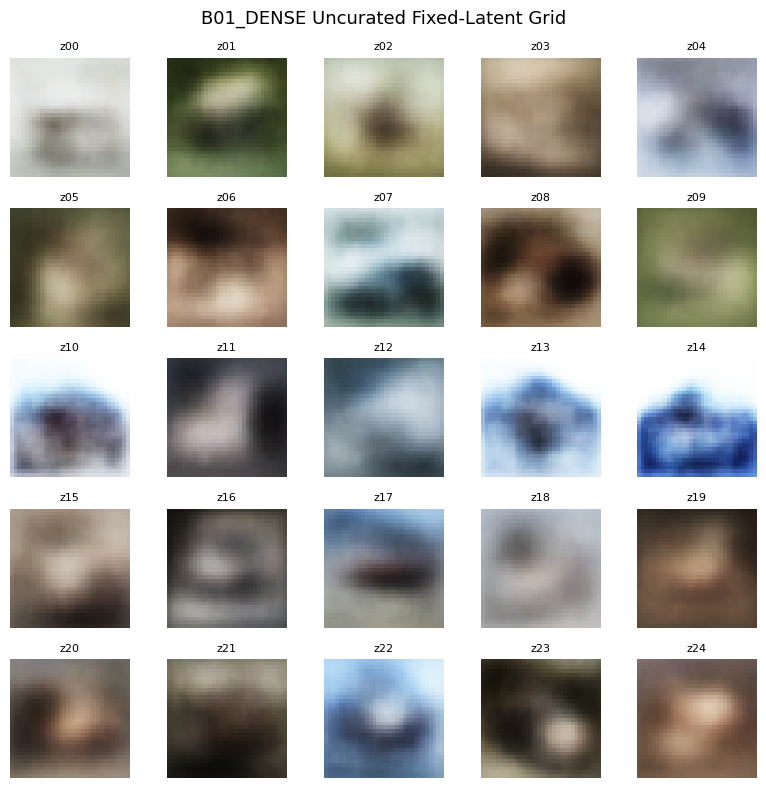

```
Saved B01_DENSE grid: artifacts\vae\architecture_screen\B01_DENSE_fixed_seed_1101_grid.png
```

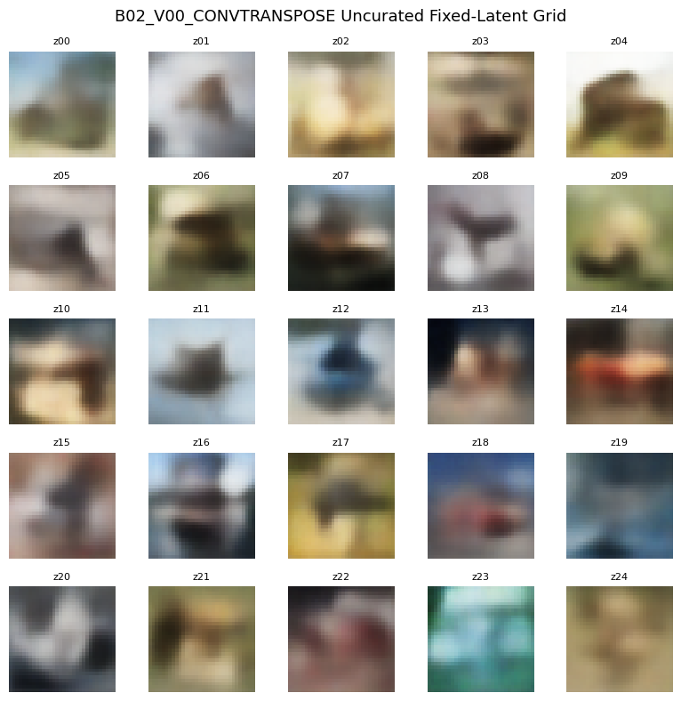

```
Saved B02_V00_CONVTRANSPOSE grid: artifacts\vae\architecture_screen\B02_V00_CONVTRANSPOSE_fixed_seed_1101_grid.png
```

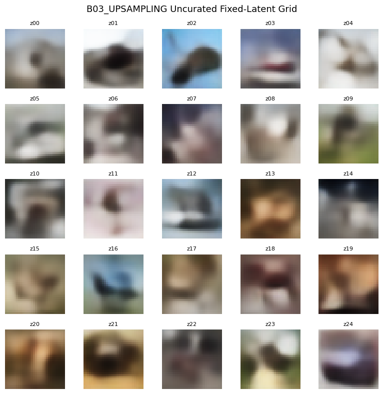

```
Saved B03_UPSAMPLING grid: artifacts\vae\architecture_screen\B03_UPSAMPLING_fixed_seed_1101_grid.png
```

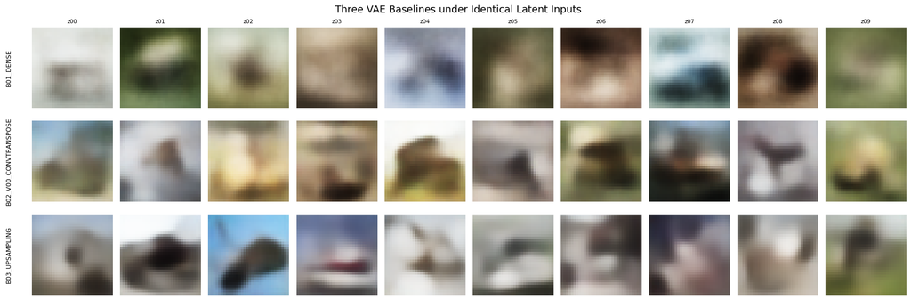

```
Matched generation grid saved to: artifacts\vae\architecture_screen\baseline_matched_fixed_latent_comparison.png
Images curated or selectively removed: No
```

```python
BASELINE_VISUAL_SEED = 1101
BASELINE_VISUAL_SAMPLE_COUNT = 25

baseline_visual_latents = (
    make_vae_fid_latents(
        sample_count=(
            BASELINE_VISUAL_SAMPLE_COUNT
        ),
        latent_dim=(
            BASELINE_SCREEN_LATENT_DIM
        ),
        seed=BASELINE_VISUAL_SEED
    )
)

baseline_fixed_generation_images = {}

for (
    candidate_id,
    candidate_details
) in baseline_fid_decoders.items():
    generated_images = (
        candidate_details["decoder"](
            baseline_visual_latents,
            training=False
        ).numpy()
    )
    generated_images = np.clip(
        generated_images,
        0.0,
        1.0
    )

    assert generated_images.shape == (
        BASELINE_VISUAL_SAMPLE_COUNT,
        32,
        32,
        3
    )

    baseline_fixed_generation_images[
        candidate_id
    ] = generated_images

    generated_array_path = (
        baseline_screen_root
        / (
            f"{candidate_id}_fixed_seed_"
            f"{BASELINE_VISUAL_SEED}_"
            "25_images.npy"
        )
    )
    np.save(
        generated_array_path,
        generated_images
    )

    fig, axes = plt.subplots(
        5,
        5,
        figsize=(8, 8)
    )

    for image_index, axis in enumerate(
        axes.flat
    ):
        axis.imshow(
            generated_images[
                image_index
            ]
        )
        axis.set_title(
            f"z{image_index:02d}",
            fontsize=8
        )
        axis.axis("off")

    fig.suptitle(
        (
            f"{candidate_id} Uncurated "
            "Fixed-Latent Grid"
        ),
        fontsize=13
    )
    plt.tight_layout()

    candidate_grid_path = (
        baseline_screen_root
        / (
            f"{candidate_id}_fixed_seed_"
            f"{BASELINE_VISUAL_SEED}_grid.png"
        )
    )
    plt.savefig(
        candidate_grid_path,
        dpi=150,
        bbox_inches="tight"
    )
    plt.show()
    plt.close()

    print(
        f"Saved {candidate_id} grid: "
        f"{candidate_grid_path}"
    )


fig, axes = plt.subplots(
    nrows=3,
    ncols=10,
    figsize=(18, 6)
)

for row_index, (
    candidate_id,
    candidate_details
) in enumerate(
    baseline_fid_decoders.items()
):
    candidate_images = (
        baseline_fixed_generation_images[
            candidate_id
        ]
    )

    for column_index in range(10):
        axes[
            row_index,
            column_index
        ].imshow(
            candidate_images[
                column_index
            ]
        )
        axes[
            row_index,
            column_index
        ].axis("off")

        if row_index == 0:
            axes[
                row_index,
                column_index
            ].set_title(
                f"z{column_index:02d}",
                fontsize=8
            )

    axes[row_index, 0].text(
        -0.25,
        0.5,
        candidate_id,
        transform=axes[
            row_index,
            0
        ].transAxes,
        rotation=90,
        va="center",
        ha="right",
        fontsize=9
    )

fig.suptitle(
    "Three VAE Baselines under Identical "
    "Latent Inputs",
    fontsize=14
)
plt.tight_layout()

baseline_matched_generation_grid_path = (
    baseline_screen_root
    / "baseline_matched_fixed_latent_comparison.png"
)
plt.savefig(
    baseline_matched_generation_grid_path,
    dpi=150,
    bbox_inches="tight"
)
plt.show()

print(
    "Matched generation grid saved to: "
    f"{baseline_matched_generation_grid_path}"
)
print(
    "Images curated or selectively removed: No"
)
```

#### 5.6.10 Diversity and Repetition Diagnostics

FID can favour a model whose overall feature distribution is closer to the reference even if some outputs repeat. A separate diversity check is therefore performed.

For each candidate, 5,000 deterministic images are regenerated with FID seed 1001. Exact duplicate counting uses all 5,000 images. Feature-space diversity uses the same fixed 1,000 positions from each generated set and a matched random sample of 1,000 real training images:

- **mean pairwise cosine distance:** larger values indicate broader feature variation;
- **diversity ratio to real:** generated mean distance divided by real mean distance, where 1.0 matches the real reference;
- **near-duplicate rate:** proportion whose closest generated neighbour falls below a threshold defined by the first percentile of real nearest-neighbour distances;
- **exact duplicate rate:** identical `uint8` images among all 5,000 generated images.

These are distribution diagnostics, not semantic recognisability scores. All three baselines are unconditional, so requested-class accuracy is not applicable to this architecture screen.

```python
from scipy.spatial.distance import pdist, squareform


BASELINE_DIVERSITY_SAMPLE_COUNT = 1_000
BASELINE_DIVERSITY_GENERATION_COUNT = 5_000
BASELINE_DIVERSITY_REAL_SEED = 1301
BASELINE_DIVERSITY_GENERATED_SEED = 1302
BASELINE_DIVERSITY_LATENT_SEED = (
    BASELINE_FID_SEEDS[0]
)


def l2_normalise_feature_rows(
    features
):
    features = np.asarray(
        features,
        dtype=np.float64
    )
    row_norms = np.linalg.norm(
        features,
        axis=1,
        keepdims=True
    )
    row_norms = np.maximum(
        row_norms,
        1e-12
    )
    return features / row_norms


def nearest_cosine_distances(
    normalised_features
):
    condensed_distances = pdist(
        normalised_features,
        metric="cosine"
    )
    distance_matrix = squareform(
        condensed_distances
    )
    np.fill_diagonal(
        distance_matrix,
        np.inf
    )
    nearest_distances = (
        distance_matrix.min(axis=1)
    )
    return (
        condensed_distances,
        nearest_distances
    )


real_diversity_rng = np.random.default_rng(
    BASELINE_DIVERSITY_REAL_SEED
)
generated_diversity_rng = (
    np.random.default_rng(
        BASELINE_DIVERSITY_GENERATED_SEED
    )
)

real_diversity_indices = (
    real_diversity_rng.choice(
        len(x_train_uint8),
        size=(
            BASELINE_DIVERSITY_SAMPLE_COUNT
        ),
        replace=False
    )
)
generated_diversity_indices = (
    generated_diversity_rng.choice(
        BASELINE_DIVERSITY_GENERATION_COUNT,
        size=(
            BASELINE_DIVERSITY_SAMPLE_COUNT
        ),
        replace=False
    )
)

real_diversity_features = (
    baseline_real_fid_features[
        real_diversity_indices
    ]
)
real_normalised_features = (
    l2_normalise_feature_rows(
        real_diversity_features
    )
)
(
    real_pairwise_distances,
    real_nearest_distances
) = nearest_cosine_distances(
    real_normalised_features
)

near_duplicate_threshold = float(
    np.percentile(
        real_nearest_distances,
        1
    )
)

baseline_diversity_rows = [{
    "candidate_id": "REAL_TRAIN_REFERENCE",
    "architecture": "Real CIFAR-10 training sample",
    "feature_sample_count": (
        BASELINE_DIVERSITY_SAMPLE_COUNT
    ),
    "generated_image_count": np.nan,
    "mean_pairwise_cosine_distance": float(
        real_pairwise_distances.mean()
    ),
    "median_pairwise_cosine_distance": float(
        np.median(
            real_pairwise_distances
        )
    ),
    "median_nearest_cosine_distance": float(
        np.median(
            real_nearest_distances
        )
    ),
    "near_duplicate_rate_percent": float(
        np.mean(
            real_nearest_distances
            <= near_duplicate_threshold
        )
        * 100.0
    ),
    "exact_duplicate_count": np.nan,
    "exact_duplicate_rate_percent": np.nan,
    "diversity_ratio_to_real": 1.0,
    "mean_pixel_standard_deviation": float(
        np.mean(
            np.std(
                x_train_vae[
                    real_diversity_indices
                ],
                axis=0
            )
        )
    ),
    "test_set_used": False
}]


for (
    candidate_id,
    candidate_details
) in baseline_fid_decoders.items():
    print(
        "\nDiversity evaluation: "
        f"{candidate_id}"
    )

    generated_images_uint8 = (
        generate_vae_images_uint8(
            decoder_model=(
                candidate_details["decoder"]
            ),
            sample_count=(
                BASELINE_DIVERSITY_GENERATION_COUNT
            ),
            latent_dim=(
                BASELINE_SCREEN_LATENT_DIM
            ),
            seed=(
                BASELINE_DIVERSITY_LATENT_SEED
            ),
            batch_size=(
                BASELINE_FID_GENERATION_BATCH_SIZE
            )
        )
    )

    generated_feature_images = (
        generated_images_uint8[
            generated_diversity_indices
        ]
    )
    generated_features = (
        extract_vae_inception_features(
            images_uint8=(
                generated_feature_images
            ),
            feature_extractor=(
                baseline_fid_feature_extractor
            ),
            batch_size=(
                BASELINE_FID_BATCH_SIZE
            )
        )
    )
    generated_normalised_features = (
        l2_normalise_feature_rows(
            generated_features
        )
    )
    (
        generated_pairwise_distances,
        generated_nearest_distances
    ) = nearest_cosine_distances(
        generated_normalised_features
    )

    flattened_generated_images = (
        generated_images_uint8.reshape(
            BASELINE_DIVERSITY_GENERATION_COUNT,
            -1
        )
    )
    generated_unique_count = int(
        np.unique(
            flattened_generated_images,
            axis=0
        ).shape[0]
    )
    exact_duplicate_count = int(
        BASELINE_DIVERSITY_GENERATION_COUNT
        - generated_unique_count
    )

    baseline_diversity_rows.append({
        "candidate_id": candidate_id,
        "architecture": (
            candidate_details["architecture"]
        ),
        "feature_sample_count": (
            BASELINE_DIVERSITY_SAMPLE_COUNT
        ),
        "generated_image_count": (
            BASELINE_DIVERSITY_GENERATION_COUNT
        ),
        "mean_pairwise_cosine_distance": float(
            generated_pairwise_distances.mean()
        ),
        "median_pairwise_cosine_distance": float(
            np.median(
                generated_pairwise_distances
            )
        ),
        "median_nearest_cosine_distance": float(
            np.median(
                generated_nearest_distances
            )
        ),
        "near_duplicate_rate_percent": float(
            np.mean(
                generated_nearest_distances
                <= near_duplicate_threshold
            )
            * 100.0
        ),
        "exact_duplicate_count": (
            exact_duplicate_count
        ),
        "exact_duplicate_rate_percent": float(
            exact_duplicate_count
            / BASELINE_DIVERSITY_GENERATION_COUNT
            * 100.0
        ),
        "diversity_ratio_to_real": float(
            generated_pairwise_distances.mean()
            / real_pairwise_distances.mean()
        ),
        "mean_pixel_standard_deviation": float(
            np.mean(
                np.std(
                    generated_feature_images.astype(
                        np.float32
                    )
                    / 255.0,
                    axis=0
                )
            )
        ),
        "test_set_used": False
    })

    print(
        "Unique images out of 5,000: "
        f"{generated_unique_count:,}"
    )
    print(
        "Feature diversity ratio to real: "
        f"{baseline_diversity_rows[-1]['diversity_ratio_to_real']:.4f}"
    )
    print(
        "Near-duplicate rate: "
        f"{baseline_diversity_rows[-1]['near_duplicate_rate_percent']:.2f}%"
    )

    del generated_images_uint8
    del generated_feature_images
    del generated_features
    del generated_normalised_features
    del generated_pairwise_distances
    del generated_nearest_distances
    del flattened_generated_images

    gc.collect()


baseline_diversity_df = pd.DataFrame(
    baseline_diversity_rows
)

baseline_diversity_path = (
    baseline_screen_root
    / "baseline_diversity_repetition_summary.csv"
)
baseline_diversity_df.to_csv(
    baseline_diversity_path,
    index=False
)

assert len(baseline_diversity_df) == 4
assert np.isfinite(
    baseline_diversity_df[
        "mean_pairwise_cosine_distance"
    ]
).all()
assert np.isfinite(
    baseline_diversity_df[
        "diversity_ratio_to_real"
    ]
).all()

print(
    "\nDiversity and repetition summary:"
)
display(
    baseline_diversity_df.round(6)
)
print(
    "\nReal-reference near-duplicate "
    "threshold: "
    f"{near_duplicate_threshold:.6f}"
)
print(
    "Summary saved to: "
    f"{baseline_diversity_path}"
)
print(
    "Requested-class evaluation applicable: "
    "No; all three baselines are unconditional."
)
print("Official test-set usage: None")
```

```
Diversity evaluation: B01_DENSE
```

```
Unique images out of 5,000: 5,000
Feature diversity ratio to real: 0.6538
Near-duplicate rate: 62.80%

Diversity evaluation: B02_V00_CONVTRANSPOSE
```

```
Unique images out of 5,000: 5,000
Feature diversity ratio to real: 0.6618
Near-duplicate rate: 28.40%

Diversity evaluation: B03_UPSAMPLING
```

```
Unique images out of 5,000: 5,000
Feature diversity ratio to real: 0.6161
Near-duplicate rate: 42.50%

Diversity and repetition summary:
```

|  | candidate_id | architecture | feature_sample_count | generated_image_count | mean_pairwise_cosine_distance | median_pairwise_cosine_distance | median_nearest_cosine_distance | near_duplicate_rate_percent | exact_duplicate_count | exact_duplicate_rate_percent | diversity_ratio_to_real | mean_pixel_standard_deviation | test_set_used |
| --- | --- | --- | --- | --- | --- | --- | --- | --- | --- | --- | --- | --- | --- |
| 0 | REAL_TRAIN_REFERENCE | Real CIFAR-10 training sample | 1000 | NaN | 0.376900 | 0.378098 | 0.194227 | 1.0 | NaN | NaN | 1.000000 | 0.244662 | False |
| 1 | B01_DENSE | Dense VAE | 1000 | 5000.0 | 0.246436 | 0.241763 | 0.092880 | 62.8 | 0.0 | 0.0 | 0.653849 | 0.202931 | False |
| 2 | B02_V00_CONVTRANSPOSE | ConvTranspose VAE (existing V00) | 1000 | 5000.0 | 0.249422 | 0.244708 | 0.114154 | 28.4 | 0.0 | 0.0 | 0.661773 | 0.209245 | False |
| 3 | B03_UPSAMPLING | Upsampling VAE | 1000 | 5000.0 | 0.232198 | 0.227447 | 0.107371 | 42.5 | 0.0 | 0.0 | 0.616074 | 0.211697 | False |

```
Real-reference near-duplicate threshold: 0.102134
Summary saved to: artifacts\vae\architecture_screen\baseline_diversity_repetition_summary.csv
Requested-class evaluation applicable: No; all three baselines are unconditional.
Official test-set usage: None
```

#### 5.6.11 Baseline Architecture Selection - V00 ConvTranspose Retained

The architecture decision now combines training behaviour, reconstruction, repeated FID, uncurated matched-latent grids, diversity, repetition, model size and simplicity.

##### Reconstruction evidence

Upsampling achieved the lowest mean reconstruction MSE, `0.009560`, compared with `0.009583` for V00. This is only an approximately **0.24%** difference. The other reconstruction metrics do not consistently favour Upsampling: V00 achieved a lower MAE (`0.071707` versus `0.072157`) and a slightly higher mean PSNR (`20.7683 dB` versus `20.7115 dB`). Dense was clearly weaker with MSE `0.013673`, MAE `0.087137` and PSNR `19.2243 dB`.

The matched reconstruction grid agrees with these values. V00 and Upsampling preserve similar broad colours and layouts, while Dense loses more structure. All three remain visibly smoothed, which is an expected VAE limitation and a weakness to address through controlled improvement.

##### Prior-sampled generation evidence

V00 produced the best repeated development FID by a clear margin:

- V00 ConvTranspose: **166.6486 ± 0.4074**
- Upsampling: 187.4351 ± 0.3268
- Dense: 197.9176 ± 0.3437

The uncurated identical-latent grid supports this ordering. Dense frequently produces highly diffuse colour regions with weak boundaries. Upsampling produces several plausible layouts but remains soft and occasionally dominated by broad blobs. V00 also remains blurry, but more samples contain separated foreground/background regions, stronger silhouettes and locally coherent object-like structures. This is a relative comparison; the grid does not establish reliable class recognisability.

##### Diversity and repetition evidence

All candidates produced **5,000 unique `uint8` images out of 5,000**, so no exact repetition was detected. Feature-space evidence nevertheless separates them:

| Candidate | Diversity ratio to real | Near-duplicate rate |
| --- | --- | --- |
| **V00 ConvTranspose** | **0.6618** | **28.4%** |
| Dense | 0.6538 | 62.8% |
| Upsampling | 0.6161 | 42.5% |

V00 achieved the largest feature-space diversity ratio and the lowest near-duplicate rate. Upsampling's slightly higher pixel standard deviation (`0.2117` versus `0.2092`) does not overturn this result because raw pixel variation can increase without producing broader semantic or structural variation. All generated diversity ratios remain below the real reference of 1.0, so reduced diversity remains a limitation.

##### Decision

**B02 V00 ConvTranspose is selected as the baseline architecture and retained unchanged as the foundation for V01.** It has:

- the lowest mean development FID, with sampling variation small relative to the gaps between architectures;
- the strongest feature-space diversity and lowest near-duplicate rate;
- reconstruction performance effectively tied with Upsampling;
- clearer relative structure in the uncurated matched-latent grid;
- the same 1,024,515 encoder-plus-decoder parameters as Upsampling;
- fewer parameters than Dense; and
- direct alignment with the convolutional VAE design taught in Lab 5.

Dense is rejected because additional parameters did not improve reconstruction, FID or visual structure. Upsampling is rejected because its negligible reconstruction advantage did not translate into better random-generation FID, feature diversity or near-duplicate behaviour.

This selection does not claim that V00 is a high-quality generator. It selects the **strongest of the three controlled baseline architectures**. Its remaining blur, weak recognisability and reduced diversity provide the evidence-based starting point for the subsequent V01-V05 model-improvement experiments.

```python
# Consolidate and save the three-architecture
# baseline decision record.
baseline_training_for_selection_df = (
    baseline_training_summary_df
    .reset_index()
    .rename(
        columns={
            "candidate": "training_candidate"
        }
    )
)

training_candidate_id_map = {
    "B01 Dense": "B01_DENSE",
    "B02 V00 ConvTranspose": (
        "B02_V00_CONVTRANSPOSE"
    ),
    "B03 Upsampling": "B03_UPSAMPLING"
}

baseline_training_for_selection_df[
    "candidate_id"
] = (
    baseline_training_for_selection_df[
        "training_candidate"
    ].map(
        training_candidate_id_map
    )
)

baseline_generated_diversity_df = (
    baseline_diversity_df.loc[
        baseline_diversity_df[
            "candidate_id"
        ] != "REAL_TRAIN_REFERENCE"
    ]
    .copy()
)

baseline_parameter_df = pd.DataFrame([
    {
        "candidate_id": "B01_DENSE",
        "encoder_parameters": int(
            dense_baseline_encoder.count_params()
        ),
        "decoder_parameters": int(
            dense_baseline_decoder.count_params()
        )
    },
    {
        "candidate_id": (
            "B02_V00_CONVTRANSPOSE"
        ),
        "encoder_parameters": int(
            v00_evaluation_encoder.count_params()
        ),
        "decoder_parameters": int(
            v00_fid_decoder.count_params()
        )
    },
    {
        "candidate_id": "B03_UPSAMPLING",
        "encoder_parameters": int(
            upsampling_baseline_encoder.count_params()
        ),
        "decoder_parameters": int(
            upsampling_baseline_decoder.count_params()
        )
    }
])

baseline_parameter_df[
    "total_parameters"
] = (
    baseline_parameter_df[
        "encoder_parameters"
    ]
    + baseline_parameter_df[
        "decoder_parameters"
    ]
)

baseline_architecture_selection_df = (
    baseline_fid_summary_df
    .merge(
        baseline_training_for_selection_df,
        on="candidate_id",
        how="left"
    )
    .merge(
        baseline_reconstruction_summary_df,
        on="candidate_id",
        how="left",
        suffixes=(
            "_fid",
            "_reconstruction"
        )
    )
    .merge(
        baseline_generated_diversity_df[
            [
                "candidate_id",
                "mean_pairwise_cosine_distance",
                "near_duplicate_rate_percent",
                "exact_duplicate_count",
                "diversity_ratio_to_real",
                "mean_pixel_standard_deviation"
            ]
        ],
        on="candidate_id",
        how="left"
    )
    .merge(
        baseline_parameter_df,
        on="candidate_id",
        how="left"
    )
)

SELECTED_BASELINE_ID = (
    "B02_V00_CONVTRANSPOSE"
)

baseline_architecture_selection_df[
    "selected_baseline"
] = (
    baseline_architecture_selection_df[
        "candidate_id"
    ] == SELECTED_BASELINE_ID
)

baseline_architecture_selection_df[
    "decision"
] = np.where(
    baseline_architecture_selection_df[
        "selected_baseline"
    ],
    (
        "Selected: best repeated FID, "
        "best feature diversity, lowest "
        "near-duplicate rate, competitive "
        "reconstruction and matched size."
    ),
    (
        "Rejected after controlled "
        "multi-evidence comparison."
    )
)

baseline_architecture_selection_df = (
    baseline_architecture_selection_df
    .sort_values(
        "fid_rank"
    )
    .reset_index(drop=True)
)

baseline_architecture_selection_path = (
    baseline_screen_root
    / "baseline_architecture_selection.csv"
)
baseline_architecture_selection_df.to_csv(
    baseline_architecture_selection_path,
    index=False
)

selected_baseline_row = (
    baseline_architecture_selection_df
    .loc[
        baseline_architecture_selection_df[
            "selected_baseline"
        ]
    ]
    .iloc[0]
)

baseline_selection_record = {
    "selected_baseline_id": (
        SELECTED_BASELINE_ID
    ),
    "selected_architecture": (
        "ConvTranspose VAE (existing V00)"
    ),
    "selected_checkpoint_epoch": 50,
    "selection_stage": (
        "controlled_unconditional_"
        "architecture_screen"
    ),
    "evidence": {
        "fid_mean": float(
            selected_baseline_row[
                "fid_mean"
            ]
        ),
        "fid_std": float(
            selected_baseline_row[
                "fid_std"
            ]
        ),
        "fixed_reconstruction_mse": float(
            selected_baseline_row[
                "mean_mse"
            ]
        ),
        "fixed_reconstruction_mae": float(
            selected_baseline_row[
                "mean_mae"
            ]
        ),
        "fixed_reconstruction_psnr_db": float(
            selected_baseline_row[
                "mean_psnr_db"
            ]
        ),
        "diversity_ratio_to_real": float(
            selected_baseline_row[
                "diversity_ratio_to_real"
            ]
        ),
        "near_duplicate_rate_percent": float(
            selected_baseline_row[
                "near_duplicate_rate_percent"
            ]
        ),
        "exact_duplicate_count_out_of_5000": int(
            selected_baseline_row[
                "exact_duplicate_count"
            ]
        ),
        "total_parameters": int(
            selected_baseline_row[
                "total_parameters"
            ]
        )
    },
    "selection_rationale": (
        "V00 led repeated development FID, "
        "feature-space diversity and "
        "near-duplicate behaviour while "
        "remaining effectively tied with "
        "Upsampling on reconstruction and "
        "using the same parameter count."
    ),
    "v00_retrained_for_screen": False,
    "official_test_set_used": False
}

baseline_selection_record_path = (
    baseline_screen_root
    / "baseline_architecture_selection.json"
)

with baseline_selection_record_path.open(
    "w",
    encoding="utf-8"
) as selection_file:
    json.dump(
        baseline_selection_record,
        selection_file,
        indent=4
    )

assert (
    baseline_architecture_selection_df[
        "selected_baseline"
    ].sum() == 1
)
assert (
    selected_baseline_row[
        "candidate_id"
    ] == SELECTED_BASELINE_ID
)
assert (
    selected_baseline_row[
        "fid_mean"
    ] == baseline_architecture_selection_df[
        "fid_mean"
    ].min()
)
assert (
    selected_baseline_row[
        "diversity_ratio_to_real"
    ] == baseline_architecture_selection_df[
        "diversity_ratio_to_real"
    ].max()
)
assert (
    selected_baseline_row[
        "near_duplicate_rate_percent"
    ] == baseline_architecture_selection_df[
        "near_duplicate_rate_percent"
    ].min()
)

display(
    baseline_architecture_selection_df
    .round(6)
)
print(
    "Selected baseline: "
    f"{SELECTED_BASELINE_ID}"
)
print(
    "Selection table saved to: "
    f"{baseline_architecture_selection_path}"
)
print(
    "Selection record saved to: "
    f"{baseline_selection_record_path}"
)
print("V00 retrained for this screen: No")
print("Official test-set usage: None")
```

|  | fid_rank | candidate_id | architecture_fid | checkpoint_epoch | fid_mean | fid_std | fid_min | fid_max | repeat_count | training_candidate | ... | mean_pairwise_cosine_distance | near_duplicate_rate_percent | exact_duplicate_count | diversity_ratio_to_real | mean_pixel_standard_deviation | encoder_parameters | decoder_parameters | total_parameters | selected_baseline | decision |
| --- | --- | --- | --- | --- | --- | --- | --- | --- | --- | --- | --- | --- | --- | --- | --- | --- | --- | --- | --- | --- | --- |
| 0 | 1 | B02_V00_CONVTRANSPOSE | ConvTranspose VAE (existing V00) | 50 | 166.648604 | 0.407388 | 166.293723 | 167.093457 | 3 | B02 V00 ConvTranspose | ... | 0.249422 | 28.4 | 0.0 | 0.661773 | 0.209245 | 650688 | 373827 | 1024515 | True | Selected: best repeated FID, best feature dive... |
| 1 | 2 | B03_UPSAMPLING | Upsampling VAE | 50 | 187.435089 | 0.326759 | 187.089009 | 187.738295 | 3 | B03 Upsampling | ... | 0.232198 | 42.5 | 0.0 | 0.616074 | 0.211697 | 650688 | 373827 | 1024515 | False | Rejected after controlled multi-evidence compa... |
| 2 | 3 | B01_DENSE | Dense VAE | 50 | 197.917603 | 0.343651 | 197.521790 | 198.139916 | 3 | B01 Dense | ... | 0.246436 | 62.8 | 0.0 | 0.653849 | 0.202931 | 836096 | 830848 | 1666944 | False | Rejected after controlled multi-evidence compa... |

3 rows × 29 columns

```
Selected baseline: B02_V00_CONVTRANSPOSE
Selection table saved to: artifacts\vae\architecture_screen\baseline_architecture_selection.csv
Selection record saved to: artifacts\vae\architecture_screen\baseline_architecture_selection.json
V00 retrained for this screen: No
Official test-set usage: None
```

#### 5.6.12 Blinded V00 Baseline Manual-Scoring Preparation

The shared evaluation plan requires a formal 100-image development score for the selected V00 baseline and a separate score for the final selected VAE. This section establishes the V00 reference score before the controlled improvement sequence is interpreted.

V00 is unconditional, so there is no requested class and no requested-class accuracy. The rater evaluates:

- image quality: `Clear`, `Marginal`, or `Nonsense`;
- perceived class: one of the ten CIFAR-10 classes or `Unclear`;
- confidence: `Low`, `Medium`, or `High`; and
- an optional short note.

The 100 images are generated from a locked stateless latent seed, retained without curation, and shuffled before scoring. The answer key only maps blind IDs back to source latent positions; it contains no hidden requested labels.

This manual score characterises the selected baseline's absolute recognisability. It is retained as the reference for the final V00-versus-V04 human-evaluation comparison in Section 12 and does not reopen the architecture decision based on individual subjective examples.

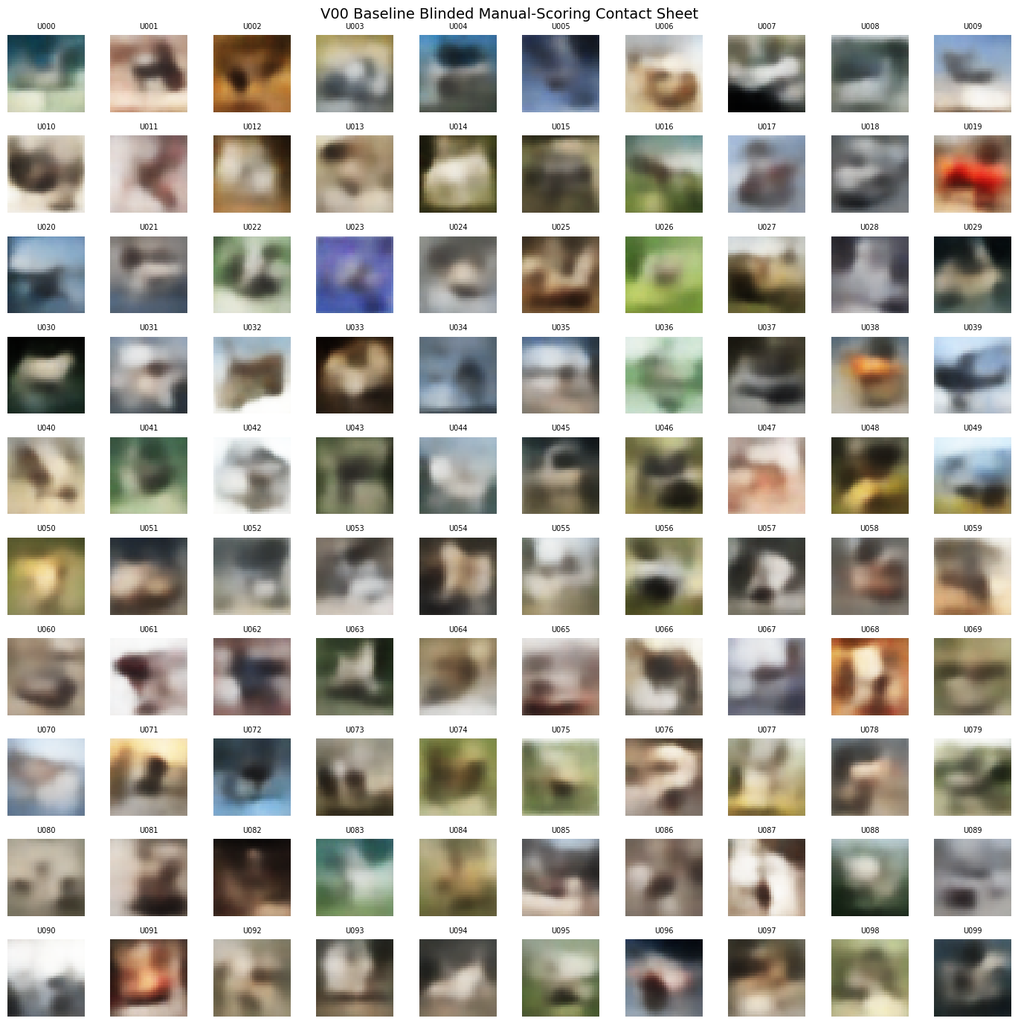

```
V00 baseline blind manual-scoring materials created.
Contact sheet: artifacts\vae\architecture_screen\V00_baseline_manual_scoring\V00_baseline_blind_manual_scoring_contact_sheet.png
Single-rater template: artifacts\vae\architecture_screen\V00_baseline_manual_scoring\V00_baseline_blind_manual_scoring_template.csv
Answer key — do not open while scoring: artifacts\vae\architecture_screen\V00_baseline_manual_scoring\V00_baseline_blind_manual_scoring_key_DO_NOT_OPEN_WHILE_SCORING.csv
Images curated or selectively removed: No
Number of development raters required: 1
Requested-class scoring applicable: No
Official test-set usage: None
```

```python
V00_BASELINE_MANUAL_SAMPLE_COUNT = 100
V00_BASELINE_MANUAL_LATENT_SEED = 1201
V00_BASELINE_MANUAL_SHUFFLE_SEED = (
    SEED + 200
)

v00_baseline_manual_dir = (
    baseline_screen_root
    / "V00_baseline_manual_scoring"
)
v00_baseline_manual_dir.mkdir(
    parents=True,
    exist_ok=True
)

v00_baseline_manual_latents = (
    make_vae_fid_latents(
        sample_count=(
            V00_BASELINE_MANUAL_SAMPLE_COUNT
        ),
        latent_dim=(
            BASELINE_SCREEN_LATENT_DIM
        ),
        seed=(
            V00_BASELINE_MANUAL_LATENT_SEED
        )
    ).numpy()
)

v00_baseline_manual_images = (
    v00_fid_decoder(
        v00_baseline_manual_latents,
        training=False
    ).numpy()
)
v00_baseline_manual_images = np.clip(
    v00_baseline_manual_images,
    0.0,
    1.0
)
v00_baseline_manual_images_uint8 = (
    np.rint(
        v00_baseline_manual_images
        * 255.0
    ).astype(np.uint8)
)

assert (
    v00_baseline_manual_latents.shape
    == (
        V00_BASELINE_MANUAL_SAMPLE_COUNT,
        BASELINE_SCREEN_LATENT_DIM
    )
)
assert (
    v00_baseline_manual_images_uint8.shape
    == (
        V00_BASELINE_MANUAL_SAMPLE_COUNT,
        32,
        32,
        3
    )
)
assert (
    v00_baseline_manual_images_uint8.dtype
    == np.uint8
)

v00_baseline_manual_latents_path = (
    v00_baseline_manual_dir
    / "V00_baseline_manual_latents.npy"
)
v00_baseline_manual_images_path = (
    v00_baseline_manual_dir
    / "V00_baseline_manual_images_uint8.npy"
)

np.save(
    v00_baseline_manual_latents_path,
    v00_baseline_manual_latents
)
np.save(
    v00_baseline_manual_images_path,
    v00_baseline_manual_images_uint8
)

v00_manual_blind_rng = (
    np.random.default_rng(
        V00_BASELINE_MANUAL_SHUFFLE_SEED
    )
)
v00_manual_blind_permutation = (
    v00_manual_blind_rng.permutation(
        V00_BASELINE_MANUAL_SAMPLE_COUNT
    )
)
v00_manual_blind_ids = np.array([
    f"U{index:03d}"
    for index in range(
        V00_BASELINE_MANUAL_SAMPLE_COUNT
    )
])
v00_manual_blind_images = (
    v00_baseline_manual_images_uint8[
        v00_manual_blind_permutation
    ]
)

fig, axes = plt.subplots(
    10,
    10,
    figsize=(14, 14)
)

for blind_position, axis in enumerate(
    axes.flat
):
    axis.imshow(
        v00_manual_blind_images[
            blind_position
        ]
    )
    axis.set_title(
        v00_manual_blind_ids[
            blind_position
        ],
        fontsize=7
    )
    axis.axis("off")

fig.suptitle(
    "V00 Baseline Blinded Manual-Scoring "
    "Contact Sheet",
    fontsize=14
)
plt.tight_layout()

v00_baseline_contact_sheet_path = (
    v00_baseline_manual_dir
    / (
        "V00_baseline_blind_manual_"
        "scoring_contact_sheet.png"
    )
)
plt.savefig(
    v00_baseline_contact_sheet_path,
    dpi=150,
    bbox_inches="tight"
)
plt.show()

v00_baseline_manual_template_df = (
    pd.DataFrame({
        "blind_id": (
            v00_manual_blind_ids
        ),
        "rater": "",
        (
            "quality_rating_"
            "clear_marginal_nonsense"
        ): "",
        "perceived_class": "",
        (
            "confidence_"
            "low_medium_high"
        ): "",
        "note": ""
    })
)

v00_baseline_manual_key_df = (
    pd.DataFrame({
        "blind_id": (
            v00_manual_blind_ids
        ),
        "sample_array_index": (
            v00_manual_blind_permutation
        ),
        "latent_row_index": (
            v00_manual_blind_permutation
        ),
        "latent_seed": (
            V00_BASELINE_MANUAL_LATENT_SEED
        ),
        "requested_class": (
            "Not applicable - "
            "unconditional VAE"
        )
    })
)

v00_baseline_manual_template_path = (
    v00_baseline_manual_dir
    / (
        "V00_baseline_blind_manual_"
        "scoring_template.csv"
    )
)
v00_baseline_manual_key_path = (
    v00_baseline_manual_dir
    / (
        "V00_baseline_blind_manual_"
        "scoring_key_DO_NOT_OPEN_"
        "WHILE_SCORING.csv"
    )
)

v00_baseline_manual_template_df.to_csv(
    v00_baseline_manual_template_path,
    index=False
)
v00_baseline_manual_key_df.to_csv(
    v00_baseline_manual_key_path,
    index=False
)

print(
    "V00 baseline blind manual-scoring "
    "materials created."
)
print(
    "Contact sheet: "
    f"{v00_baseline_contact_sheet_path}"
)
print(
    "Single-rater template: "
    f"{v00_baseline_manual_template_path}"
)
print(
    "Answer key - do not open while scoring: "
    f"{v00_baseline_manual_key_path}"
)
print(
    "Images curated or selectively removed: No"
)
print("Number of development raters required: 1")
print("Requested-class scoring applicable: No")
print("Official test-set usage: None")
```

#### 5.6.13 Completed V00 Blind-Scoring Validation

Aniq completed the V00 baseline ratings using the randomly ordered contact sheet. The completed ratings are retained under a V00-specific identity so that they cannot be confused with the later final-model evaluation.

The next cell validates the raw file before calculating any summary. It requires:

- exactly 100 rows;
- every blind ID from `U000` to `U099` exactly once;
- one non-empty rater;
- no blank required fields;
- only the permitted quality, perceived-class and confidence values; and
- no requested-class calculation, because V00 is unconditional.

```python
v00_completed_manual_path = (
    baseline_screen_root
    / "V00_baseline_manual_scoring"
    / (
        "V00_baseline_blind_manual_"
        "scoring_completed_Aniq.csv"
    )
)
assert v00_completed_manual_path.exists(), (
    "Completed V00 manual-scoring file "
    f"not found: {v00_completed_manual_path}"
)

v00_completed_manual_df = pd.read_csv(
    v00_completed_manual_path,
    dtype=str,
    keep_default_na=False
)

v00_required_manual_columns = [
    "blind_id",
    "rater",
    (
        "quality_rating_"
        "clear_marginal_nonsense"
    ),
    "perceived_class",
    (
        "confidence_"
        "low_medium_high"
    ),
    "note"
]

assert list(
    v00_completed_manual_df.columns
) == v00_required_manual_columns, (
    "Unexpected V00 manual-scoring columns."
)
assert len(v00_completed_manual_df) == 100

v00_expected_blind_ids = {
    f"U{index:03d}"
    for index in range(100)
}
v00_actual_blind_ids = set(
    v00_completed_manual_df[
        "blind_id"
    ]
)

assert (
    v00_actual_blind_ids
    == v00_expected_blind_ids
)
assert (
    v00_completed_manual_df[
        "blind_id"
    ].is_unique
)

v00_required_non_empty_columns = [
    "blind_id",
    "rater",
    (
        "quality_rating_"
        "clear_marginal_nonsense"
    ),
    "perceived_class",
    (
        "confidence_"
        "low_medium_high"
    )
]

for required_column in (
    v00_required_non_empty_columns
):
    assert (
        v00_completed_manual_df[
            required_column
        ].str.strip() != ""
    ).all(), (
        "Blank required values found in "
        f"{required_column}."
    )

v00_allowed_quality_values = {
    "Clear",
    "Marginal",
    "Nonsense"
}
v00_allowed_perceived_classes = set(
    class_names
) | {"Unclear"}
v00_allowed_confidence_values = {
    "Low",
    "Medium",
    "High"
}

assert set(
    v00_completed_manual_df[
        (
            "quality_rating_"
            "clear_marginal_nonsense"
        )
    ]
).issubset(
    v00_allowed_quality_values
)
assert set(
    v00_completed_manual_df[
        "perceived_class"
    ]
).issubset(
    v00_allowed_perceived_classes
)
assert set(
    v00_completed_manual_df[
        (
            "confidence_"
            "low_medium_high"
        )
    ]
).issubset(
    v00_allowed_confidence_values
)
assert (
    v00_completed_manual_df[
        "rater"
    ].nunique() == 1
)


def ordered_count_summary(
    series,
    ordered_categories,
    category_label
):
    counts = (
        series.value_counts()
        .reindex(
            ordered_categories,
            fill_value=0
        )
    )

    return pd.DataFrame({
        category_label: counts.index,
        "count": counts.values,
        "percentage": (
            counts.values
            / len(series)
            * 100.0
        )
    })


v00_quality_summary_df = (
    ordered_count_summary(
        v00_completed_manual_df[
            (
                "quality_rating_"
                "clear_marginal_nonsense"
            )
        ],
        [
            "Clear",
            "Marginal",
            "Nonsense"
        ],
        "quality_rating"
    )
)

v00_confidence_summary_df = (
    ordered_count_summary(
        v00_completed_manual_df[
            (
                "confidence_"
                "low_medium_high"
            )
        ],
        [
            "High",
            "Medium",
            "Low"
        ],
        "confidence"
    )
)

v00_perceived_class_summary_df = (
    ordered_count_summary(
        v00_completed_manual_df[
            "perceived_class"
        ],
        [
            *class_names,
            "Unclear"
        ],
        "perceived_class"
    )
)

v00_nonsense_ids = (
    v00_completed_manual_df.loc[
        v00_completed_manual_df[
            (
                "quality_rating_"
                "clear_marginal_nonsense"
            )
        ] == "Nonsense",
        "blind_id"
    ].tolist()
)

v00_quality_summary_path = (
    v00_baseline_manual_dir
    / "V00_baseline_manual_quality_summary.csv"
)
v00_confidence_summary_path = (
    v00_baseline_manual_dir
    / (
        "V00_baseline_manual_"
        "confidence_summary.csv"
    )
)
v00_perceived_class_summary_path = (
    v00_baseline_manual_dir
    / (
        "V00_baseline_manual_"
        "perceived_class_summary.csv"
    )
)
v00_quality_summary_df.to_csv(
    v00_quality_summary_path,
    index=False
)
v00_confidence_summary_df.to_csv(
    v00_confidence_summary_path,
    index=False
)
v00_perceived_class_summary_df.to_csv(
    v00_perceived_class_summary_path,
    index=False
)
assert (
    v00_quality_summary_df[
        "count"
    ].sum() == 100
)
assert (
    v00_confidence_summary_df[
        "count"
    ].sum() == 100
)
assert (
    v00_perceived_class_summary_df[
        "count"
    ].sum() == 100
)
assert (
    len(v00_nonsense_ids) == 40
)

print(
    "V00 completed blind-scoring file "
    "passed all validation checks."
)
print(
    "Rater: "
    f"{v00_completed_manual_df['rater'].iloc[0]}"
)

print("\nV00 quality summary:")
display(v00_quality_summary_df)

print("\nV00 confidence summary:")
display(v00_confidence_summary_df)

print("\nV00 perceived-class summary:")
display(v00_perceived_class_summary_df)

print(
    "\nV00 Nonsense IDs:"
)
print(", ".join(v00_nonsense_ids))

print(
    "\nV00 quality summary saved to: "
    f"{v00_quality_summary_path}"
)
print(
    "V00 confidence summary saved to: "
    f"{v00_confidence_summary_path}"
)
print(
    "V00 perceived-class summary saved to: "
    f"{v00_perceived_class_summary_path}"
)
print(
    "Requested-class match calculated "
    "for V00: No; V00 is unconditional."
)
print("Official test-set usage: None")
```

```
V00 completed blind-scoring file passed all validation checks.
Rater: Aniq

V00 quality summary:
```

|  | quality_rating | count | percentage |
| --- | --- | --- | --- |
| 0 | Clear | 0 | 0.0 |
| 1 | Marginal | 60 | 60.0 |
| 2 | Nonsense | 40 | 40.0 |

```
V00 confidence summary:
```

|  | confidence | count | percentage |
| --- | --- | --- | --- |
| 0 | High | 0 | 0.0 |
| 1 | Medium | 11 | 11.0 |
| 2 | Low | 89 | 89.0 |

```
V00 perceived-class summary:
```

|  | perceived_class | count | percentage |
| --- | --- | --- | --- |
| 0 | Airplane | 7 | 7.0 |
| 1 | Automobile | 7 | 7.0 |
| 2 | Bird | 6 | 6.0 |
| 3 | Cat | 7 | 7.0 |
| 4 | Deer | 6 | 6.0 |
| 5 | Dog | 4 | 4.0 |
| 6 | Frog | 7 | 7.0 |
| 7 | Horse | 2 | 2.0 |
| 8 | Ship | 6 | 6.0 |
| 9 | Truck | 8 | 8.0 |
| 10 | Unclear | 40 | 40.0 |

```
V00 Nonsense IDs:
U005, U010, U013, U015, U016, U017, U021, U026, U028, U031, U032, U033, U036, U037, U039, U040, U046, U050, U055, U059, U061, U063, U064, U066, U067, U080, U081, U082, U083, U085, U086, U088, U091, U092, U093, U094, U095, U096, U097, U099

V00 quality summary saved to: artifacts\vae\architecture_screen\V00_baseline_manual_scoring\V00_baseline_manual_quality_summary.csv
V00 confidence summary saved to: artifacts\vae\architecture_screen\V00_baseline_manual_scoring\V00_baseline_manual_confidence_summary.csv
V00 perceived-class summary saved to: artifacts\vae\architecture_screen\V00_baseline_manual_scoring\V00_baseline_manual_perceived_class_summary.csv
Requested-class match calculated for V00: No; V00 is unconditional.
Official test-set usage: None
```

#### 5.6.14 V00 Blind Manual-Evaluation Findings

The corrected V00 file passed all completeness and validity checks. Aniq rated all 100 randomly ordered, uncurated images, and every ID from `U000` to `U099` appeared exactly once.

##### Image-quality ratings

| Rating | Count | Percentage |
| --- | --- | --- |
| Clear | 0 | 0% |
| Marginal | 60 | 60% |
| Nonsense | 40 | 40% |
| **Total** | **100** | **100%** |

The 60 Marginal images contained enough colour, layout or silhouette information for a tentative class perception, but none was sufficiently defined for a Clear rating. The 40 Nonsense images were recorded as indistinct blobs or artefacts and were consistently assigned `Unclear`.

This is stronger evidence of V00's baseline weakness than the favourable architecture-screen ranking alone. V00 was the best of the three baselines, but **40% of its uncurated samples still lacked a coherent object or scene**.

##### Confidence ratings

| Confidence | Count | Percentage |
| --- | --- | --- |
| High | 0 | 0% |
| Medium | 11 | 11% |
| Low | 89 | 89% |
| **Total** | **100** | **100%** |

No image received High confidence. The 89% Low-confidence rate confirms that even when a class name could be proposed, the interpretation was usually uncertain.

##### Perceived-class distribution

| Perceived class | Count | Percentage |
| --- | --- | --- |
| Airplane | 7 | 7% |
| Automobile | 7 | 7% |
| Bird | 6 | 6% |
| Cat | 7 | 7% |
| Deer | 6 | 6% |
| Dog | 4 | 4% |
| Frog | 7 | 7% |
| Horse | 2 | 2% |
| Ship | 6 | 6% |
| Truck | 8 | 8% |
| Unclear | 40 | 40% |
| **Total** | **100** | **100%** |

All ten class names appeared among the 60 non-`Unclear` perceptions, so the rater did not interpret every plausible image as one dominant category. However, these are subjective perceptions rather than correctness results. V00 is unconditional and has no requested label, so there is no valid answer key for perceived class and no requested-class accuracy can be calculated.

##### Baseline role in the final evaluation

These V00 results establish the human-evaluation reference before the final model is considered. They are not compared with an intermediate experiment in this section. Section 12 derives the final V00-versus-V04 comparison directly from the two completed scoring files after V04 has been selected.

The baseline conclusion is deliberately limited: V00 was the strongest architecture-screen candidate, but its 0% Clear rate, 40% Nonsense rate and 89% Low-confidence rate show substantial remaining weakness. These results motivate systematic improvement without prematurely declaring any intermediate experiment to be the final VAE.

## 6. Controlled Improvement 1 - V01 Lower KL Weight

### 6.1 Decision and Hypothesis

The first improvement changes only the KL-divergence weight:

**Controlled change:** β: 1.0 → 0.5

V00’s reconstructions and generations preserve global colour and layout but lose edges and fine structure. The KL term is clearly active rather than collapsed. Reducing `β` should relax the pressure forcing every posterior towards the standard-normal prior, allowing the encoder to retain more image-specific information.

**Hypothesis:** V01 will reduce reconstruction MSE and MAE, increase PSNR, and may improve contrast or edge strength by preserving more detail.

**Risk:** weaker KL regularisation may create a less organised latent space. Reconstructions may sharpen while samples drawn from the standard-normal prior become less coherent. V01 is successful only if the reconstruction benefit is not outweighed by worse fixed-latent generation.

| Factor | V00 | V01 |
| --- | --- | --- |
| Main change | Baseline | `β = 0.5` |
| Architecture | Same | Same |
| Latent dimension | 64 | 64 |
| Reconstruction loss | BCE sum | BCE sum |
| Optimiser | Adam | Adam |
| Learning rate | 0.001 | 0.001 |
| Batch size | 128 | 128 |
| Epochs | 50 | 50 |
| Data augmentation | None | None |
| Training images | 50,000 | 50,000 |
| Test-set usage | None | None |
| Seed | 42 | 42 |

Latent dimension and architecture remain unchanged because changing them simultaneously would prevent attribution. They remain valid later experiments if lowering `β` does not address the blur.

```python
# Build a fresh V01 architecture identical to V00.
V01_EXPERIMENT_ID = "V01"
V01_LATENT_DIM = LATENT_DIM
V01_BETA = 0.5

# Reset all supported random generators before
# fresh model initialisation.
tf.keras.utils.set_random_seed(SEED)

encoder_inputs_v01 = keras.Input(
    shape=INPUT_SHAPE,
    name="V01_encoder_input"
)

x_v01 = layers.Conv2D(
    filters=32,
    kernel_size=3,
    strides=2,
    padding="same",
    activation="relu",
    name="V01_encoder_conv_1"
)(encoder_inputs_v01)

x_v01 = layers.Conv2D(
    filters=64,
    kernel_size=3,
    strides=2,
    padding="same",
    activation="relu",
    name="V01_encoder_conv_2"
)(x_v01)

x_v01 = layers.Conv2D(
    filters=128,
    kernel_size=3,
    strides=2,
    padding="same",
    activation="relu",
    name="V01_encoder_conv_3"
)(x_v01)

x_v01 = layers.Flatten(
    name="V01_encoder_flatten"
)(x_v01)

x_v01 = layers.Dense(
    units=256,
    activation="relu",
    name="V01_encoder_dense"
)(x_v01)

z_mean_v01 = layers.Dense(
    units=V01_LATENT_DIM,
    name="V01_z_mean"
)(x_v01)

z_log_var_v01 = layers.Dense(
    units=V01_LATENT_DIM,
    name="V01_z_log_var"
)(x_v01)

z_v01 = Sampling(
    name="V01_z_sampling"
)([
    z_mean_v01,
    z_log_var_v01
])

encoder_v01 = keras.Model(
    inputs=encoder_inputs_v01,
    outputs=[
        z_mean_v01,
        z_log_var_v01,
        z_v01
    ],
    name="V01_encoder"
)

decoder_inputs_v01 = keras.Input(
    shape=(V01_LATENT_DIM,),
    name="V01_decoder_input"
)

y_v01 = layers.Dense(
    units=4 * 4 * 128,
    activation="relu",
    name="V01_decoder_dense"
)(decoder_inputs_v01)

y_v01 = layers.Reshape(
    target_shape=(4, 4, 128),
    name="V01_decoder_reshape"
)(y_v01)

y_v01 = layers.Conv2DTranspose(
    filters=128,
    kernel_size=3,
    strides=2,
    padding="same",
    activation="relu",
    name="V01_decoder_deconv_1"
)(y_v01)

y_v01 = layers.Conv2DTranspose(
    filters=64,
    kernel_size=3,
    strides=2,
    padding="same",
    activation="relu",
    name="V01_decoder_deconv_2"
)(y_v01)

y_v01 = layers.Conv2DTranspose(
    filters=32,
    kernel_size=3,
    strides=2,
    padding="same",
    activation="relu",
    name="V01_decoder_deconv_3"
)(y_v01)

decoder_outputs_v01 = layers.Conv2D(
    filters=3,
    kernel_size=3,
    strides=1,
    padding="same",
    activation="sigmoid",
    name="V01_decoder_output"
)(y_v01)

decoder_v01 = keras.Model(
    inputs=decoder_inputs_v01,
    outputs=decoder_outputs_v01,
    name="V01_decoder"
)

# Architecture equality checks: beta is not part
# of either component's parameter count.
assert V01_LATENT_DIM == LATENT_DIM
assert (
    encoder_v01.count_params()
    == encoder.count_params()
)
assert (
    decoder_v01.count_params()
    == decoder.count_params()
)

print(
    f"Experiment ID: "
    f"{V01_EXPERIMENT_ID}"
)
print(
    f"Main change: beta "
    f"{BETA} -> {V01_BETA}"
)
print(
    "Encoder parameters match V00: "
    f"{encoder_v01.count_params():,}"
)
print(
    "Decoder parameters match V00: "
    f"{decoder_v01.count_params():,}"
)
print(
    "Official test-set usage: None"
)

encoder_v01.summary()
decoder_v01.summary()
```

```
Experiment ID: V01
Main change: beta 1.0 -> 0.5
Encoder parameters match V00: 650,688
Decoder parameters match V00: 373,827
Official test-set usage: None
Model: "V01_encoder"
__________________________________________________________________________________________________
 Layer (type)                   Output Shape         Param #     Connected to
==================================================================================================
 V01_encoder_input (InputLayer)  [(None, 32, 32, 3)]  0          []

 V01_encoder_conv_1 (Conv2D)    (None, 16, 16, 32)   896         ['V01_encoder_input[0][0]']

 V01_encoder_conv_2 (Conv2D)    (None, 8, 8, 64)     18496       ['V01_encoder_conv_1[0][0]']

 V01_encoder_conv_3 (Conv2D)    (None, 4, 4, 128)    73856       ['V01_encoder_conv_2[0][0]']

 V01_encoder_flatten (Flatten)  (None, 2048)         0           ['V01_encoder_conv_3[0][0]']

 V01_encoder_dense (Dense)      (None, 256)          524544      ['V01_encoder_flatten[0][0]']

 V01_z_mean (Dense)             (None, 64)           16448       ['V01_encoder_dense[0][0]']

 V01_z_log_var (Dense)          (None, 64)           16448       ['V01_encoder_dense[0][0]']

 V01_z_sampling (Sampling)      (None, 64)           0           ['V01_z_mean[0][0]',
                                                                  'V01_z_log_var[0][0]']

==================================================================================================
Total params: 650,688
Trainable params: 650,688
Non-trainable params: 0
__________________________________________________________________________________________________
Model: "V01_decoder"
_________________________________________________________________
 Layer (type)                Output Shape              Param #
=================================================================
 V01_decoder_input (InputLay  [(None, 64)]             0
 er)

 V01_decoder_dense (Dense)   (None, 2048)              133120

 V01_decoder_reshape (Reshap  (None, 4, 4, 128)        0
 e)

 V01_decoder_deconv_1 (Conv2  (None, 8, 8, 128)        147584
 DTranspose)

 V01_decoder_deconv_2 (Conv2  (None, 16, 16, 64)       73792
 DTranspose)

 V01_decoder_deconv_3 (Conv2  (None, 32, 32, 32)       18464
 DTranspose)

 V01_decoder_output (Conv2D)  (None, 32, 32, 3)        867

=================================================================
Total params: 373,827
Trainable params: 373,827
Non-trainable params: 0
_________________________________________________________________
```

### 6.2 V01 Training Configuration

V01 is trained from freshly initialised weights rather than continuing from V00. It uses the same optimiser, learning rate, batch size, shuffled 50-epoch budget, milestone epochs, and unaugmented training tensor.

Fixed checkpoints are again saved at epochs 1, 10, 25, 40, and 50. These are diagnostic snapshots, not “best model” claims. Total, reconstruction, and KL-divergence losses remain separate so the effect of reducing `β` can be measured directly.

```python
# Create, train, and save the controlled V01 model.
V01_LEARNING_RATE = LEARNING_RATE
V01_BATCH_SIZE = BATCH_SIZE
V01_EPOCHS = EPOCHS
V01_MILESTONE_EPOCHS = [
    1,
    10,
    25,
    40,
    V01_EPOCHS
]

vae_v01 = VAE(
    encoder=encoder_v01,
    decoder=decoder_v01,
    beta=V01_BETA,
    name="V01_vae"
)

vae_v01.compile(
    optimizer=keras.optimizers.Adam(
        learning_rate=V01_LEARNING_RATE
    )
)

# Build the subclass before checkpoint saving.
_ = vae_v01(
    tf.zeros(
        shape=(1,) + INPUT_SHAPE,
        dtype=tf.float32
    ),
    training=False
)

v01_artifact_dir = (
    Path("artifacts") / "vae" / "V01"
)
v01_checkpoint_dir = (
    v01_artifact_dir / "checkpoints"
)
v01_weight_dir = (
    v01_artifact_dir / "weights"
)

for directory in [
    v01_artifact_dir,
    v01_checkpoint_dir,
    v01_weight_dir
]:
    directory.mkdir(
        parents=True,
        exist_ok=True
    )

assert x_train_vae.shape == (
    50000,
    32,
    32,
    3
)
assert x_train_vae.dtype == np.float32
assert np.isfinite(
    x_train_vae
).all()


class V01MilestoneWeightsSaver(
    keras.callbacks.Callback
):
    """Saves fixed V01 epoch checkpoints."""

    def __init__(
        self,
        checkpoint_dir,
        milestone_epochs
    ):
        super().__init__()

        self.checkpoint_dir = Path(
            checkpoint_dir
        )
        self.milestone_epochs = set(
            milestone_epochs
        )
        self.saved_paths = []

    def on_epoch_end(
        self,
        epoch,
        logs=None
    ):
        completed_epoch = epoch + 1

        if (
            completed_epoch
            in self.milestone_epochs
        ):
            checkpoint_path = (
                self.checkpoint_dir
                / (
                    "V01_epoch_"
                    f"{completed_epoch:03d}"
                    ".weights.h5"
                )
            )

            self.model.save_weights(
                str(checkpoint_path)
            )
            self.saved_paths.append(
                checkpoint_path
            )

            print(
                "\nSaved fixed V01 milestone "
                f"checkpoint: {checkpoint_path}"
            )


v01_milestone_saver = (
    V01MilestoneWeightsSaver(
        checkpoint_dir=(
            v01_checkpoint_dir
        ),
        milestone_epochs=(
            V01_MILESTONE_EPOCHS
        )
    )
)

print(
    "Starting V01 controlled training."
)
print(
    f"Main change: beta "
    f"{BETA} -> {V01_BETA}"
)
print(
    f"Epochs: {V01_EPOCHS}"
)
print(
    f"Batch size: {V01_BATCH_SIZE}"
)
print(
    f"Learning rate: "
    f"{V01_LEARNING_RATE}"
)
print(
    "Data augmentation: None"
)
print(
    "Official test-set usage: None"
)

v01_training_start_time = (
    time.perf_counter()
)

vae_v01_history = vae_v01.fit(
    x=x_train_vae,
    epochs=V01_EPOCHS,
    batch_size=V01_BATCH_SIZE,
    shuffle=True,
    callbacks=[
        keras.callbacks.TerminateOnNaN(),
        v01_milestone_saver
    ],
    verbose=2
)

v01_training_duration_seconds = (
    time.perf_counter()
    - v01_training_start_time
)

v01_history_df = pd.DataFrame(
    vae_v01_history.history
)
v01_history_df.index = np.arange(
    1,
    len(v01_history_df) + 1
)
v01_history_df.index.name = "epoch"

v01_history_path = (
    v01_artifact_dir
    / "V01_training_history.csv"
)
v01_history_df.to_csv(
    v01_history_path
)

v01_final_vae_weights_path = (
    v01_weight_dir
    / "V01_vae_final.weights.h5"
)
v01_final_encoder_weights_path = (
    v01_weight_dir
    / "V01_encoder_final.weights.h5"
)
v01_final_decoder_weights_path = (
    v01_weight_dir
    / "V01_decoder_final.weights.h5"
)

vae_v01.save_weights(
    str(v01_final_vae_weights_path)
)
encoder_v01.save_weights(
    str(v01_final_encoder_weights_path)
)
decoder_v01.save_weights(
    str(v01_final_decoder_weights_path)
)

v01_training_record = {
    "experiment_id": (
        V01_EXPERIMENT_ID
    ),
    "main_change": (
        "beta 1.0 to 0.5"
    ),
    "input_shape": list(
        INPUT_SHAPE
    ),
    "latent_dimension": (
        V01_LATENT_DIM
    ),
    "beta": V01_BETA,
    "optimizer": "Adam",
    "learning_rate": (
        V01_LEARNING_RATE
    ),
    "batch_size": V01_BATCH_SIZE,
    "epochs_requested": V01_EPOCHS,
    "epochs_completed": len(
        v01_history_df
    ),
    "data_augmentation": None,
    "validation_split": None,
    "test_set_used": False,
    "seed": SEED,
    "milestone_epochs": (
        V01_MILESTONE_EPOCHS
    ),
    "training_duration_seconds": (
        v01_training_duration_seconds
    )
}

v01_training_record_path = (
    v01_artifact_dir
    / "V01_training_record.json"
)

with v01_training_record_path.open(
    "w",
    encoding="utf-8"
) as record_file:
    json.dump(
        v01_training_record,
        record_file,
        indent=4
    )

print(
    "\nV01 controlled training completed."
)
print(
    "Training duration: "
    f"{v01_training_duration_seconds / 60:.2f} "
    "minutes"
)
print(
    f"History saved to: "
    f"{v01_history_path}"
)
print(
    "Training record saved to: "
    f"{v01_training_record_path}"
)
print(
    "Final VAE weights saved to: "
    f"{v01_final_vae_weights_path}"
)
print(
    "Final encoder weights saved to: "
    f"{v01_final_encoder_weights_path}"
)
print(
    "Final decoder weights saved to: "
    f"{v01_final_decoder_weights_path}"
)
```

```
Starting V01 controlled training.
Main change: beta 1.0 -> 0.5
Epochs: 50
Batch size: 128
Learning rate: 0.001
Data augmentation: None
Official test-set usage: None

Saved fixed V01 milestone checkpoint: artifacts\vae\V01\checkpoints\V01_epoch_001.weights.h5
391/391 - 14s - loss: 1956.5872 - total_loss: 1956.5872 - reconstruction_loss: 1943.4973 - kl_loss: 26.1794 - 14s/epoch - 35ms/step
391/391 - 11s - loss: 1853.9979 - total_loss: 1853.9979 - reconstruction_loss: 1833.9043 - kl_loss: 40.1884 - 11s/epoch - 28ms/step
391/391 - 11s - loss: 1826.7480 - total_loss: 1826.7480 - reconstruction_loss: 1804.3867 - kl_loss: 44.7219 - 11s/epoch - 28ms/step
391/391 - 11s - loss: 1817.3147 - total_loss: 1817.3147 - reconstruction_loss: 1793.8927 - kl_loss: 46.8423 - 11s/epoch - 28ms/step
391/391 - 11s - loss: 1812.1575 - total_loss: 1812.1575 - reconstruction_loss: 1788.0129 - kl_loss: 48.2895 - 11s/epoch - 28ms/step
391/391 - 11s - loss: 1809.0476 - total_loss: 1809.0476 - reconstruction_loss: 1784.3750 - kl_loss: 49.3462 - 11s/epoch - 28ms/step
391/391 - 11s - loss: 1806.0135 - total_loss: 1806.0135 - reconstruction_loss: 1780.4973 - kl_loss: 51.0334 - 11s/epoch - 29ms/step
391/391 - 11s - loss: 1804.3301 - total_loss: 1804.3301 - reconstruction_loss: 1778.4355 - kl_loss: 51.7892 - 11s/epoch - 29ms/step
391/391 - 11s - loss: 1802.9567 - total_loss: 1802.9567 - reconstruction_loss: 1776.9036 - kl_loss: 52.1081 - 11s/epoch - 29ms/step

Saved fixed V01 milestone checkpoint: artifacts\vae\V01\checkpoints\V01_epoch_010.weights.h5
391/391 - 11s - loss: 1801.6832 - total_loss: 1801.6832 - reconstruction_loss: 1775.4148 - kl_loss: 52.5378 - 11s/epoch - 29ms/step
391/391 - 11s - loss: 1800.4567 - total_loss: 1800.4567 - reconstruction_loss: 1773.7015 - kl_loss: 53.5093 - 11s/epoch - 28ms/step
391/391 - 11s - loss: 1799.2135 - total_loss: 1799.2135 - reconstruction_loss: 1772.1306 - kl_loss: 54.1677 - 11s/epoch - 28ms/step
391/391 - 11s - loss: 1798.3538 - total_loss: 1798.3538 - reconstruction_loss: 1771.0118 - kl_loss: 54.6842 - 11s/epoch - 28ms/step
391/391 - 11s - loss: 1797.6677 - total_loss: 1797.6677 - reconstruction_loss: 1770.0785 - kl_loss: 55.1767 - 11s/epoch - 28ms/step
391/391 - 13s - loss: 1797.1544 - total_loss: 1797.1544 - reconstruction_loss: 1769.3788 - kl_loss: 55.5527 - 13s/epoch - 32ms/step
391/391 - 11s - loss: 1796.3673 - total_loss: 1796.3673 - reconstruction_loss: 1768.4169 - kl_loss: 55.8987 - 11s/epoch - 28ms/step
391/391 - 11s - loss: 1796.0288 - total_loss: 1796.0288 - reconstruction_loss: 1767.9709 - kl_loss: 56.1161 - 11s/epoch - 28ms/step
391/391 - 11s - loss: 1795.5897 - total_loss: 1795.5897 - reconstruction_loss: 1767.3611 - kl_loss: 56.4577 - 11s/epoch - 28ms/step
391/391 - 11s - loss: 1795.2222 - total_loss: 1795.2222 - reconstruction_loss: 1766.8600 - kl_loss: 56.7233 - 11s/epoch - 28ms/step
391/391 - 11s - loss: 1794.5975 - total_loss: 1794.5975 - reconstruction_loss: 1766.0774 - kl_loss: 57.0391 - 11s/epoch - 28ms/step
391/391 - 11s - loss: 1794.3025 - total_loss: 1794.3025 - reconstruction_loss: 1765.6439 - kl_loss: 57.3156 - 11s/epoch - 29ms/step
391/391 - 11s - loss: 1793.9237 - total_loss: 1793.9237 - reconstruction_loss: 1765.2258 - kl_loss: 57.3951 - 11s/epoch - 29ms/step
391/391 - 11s - loss: 1793.5713 - total_loss: 1793.5713 - reconstruction_loss: 1764.8285 - kl_loss: 57.4865 - 11s/epoch - 28ms/step
391/391 - 11s - loss: 1793.4001 - total_loss: 1793.4001 - reconstruction_loss: 1764.5841 - kl_loss: 57.6303 - 11s/epoch - 28ms/step

Saved fixed V01 milestone checkpoint: artifacts\vae\V01\checkpoints\V01_epoch_025.weights.h5
391/391 - 12s - loss: 1793.1693 - total_loss: 1793.1693 - reconstruction_loss: 1764.2734 - kl_loss: 57.7893 - 12s/epoch - 30ms/step
391/391 - 11s - loss: 1793.0728 - total_loss: 1793.0728 - reconstruction_loss: 1764.1538 - kl_loss: 57.8366 - 11s/epoch - 29ms/step
391/391 - 11s - loss: 1792.7540 - total_loss: 1792.7540 - reconstruction_loss: 1763.7268 - kl_loss: 58.0552 - 11s/epoch - 28ms/step
```

[output cut: 20 more lines]

```
391/391 - 11s - loss: 1789.6580 - total_loss: 1789.6580 - reconstruction_loss: 1759.3955 - kl_loss: 60.5254 - 11s/epoch - 29ms/step
391/391 - 11s - loss: 1789.6121 - total_loss: 1789.6121 - reconstruction_loss: 1759.3196 - kl_loss: 60.5859 - 11s/epoch - 29ms/step
391/391 - 11s - loss: 1789.4408 - total_loss: 1789.4408 - reconstruction_loss: 1759.0889 - kl_loss: 60.7042 - 11s/epoch - 28ms/step
391/391 - 11s - loss: 1789.3022 - total_loss: 1789.3022 - reconstruction_loss: 1758.8958 - kl_loss: 60.8132 - 11s/epoch - 28ms/step

Saved fixed V01 milestone checkpoint: artifacts\vae\V01\checkpoints\V01_epoch_050.weights.h5
391/391 - 11s - loss: 1789.2054 - total_loss: 1789.2054 - reconstruction_loss: 1758.7421 - kl_loss: 60.9300 - 11s/epoch - 28ms/step

V01 controlled training completed.
Training duration: 9.38 minutes
History saved to: artifacts\vae\V01\V01_training_history.csv
Training record saved to: artifacts\vae\V01\V01_training_record.json
Final VAE weights saved to: artifacts\vae\V01\weights\V01_vae_final.weights.h5
Final encoder weights saved to: artifacts\vae\V01\weights\V01_encoder_final.weights.h5
Final decoder weights saved to: artifacts\vae\V01\weights\V01_decoder_final.weights.h5
```

### 6.3 Immediate V01 Training Diagnostics

The next cell validates and plots V01’s three loss terms. Interpretation is intentionally deferred until the executed output is available.

The raw total loss cannot be compared directly with V00 because V01 multiplies the KL term by a different `β`. Reconstruction loss, unweighted KL loss, fixed-input reconstruction metrics, and fixed-latent images are required for a fair decision.

```
V01 training-history validation passed.
Recorded epochs: 50

First-epoch V01 losses:
total_loss             1956.5872
reconstruction_loss    1943.4973
kl_loss                  26.1794
Name: 1, dtype: float64

Final-epoch V01 losses:
total_loss             1789.2054
reconstruction_loss    1758.7421
kl_loss                  60.9300
Name: 50, dtype: float64

Last 10 V01 epochs:
```

| epoch | total_loss | reconstruction_loss | kl_loss |
| --- | --- | --- | --- |
| 41 | 1790.2450 | 1760.2010 | 60.0907 |
| 42 | 1790.0347 | 1759.9164 | 60.2355 |
| 43 | 1790.0314 | 1759.8617 | 60.3382 |
| 44 | 1789.8508 | 1759.6926 | 60.3174 |
| 45 | 1789.8232 | 1759.5723 | 60.5024 |
| 46 | 1789.6580 | 1759.3955 | 60.5254 |
| 47 | 1789.6121 | 1759.3196 | 60.5859 |
| 48 | 1789.4408 | 1759.0889 | 60.7042 |
| 49 | 1789.3022 | 1758.8958 | 60.8132 |
| 50 | 1789.2054 | 1758.7421 | 60.9300 |

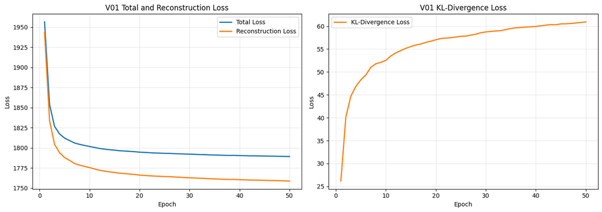

```
V01 training-loss figure saved to: artifacts\vae\V01\V01_training_loss_curves.png
```

```python
# Validate and display the V01 training history.
v01_required_columns = [
    "total_loss",
    "reconstruction_loss",
    "kl_loss"
]

v01_missing_columns = [
    column
    for column in v01_required_columns
    if column not in v01_history_df.columns
]

assert not v01_missing_columns, (
    "Missing V01 history columns: "
    f"{v01_missing_columns}"
)
assert len(v01_history_df) == V01_EPOCHS
assert np.isfinite(
    v01_history_df[
        v01_required_columns
    ].to_numpy()
).all()

print(
    "V01 training-history validation passed."
)
print(
    f"Recorded epochs: "
    f"{len(v01_history_df)}"
)

print("\nFirst-epoch V01 losses:")
print(
    v01_history_df.loc[
        1,
        v01_required_columns
    ].round(4)
)

print("\nFinal-epoch V01 losses:")
print(
    v01_history_df.loc[
        V01_EPOCHS,
        v01_required_columns
    ].round(4)
)

print("\nLast 10 V01 epochs:")
display(
    v01_history_df[
        v01_required_columns
    ].tail(10).round(4)
)

fig, axes = plt.subplots(
    nrows=1,
    ncols=2,
    figsize=(14, 5)
)

axes[0].plot(
    v01_history_df.index,
    v01_history_df["total_loss"],
    label="Total Loss",
    linewidth=2
)
axes[0].plot(
    v01_history_df.index,
    v01_history_df[
        "reconstruction_loss"
    ],
    label="Reconstruction Loss",
    linewidth=2
)
axes[0].set_title(
    "V01 Total and Reconstruction Loss"
)
axes[0].set_xlabel("Epoch")
axes[0].set_ylabel("Loss")
axes[0].grid(alpha=0.3)
axes[0].legend()

axes[1].plot(
    v01_history_df.index,
    v01_history_df["kl_loss"],
    color="tab:orange",
    label="KL-Divergence Loss",
    linewidth=2
)
axes[1].set_title(
    "V01 KL-Divergence Loss"
)
axes[1].set_xlabel("Epoch")
axes[1].set_ylabel("Loss")
axes[1].grid(alpha=0.3)
axes[1].legend()

plt.tight_layout()

v01_training_curve_path = (
    v01_artifact_dir
    / "V01_training_loss_curves.png"
)
plt.savefig(
    v01_training_curve_path,
    dpi=150,
    bbox_inches="tight"
)
plt.show()

print(
    "V01 training-loss figure saved to: "
    f"{v01_training_curve_path}"
)
```

### 6.4 V01 Training Interpretation

V01 completed all 50 epochs successfully in 9.38 minutes. Its encoder and decoder parameter counts exactly matched V00, all losses remained finite, and every planned checkpoint and final weight file was saved.

| Loss term | V01 epoch 1 | V01 epoch 50 | V01 change |
| --- | --- | --- | --- |
| Reconstruction loss | 1943.4973 | 1758.7421 | −184.7552 (−9.51%) |
| Unweighted KL loss | 26.1794 | 60.9300 | +34.7506 (+132.74%) |
| V01 weighted total | 1956.5872 | 1789.2054 | −167.3818 (−8.55%) |

At epoch 50, V01’s reconstruction loss was 18.0592 lower than V00’s 1776.8013, a 1.02% reduction. Its unweighted KL loss was 21.0534 higher than V00’s 39.8766, a 52.80% increase.

This is the expected training-level effect of reducing `β`: the model accepts a larger deviation from the standard-normal prior while improving the reconstruction objective. However, V00 and V01 total losses must not be compared directly because the KL term is multiplied by different weights.

The training evidence supports the hypothesised direction but does not establish V01 as the better generator. The same fixed images and latent vectors must now determine whether the reconstruction improvement produces meaningful visual detail or instead damages prior-sampled generation.

### 6.5 V01 Fixed-Input Checkpoint Progression

V01’s five checkpoints are evaluated with the same 20 reconstruction images and first 10 latent vectors used for V00. This checks whether the lower-`β` model converges stably and whether later epochs change its fixed generations.

As before, deterministic reconstruction uses `z_mean`, lower MSE and MAE are better, and higher PSNR is better. These metrics are supporting evidence rather than semantic quality scores.

```
V01 fixed-input checkpoint metrics:
```

| epoch | training_reconstruction_loss | unweighted_kl_loss | reconstruction_mse | reconstruction_mae | reconstruction_psnr_db |
| --- | --- | --- | --- | --- | --- |
| 1 | 1943.49731 | 26.17943 | 0.02015 | 0.10975 | 17.347059 |
| 10 | 1775.41479 | 52.53780 | 0.00988 | 0.07251 | 20.627680 |
| 25 | 1764.27344 | 57.78931 | 0.00870 | 0.06779 | 21.209431 |
| 40 | 1760.36658 | 59.93259 | 0.00812 | 0.06548 | 21.519739 |
| 50 | 1758.74207 | 60.92995 | 0.00783 | 0.06401 | 21.660749 |

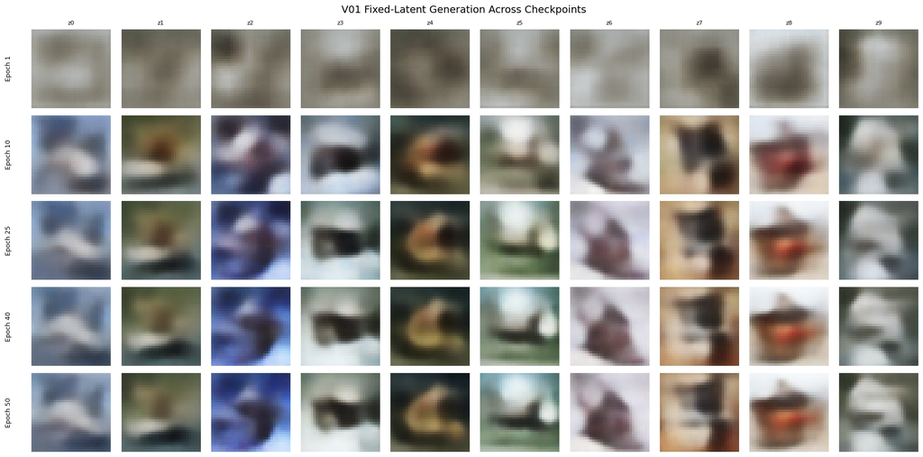

```
V01 checkpoint metrics saved to: artifacts\vae\V01\evaluation\V01_checkpoint_metrics.csv
V01 checkpoint grid saved to: artifacts\vae\V01\evaluation\V01_checkpoint_generation_grid.png
Official test-set usage: None
```

```python
# Evaluate V01 checkpoints using the fixed V00 inputs.
v01_artifact_dir = (
    Path("artifacts") / "vae" / "V01"
)
v01_evaluation_dir = (
    v01_artifact_dir / "evaluation"
)
v01_evaluation_dir.mkdir(
    parents=True,
    exist_ok=True
)

fixed_inputs_dir = (
    Path("artifacts")
    / "vae"
    / "fixed_inputs"
)
fixed_latent_path = (
    fixed_inputs_dir
    / f"fixed_latent_vectors_dim{LATENT_DIM}.npy"
)
fixed_indices_path = (
    fixed_inputs_dir
    / "fixed_reconstruction_indices.npy"
)
v01_history_path = (
    v01_artifact_dir
    / "V01_training_history.csv"
)
v01_final_vae_weights_path = (
    v01_artifact_dir
    / "weights"
    / "V01_vae_final.weights.h5"
)

for required_path in [
    fixed_latent_path,
    fixed_indices_path,
    v01_history_path,
    v01_final_vae_weights_path
]:
    assert required_path.exists(), (
        f"Required artefact not found: "
        f"{required_path}"
    )

fixed_latent_vectors = np.load(
    fixed_latent_path
)
fixed_reconstruction_indices = np.load(
    fixed_indices_path
)
fixed_reconstruction_images = x_train_vae[
    fixed_reconstruction_indices
]
fixed_reconstruction_labels = y_train[
    fixed_reconstruction_indices
]

v01_checkpoint_epochs = [
    1,
    10,
    25,
    40,
    50
]
v01_history_for_evaluation = pd.read_csv(
    v01_history_path,
    index_col="epoch"
)

v01_checkpoint_records = []
v01_checkpoint_generated = {}

for checkpoint_epoch in (
    v01_checkpoint_epochs
):
    checkpoint_path = (
        v01_artifact_dir
        / "checkpoints"
        / (
            "V01_epoch_"
            f"{checkpoint_epoch:03d}"
            ".weights.h5"
        )
    )
    assert checkpoint_path.exists(), (
        f"V01 checkpoint not found: "
        f"{checkpoint_path}"
    )

    vae_v01.load_weights(
        str(checkpoint_path)
    )

    (
        checkpoint_z_mean,
        _,
        _
    ) = encoder_v01.predict(
        fixed_reconstruction_images,
        verbose=0
    )
    checkpoint_reconstructions = (
        decoder_v01.predict(
            checkpoint_z_mean,
            verbose=0
        )
    )
    checkpoint_reconstructions = np.clip(
        checkpoint_reconstructions,
        0.0,
        1.0
    )

    mse_per_image = np.mean(
        np.square(
            fixed_reconstruction_images
            - checkpoint_reconstructions
        ),
        axis=(1, 2, 3)
    )
    mae_per_image = np.mean(
        np.abs(
            fixed_reconstruction_images
            - checkpoint_reconstructions
        ),
        axis=(1, 2, 3)
    )
    psnr_per_image = tf.image.psnr(
        fixed_reconstruction_images,
        checkpoint_reconstructions,
        max_val=1.0
    ).numpy()

    fixed_generation = (
        decoder_v01.predict(
            fixed_latent_vectors[:10],
            verbose=0
        )
    )
    v01_checkpoint_generated[
        checkpoint_epoch
    ] = np.clip(
        fixed_generation,
        0.0,
        1.0
    )

    v01_checkpoint_records.append({
        "epoch": checkpoint_epoch,
        "training_reconstruction_loss": (
            v01_history_for_evaluation.loc[
                checkpoint_epoch,
                "reconstruction_loss"
            ]
        ),
        "unweighted_kl_loss": (
            v01_history_for_evaluation.loc[
                checkpoint_epoch,
                "kl_loss"
            ]
        ),
        "reconstruction_mse": (
            mse_per_image.mean()
        ),
        "reconstruction_mae": (
            mae_per_image.mean()
        ),
        "reconstruction_psnr_db": (
            psnr_per_image.mean()
        )
    })

vae_v01.load_weights(
    str(v01_final_vae_weights_path)
)

v01_checkpoint_metrics_df = (
    pd.DataFrame(
        v01_checkpoint_records
    ).set_index("epoch")
)

v01_checkpoint_metrics_path = (
    v01_evaluation_dir
    / "V01_checkpoint_metrics.csv"
)
v01_checkpoint_metrics_df.to_csv(
    v01_checkpoint_metrics_path
)

print(
    "V01 fixed-input checkpoint metrics:"
)
display(
    v01_checkpoint_metrics_df.round(5)
)

fig, axes = plt.subplots(
    nrows=len(v01_checkpoint_epochs),
    ncols=10,
    figsize=(18, 9)
)

for row_index, checkpoint_epoch in enumerate(
    v01_checkpoint_epochs
):
    checkpoint_images = (
        v01_checkpoint_generated[
            checkpoint_epoch
        ]
    )

    for column_index in range(10):
        axes[
            row_index,
            column_index
        ].imshow(
            checkpoint_images[
                column_index
            ]
        )
        axes[
            row_index,
            column_index
        ].axis("off")

        if row_index == 0:
            axes[
                row_index,
                column_index
            ].set_title(
                f"z{column_index}",
                fontsize=8
            )

    axes[row_index, 0].text(
        -0.25,
        0.5,
        f"Epoch {checkpoint_epoch}",
        transform=axes[
            row_index,
            0
        ].transAxes,
        rotation=90,
        va="center",
        ha="right",
        fontsize=9
    )

fig.suptitle(
    "V01 Fixed-Latent Generation Across Checkpoints",
    fontsize=14
)
plt.tight_layout()

v01_checkpoint_grid_path = (
    v01_evaluation_dir
    / "V01_checkpoint_generation_grid.png"
)
plt.savefig(
    v01_checkpoint_grid_path,
    dpi=150,
    bbox_inches="tight"
)
plt.show()

print(
    "V01 checkpoint metrics saved to: "
    f"{v01_checkpoint_metrics_path}"
)
print(
    "V01 checkpoint grid saved to: "
    f"{v01_checkpoint_grid_path}"
)
print(
    "Official test-set usage: None"
)
```

### 6.6 Final Controlled Comparison - V00 versus V01

Both final models are reloaded and evaluated on identical inputs. The comparison includes:

- overall and per-class deterministic reconstruction metrics;
- a six-row original/V00/V01 reconstruction grid;
- identical 100-vector unconditional generation;
- a paired fixed-latent grid and full V01 grid;
- shared descriptor and diversity comparisons; and
- latent posterior diagnostics on the same stratified 1,000-image training reference.

The decision will consider the complete trade-off. A lower reconstruction MSE is not enough if V01’s standard-normal samples become less coherent, less diverse, or further from the training descriptors.

```python
# -------------------------------------------------------
# 1. Reload both final models and fixed evaluation inputs
# -------------------------------------------------------
v00_artifact_dir = (
    Path("artifacts") / "vae" / "V00"
)
v00_final_weights_path = (
    v00_artifact_dir
    / "weights"
    / "V00_vae_final.weights.h5"
)
v01_final_weights_path = (
    v01_artifact_dir
    / "weights"
    / "V01_vae_final.weights.h5"
)

assert v00_final_weights_path.exists()
assert v01_final_weights_path.exists()

vae_v00.load_weights(
    str(v00_final_weights_path)
)
vae_v01.load_weights(
    str(v01_final_weights_path)
)

# -------------------------------------------------------
# 2. Deterministic reconstruction comparison
# -------------------------------------------------------
(
    v00_z_mean_fixed,
    _,
    _
) = encoder.predict(
    fixed_reconstruction_images,
    verbose=0
)
(
    v01_z_mean_fixed,
    _,
    _
) = encoder_v01.predict(
    fixed_reconstruction_images,
    verbose=0
)

v00_reconstructions = np.clip(
    decoder.predict(
        v00_z_mean_fixed,
        verbose=0
    ),
    0.0,
    1.0
)
v01_reconstructions = np.clip(
    decoder_v01.predict(
        v01_z_mean_fixed,
        verbose=0
    ),
    0.0,
    1.0
)


def reconstruction_metric_arrays(
    originals,
    reconstructions
):
    mse_values = np.mean(
        np.square(
            originals
            - reconstructions
        ),
        axis=(1, 2, 3)
    )
    mae_values = np.mean(
        np.abs(
            originals
            - reconstructions
        ),
        axis=(1, 2, 3)
    )
    psnr_values = tf.image.psnr(
        originals,
        reconstructions,
        max_val=1.0
    ).numpy()

    return (
        mse_values,
        mae_values,
        psnr_values
    )


(
    v00_mse,
    v00_mae,
    v00_psnr
) = reconstruction_metric_arrays(
    fixed_reconstruction_images,
    v00_reconstructions
)
(
    v01_mse,
    v01_mae,
    v01_psnr
) = reconstruction_metric_arrays(
    fixed_reconstruction_images,
    v01_reconstructions
)

overall_reconstruction_comparison = (
    pd.DataFrame(
        {
            "V00_beta_1.0": [
                v00_mse.mean(),
                v00_mae.mean(),
                v00_psnr.mean()
            ],
            "V01_beta_0.5": [
                v01_mse.mean(),
                v01_mae.mean(),
                v01_psnr.mean()
            ]
        },
        index=[
            "mse_lower_is_better",
            "mae_lower_is_better",
            "psnr_db_higher_is_better"
        ]
    )
)
overall_reconstruction_comparison[
    "V01_minus_V00"
] = (
    overall_reconstruction_comparison[
        "V01_beta_0.5"
    ]
    - overall_reconstruction_comparison[
        "V00_beta_1.0"
    ]
)

print(
    "Overall fixed-sample reconstruction "
    "comparison:"
)
display(
    overall_reconstruction_comparison.round(
        6
    )
)

per_class_records = []

for class_id, class_name in enumerate(
    class_names
):
    class_mask = (
        fixed_reconstruction_labels
        == class_id
    )

    per_class_records.append({
        "class_name": class_name,
        "V00_mse": (
            v00_mse[class_mask].mean()
        ),
        "V01_mse": (
            v01_mse[class_mask].mean()
        ),
        "mse_change_V01_minus_V00": (
            v01_mse[class_mask].mean()
            - v00_mse[class_mask].mean()
        ),
        "V00_psnr_db": (
            v00_psnr[class_mask].mean()
        ),
        "V01_psnr_db": (
            v01_psnr[class_mask].mean()
        ),
        "psnr_change_V01_minus_V00": (
            v01_psnr[class_mask].mean()
            - v00_psnr[class_mask].mean()
        )
    })

per_class_comparison_df = pd.DataFrame(
    per_class_records
).set_index("class_name")

print(
    "\nPer-class fixed-sample comparison "
    "(two images per class):"
)
display(
    per_class_comparison_df.round(6)
)

comparison_metrics_path = (
    v01_evaluation_dir
    / "V00_V01_reconstruction_comparison.csv"
)
per_class_comparison_df.to_csv(
    comparison_metrics_path
)

fig, axes = plt.subplots(
    nrows=6,
    ncols=len(class_names),
    figsize=(18, 11)
)

row_labels = [
    "Original 1",
    "V00 1",
    "V01 1",
    "Original 2",
    "V00 2",
    "V01 2"
]

for class_id, class_name in enumerate(
    class_names
):
    first_position = class_id * 2
    second_position = (
        first_position + 1
    )

    image_sequence = [
        fixed_reconstruction_images[
            first_position
        ],
        v00_reconstructions[
            first_position
        ],
        v01_reconstructions[
            first_position
        ],
        fixed_reconstruction_images[
            second_position
        ],
        v00_reconstructions[
            second_position
        ],
        v01_reconstructions[
            second_position
        ]
    ]

    for row_index, image_value in enumerate(
        image_sequence
    ):
        axes[
            row_index,
            class_id
        ].imshow(image_value)
        axes[
            row_index,
            class_id
        ].axis("off")

        if class_id == 0:
            axes[
                row_index,
                class_id
            ].text(
                -0.2,
                0.5,
                row_labels[row_index],
                transform=axes[
                    row_index,
                    class_id
                ].transAxes,
                rotation=90,
                va="center",
                ha="right",
                fontsize=9
            )

    axes[0, class_id].set_title(
        class_name,
        fontsize=9
    )

fig.suptitle(
    "Fixed Reconstructions: V00 versus V01",
    fontsize=14
)
plt.tight_layout()

reconstruction_comparison_grid_path = (
    v01_evaluation_dir
    / "V00_V01_reconstruction_grid.png"
)
plt.savefig(
    reconstruction_comparison_grid_path,
    dpi=150,
    bbox_inches="tight"
)
plt.show()

# -------------------------------------------------------
# 3. Same-latent generation and descriptor comparison
# -------------------------------------------------------
v00_generated_float = np.clip(
    decoder.predict(
        fixed_latent_vectors,
        verbose=0
    ),
    0.0,
    1.0
)
v01_generated_float = np.clip(
    decoder_v01.predict(
        fixed_latent_vectors,
        verbose=0
    ),
    0.0,
    1.0
)
```

[output not shown]